# Ch. 5 Vorticity Dynamics — fluidpy

**Check it.** Units: (1/s)(m)/m³ · m³ = m/s ✓. A straight uniform filament gives Γ/2πr (D13) ✓. The Gaussian (Lamb–Oseen) planar vortex is recovered by `biot_savart_2d` (the code cell after the tiny example below: to ~10⁻⁸ m/s outside the core, 5×10⁻⁴ m/s inside on a 5 mm grid) ✓. (5.15), $\int_{V'}\nabla'\times\Big(\frac{\boldsymbol\omega}{\lvert\mathbf x-\mathbf x'\rvert}\Big)d^3x'=\int_{A'}\frac{\mathbf n\times\boldsymbol\omega}{\lvert\mathbf x-\mathbf x'\rvert}d^2x'$ on a polynomial field: volume = surface to 1e-12 (the cell after note N27) ✓. **sympy check (the cell right after this derivation, every line commented):** re-run steps 2, 4 and 5 symbolically: (a) the product-rule identity ∇′×(φω) − φ∇′×ω − ∇′φ×ω = 0 for generic φ(x′) and ω(x′); (b) ∇′(1/|x − x′|) − (x − x′)/|x − x′|³ = 0; (c) −∇′φ × ω − ω × (x − x′)/|x − x′|³ = 0 (the correct step 5) while the book's "+(x − x′)/r³ × ω" differs by 2ω×(x − x′)/r³.

```python
xs = sp.symbols('x y z', real=True); xp = sp.symbols('xp yp zp', real=True)   # field point x and source point x′
d = sp.Matrix(xs) - sp.Matrix(xp); r = sp.sqrt(d.dot(d))             # x − x′ and its length
W = sp.Matrix([sp.Function(f'w{i}')(*xp) for i in range(3)])        # a generic vorticity field ω(x′)
phi = 1/r                                                            # step 1: the kernel φ(x′) = 1/|x − x′|
curlp = lambda A: sp.Matrix([sp.diff(A[2], xp[1]) - sp.diff(A[1], xp[2]), sp.diff(A[0], xp[2]) - sp.diff(A[2], xp[0]), sp.diff(A[1], xp[0]) - sp.diff(A[0], xp[1])])   # ∇′×
gradp = sp.Matrix([sp.diff(phi, v) for v in xp])                     # ∇′φ
print("step 2, ∇′×(φω) − φ∇′×ω − ∇′φ×ω:", sp.simplify(curlp(phi*W) - phi*curlp(W) - gradp.cross(W)).T)   # zero vector
print("step 4, ∇′(1/r) − (x − x′)/r³:  ", sp.simplify(gradp - d/r**3).T)                                  # zero vector
print("step 5, −∇′φ×ω − ω×(x − x′)/r³: ", sp.simplify(-gradp.cross(W) - W.cross(d)/r**3).T)                # zero vector
book = (d/r**3).cross(W)                                             # the book's printed "+((x − x′)/r³) × ω"
print("book's term − correct term − 2(x − x′)×ω/r³:", sp.simplify(book - (-gradp.cross(W)) - 2*d.cross(W)/r**3).T)   # zero: the book's term is off by 2(x − x′)×ω/r³
```

```
step 2, ∇′×(φω) − φ∇′×ω − ∇′φ×ω: Matrix([[0, 0, 0]])
step 4, ∇′(1/r) − (x − x′)/r³:   Matrix([[0, 0, 0]])
```

```
step 5, −∇′φ×ω − ω×(x − x′)/r³:  Matrix([[0, 0, 0]])
book's term − correct term − 2(x − x′)×ω/r³: Matrix([[0, 0, 0]])
```

> ⚠️ **Common confusion (traps in `D11`):** ∇′(1/r) with the wrong sign (differentiating with respect to x). Applying Gauss when the field point lies inside V′ (the kernel is singular there — the smoothed kernel ε handles it numerically). Copying the book's two sign slips separately.

📝 **Note.** **The rewrite of the integrand** `N26` — (D11 steps 2–5), with the correct sign. ⚠️ The book's second line prints $+\big(\frac{\mathbf x-\mathbf x'}{\lvert\mathbf x-\mathbf x'\rvert^3}\big)\times\boldsymbol\omega$; it should be minus that (= $+\boldsymbol\omega\times(\mathbf x-\mathbf x')/\lvert\mathbf x-\mathbf x'\rvert^3$). This second slip cancels the first, so (5.16), $\mathbf u(\mathbf x,t)=\frac1{4\pi}\int_{V'}\frac{\boldsymbol\omega(\mathbf x',t)\times(\mathbf x-\mathbf x')}{\lvert\mathbf x-\mathbf x'\rvert^3}d^3x'$ is right.

$$ \frac{\nabla'\times\boldsymbol\omega}{\lvert\mathbf x-\mathbf x'\rvert}=\nabla'\times\Big(\frac{\boldsymbol\omega}{\lvert\mathbf x-\mathbf x'\rvert}\Big)+\boldsymbol\omega\times\frac{\mathbf x-\mathbf x'}{\lvert\mathbf x-\mathbf x'\rvert^3} $$

📝 **Note.** **Gauss' theorem in curl form** `N27` — used in D11 steps 7–9. Any smooth field F: $\int_V\nabla\times\mathbf F\,dV=\oint_A\mathbf n\times\mathbf F\,dA$ (apply $\int_V\nabla\cdot\mathbf Q\,dV=\int_A\mathbf Q\cdot\mathbf n\,dA$ *(2.30)* to each component $\varepsilon_{kij}F_j$). The cell checks it on a polynomial field.

$$ \int_{V'}\nabla'\times\Big(\frac{\boldsymbol\omega}{\lvert\mathbf x-\mathbf x'\rvert}\Big)d^3x'=\int_{A'}\frac{\mathbf n\times\boldsymbol\omega}{\lvert\mathbf x-\mathbf x'\rvert}d^2x' \qquad \text{(5.15)} $$

```python
Fpoly = lambda X, Y, Z: np.array([X*Y**2, Y*Z + X**3, Z*X**2*Y])     # a polynomial vector field
cc6 = ch05.curl_theorem_box(Fpoly, [(0, 1), (0, 2), (-1, 1)], n=6)   # ∫∇×F dV vs ∮n×F dA on a box (6³ Gauss nodes)
print("volume:", cc6.volume.round(10), " surface:", cc6.surface.round(10), f" largest difference {np.max(np.abs(cc6.diff)):.1e}")   # equal to ~1e-13
```

```
volume: [-4.  0.  0.]  surface: [-4.  0. -0.]  largest difference 3.7e-13
```

📝 **Note.** **Why the surface term vanishes** `N28` — (Fig. 5.8): V′ is a piece of tube with flat ends perpendicular to ω (n × ω = 0 there) and a side wall outside the vortex (ω = 0 there). The cell below takes a box round a piece of our Gaussian tube (sides 4 core radii out, ends cutting ω at right angles) and compares the surface term of (5.15), $\int_{V'}\nabla'\times\Big(\frac{\boldsymbol\omega}{\lvert\mathbf x-\mathbf x'\rvert}\Big)d^3x'=\int_{A'}\frac{\mathbf n\times\boldsymbol\omega}{\lvert\mathbf x-\mathbf x'\rvert}d^2x'$ with the Biot–Savart integral over the same box.

```python
kern = lambda X, Y, Z: F["omega"](np.array([X, Y, Z]), 0.0)/np.sqrt((X - 0.5)**2 + Y**2 + Z**2)   # ω/|x − x′| with x = (0.5, 0, 0)
cc = ch05.curl_theorem_box(kern, [(-0.4, 0.4), (-0.4, 0.4), (-0.5, 0.5)], n=24)   # the two sides of (5.15), 24³ Gauss nodes
print("surface term (5.15):", [f"{v:+.2e}" for v in cc.surface], " volume term:", [f"{v:+.2e}" for v in cc.volume])   # tiny: ~2e-6 in y
nb_, wb_ = ch05.cylinder_quadrature(0.4, -0.5, 0.5, nr=24, nphi=32, nz=24)   # the same piece of tube as a cylinder of radius 4σ_c
print("4π × Biot–Savart velocity from that piece:", [f"{v:+.4f}" for v in 4*np.pi*ch05.biot_savart_volume(F["omega"], np.array([0.5, 0, 0]), nb_, wb_)])   # ~2.85 in y
```

```
surface term (5.15): ['+0.00e+00', '-2.06e-06', '+0.00e+00']  volume term: ['-2.52e-15', '-2.06e-06', '+0.00e+00']
```

```
4π × Biot–Savart velocity from that piece: ['+0.0000', '+2.8495', '+0.0000']
```

**What does the code above do?**

The surface integral of (5.15), $\int_{V'}\nabla'\times\Big(\frac{\boldsymbol\omega}{\lvert\mathbf x-\mathbf x'\rvert}\Big)d^3x'=\int_{A'}\frac{\mathbf n\times\boldsymbol\omega}{\lvert\mathbf x-\mathbf x'\rvert}d^2x'$ over the box is about 2×10⁻⁶ (from the side walls, where the Gaussian vorticity has fallen to e⁻¹⁶ of its peak), against about 2.85 for the Biot–Savart integral of the same piece: dropping the surface term, as D11 steps 10–11 do, costs nothing.

📝 **Note.** **Fig. 5.8 analogue** `N52` — one element of a curved filament, the vector from it to the field point, and its push (below).

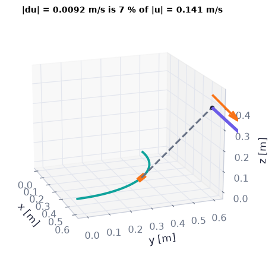

```python
phq = np.linspace(0, np.pi/2, 25)                                    # a quarter ring of radius 0.5 m in z = 0
poly = np.array([0.5*np.cos(phq), 0.5*np.sin(phq), 0*phq])           # the filament as a polyline (3, 25) [m]
fig = plt.figure(figsize=(6.2, 4.6)); fig.set_layout_engine("none")  # 3-D axes do not mix with constrained layout
ax = fig.add_subplot(projection="3d")                                # matplotlib 3-D axes (rotatable in a live kernel)
xf = np.array([0.6, 0.6, 0.4])                                       # the field point [m]
contrib = ch05.filament_contributions(xf, poly, 1.0, closed=False)    # (5.17) for each of the 24 segments, (3, 24) [m/s]
k = contrib.shape[1]//2; du_k, u_tot = contrib[:, k], contrib.sum(axis=1)   # the middle element's push and the total
ax.plot(*poly, color=COLORS["teal"], lw=2.5)                          # the filament
ax.plot(*poly[:, k:k + 2], color=COLORS["orange"], lw=6)              # the chosen element, thick orange
mid = 0.5*(poly[:, k] + poly[:, k + 1])                               # its midpoint x′
ax.plot(*np.c_[mid, xf], ls="--", color=COLORS["muted"])              # the vector x − x′
sc_ = 0.5/np.linalg.norm(u_tot)                                       # ONE scale for both arrows [m per m/s]
ax.quiver(*(xf + np.array([0, 0, 0.06])), *(du_k*sc_*5), color=COLORS["orange"], lw=2.5)   # the element's du, ×5 so it can be seen, drawn 6 cm above x (orange)
ax.quiver(*xf, *(u_tot*sc_), color=COLORS["accent"], lw=3.5)          # the total u, from x itself (purple)
ax.view_init(elev=18, azim=-20)                                       # a view in which both arrows are seen side-on
ax.scatter(*xf, color=COLORS["ink"], s=15)                            # the field point
ax.set_title(f"|du| = {np.linalg.norm(du_k):.4f} m/s is {100*np.linalg.norm(du_k)/np.linalg.norm(u_tot):.0f} % of |u| = {np.linalg.norm(u_tot):.3f} m/s", fontsize=9)
ax.set_xlabel("x [m]"); ax.set_ylabel("y [m]"); ax.set_zlabel("z [m]")   # axis labels with units
savefig(fig, "ch05", "biot_savart_geometry"); plt.show()             # save the PNG to outputs/ch05, then draw
```

**What you see.** A teal quarter circle (the filament, Γ = 1 m²/s), a black field point above it, a grey dashed line from the middle element (thick orange) to the point, a purple arrow (the sum of all the elements' pushes) and an orange arrow just above it (the middle element's push, drawn five times longer than its true share, which the title gives).

**How to read it.** Each element pushes perpendicular to itself and to the line joining it to x, with strength ∝ 1/distance² — $\mathbf u=\frac1{4\pi}\int\frac{\boldsymbol\omega\times(\mathbf x-\mathbf x')}{\lvert\mathbf x-\mathbf x'\rvert^3}d^3x'$ (5.16); the purple arrow is their vector sum; the orange push points almost the same way because every element of this quarter ring sees the point from a similar side. (In D11 the volume V′ is a thin tube hugging such a filament.)

**What would change if…** …the field point moved onto the axis of a full ring: all the pushes would line up along the axis.

#### ✏️ Tiny example: a vortex's velocity from its vorticity, by hand

A Gaussian vortex with Γ = 1 m²/s and core σ_c = 0.1 m ($\omega_z=(\Gamma/\pi\sigma_c^2)e^{-r^2/\sigma_c^2}$, peak 31.8 s⁻¹).

1. Outside the core, r = 0.5 m, nearly all the vorticity is inside: the planar Biot–Savart sum must give $\Gamma(1-e^{-25})/(2\pi\times0.5)$ = 0.3183 m/s.
2. At the core edge r = 0.1 m: $\Gamma(1-e^{-1})/(2\pi\times0.1)$ = 0.6321/0.6283 = 1.006 m/s.
3. Inside, r = 0.05 m: $\Gamma(1-e^{-0.25})/(2\pi\times0.05)$ = 0.2212/0.3142 = 0.704 m/s.

The vorticity *outside* a circle adds nothing there — the planar version of Newton's shell theorem.

```python
xg = np.linspace(-0.5, 0.5, 201); XG, YG = np.meshgrid(xg, xg)       # a 201 × 201 grid, spacing 5 mm [m]
wz = vortices.gaussian_vortex(np.hypot(XG, YG), 1.0, 0.1)[1]         # ω_z of the Gaussian vortex on the grid [1/s]
for r in (0.05, 0.1, 0.5):                                           # three radii [m]
    ub = ch05.biot_savart_2d(wz, XG, YG, np.array([r, 0.0]), eps=1e-4)[1]   # planar Biot–Savart: Σ ω dA e_z×r/(2π|r|²) [m/s]
    ue = vortices.gaussian_vortex(r, 1.0, 0.1)[0]                    # the exact profile (3.29) [m/s]
    print(f"r = {r:.2f} m: grid sum {ub:.6f}, exact {ue:.6f}, difference {ub - ue:+.1e} m/s")
```

```
r = 0.05 m: grid sum 0.703602, exact 0.704099, difference -5.0e-04 m/s
r = 0.10 m: grid sum 1.005581, exact 1.006051, difference -4.7e-04 m/s
r = 0.50 m: grid sum 0.318310, exact 0.318310, difference -1.4e-08 m/s
```

**What does the code above do?**

1. The vorticity sampled on a 201 × 201 grid.
2. The planar Biot–Savart sum (kernel $\mathbf e_z\times\mathbf r/2\pi\lvert\mathbf r\rvert^2$, the 2-D form of (5.16), $\mathbf u(\mathbf x,t)=\frac1{4\pi}\int_{V'}\frac{\boldsymbol\omega(\mathbf x',t)\times(\mathbf x-\mathbf x')}{\lvert\mathbf x-\mathbf x'\rvert^3}d^3x'$) at three radii.
3. Agreement with the exact profile $u_\theta=\frac{\Gamma}{2\pi r}\big(1-e^{-r^2/\sigma^2}\big)$ *(3.29)*: within about 5×10⁻⁴ m/s inside the core (the kernel's 1/r singularity next to the grid nodes: 5×10⁻⁴ m/s at r = 5 and 10 cm) and ~10⁻⁸ m/s outside, where ω ≈ 0.

**From scratch — forty thousand little pushes, added by hand** (a double loop over the grid cells, `np.ndindex` walks every (row, column) index):

```python
dA = (xg[1] - xg[0])**2                                              # cell area [m²]
u = v = 0.0                                                          # velocity at the field point (0.1 m, 0) [m/s]
for j, i in np.ndindex(XG.shape):                                    # every grid cell
    dx, dy = 0.1 - XG[j, i], 0.0 - YG[j, i]                          # x − x′ [m]
    r2 = dx*dx + dy*dy + 1e-8                                        # |x − x′|² + ε² (ε = 1e-4 m) [m²]
    u += -wz[j, i]*dy/r2*dA/(2*np.pi)                                # e_z × (dx, dy) = (−dy, dx)
    v += wz[j, i]*dx/r2*dA/(2*np.pi)
print(f"ours ({u:.2e}, {v:.6f}) m/s")                                # (0, 1.005581)
assert np.allclose(v, ch05.biot_savart_2d(wz, XG, YG, np.array([0.1, 0.0]), eps=1e-4)[1], rtol=1e-6)   # = the library
```

```
ours (-6.97e-16, 1.005581) m/s
```

```python
rq = np.linspace(0.005, 0.5, 60)                                     # radii where we evaluate [m]
exact = vortices.gaussian_vortex(rq, 1.0, 0.1)[0]                    # (3.29) [m/s]


def grid(n):                                                         # grid points per side → curves
    g1 = np.linspace(-0.5, 0.5, int(n)); Xn, Yn = np.meshgrid(g1, g1)   # an n × n grid [m]
    w_ = vortices.gaussian_vortex(np.hypot(Xn, Yn), 1.0, 0.1)[1]     # vorticity on it [1/s]
    ub = ch05.biot_savart_2d(w_, Xn, Yn, np.array([rq, 0*rq]), eps=1e-4)[1]   # (5.16) summed over the grid [m/s]
    return {"Biot–Savart on the grid": (rq, ub), "exact (3.29)": (rq, exact), "printed sign −1/(4π)": (rq, -ub)}  # grid sum, exact profile, printed-sign mirror


fig = slider_figure(grid, "n", [21, 31, 41, 61, 81, 101, 121, 151, 181, 201] if not FAST else [21, 41, 61, 81, 101, 121],  # precompute every slider position
                    unit="points per side", xlabel="r [m]", ylabel="u_θ [m/s]",                     # slider label and axis labels
                    title="Biot–Savart rebuilds the vortex — with the right sign", modes={"Biot–Savart on the grid": "markers"})  # the message of the figure
recolor(fig, {"Biot–Savart on the grid": COLORS["teal"], "exact (3.29)": COLORS["ink"], "printed sign −1/(4π)": COLORS["rose"]},  # house colours by trace name
        dashes={"printed sign −1/(4π)": "dash"})                                                    # dashed reference curves
fig.show()                                                                                          # draw it (works on the web page too)
```

[interactive chart not shown]

**What you see.** Teal dots settle onto the black curve as the grid refines (the coarse grids miss the core); the dashed rose curve is its upside-down twin.

**How to read it.** (5.16), $\mathbf u(\mathbf x,t)=\frac1{4\pi}\int_{V'}\frac{\boldsymbol\omega(\mathbf x',t)\times(\mathbf x-\mathbf x')}{\lvert\mathbf x-\mathbf x'\rvert^3}d^3x'$ recovers the swirl inside and outside the core; the book's printed −1/(4π) in (5.14), $\mathbf u(\mathbf x,t)=+\frac1{4\pi}\int_{V'}\frac{\nabla'\times\boldsymbol\omega(\mathbf x',t)}{\lvert\mathbf x-\mathbf x'\rvert}d^3x'\ \ (\text{sign corrected; the book prints }-\tfrac1{4\pi})$ would spin every vortex backwards.

**What would change if…** …a Rankine vortex instead: the dots converge more slowly (its vorticity jumps at the core edge), to the kink at r = σ_c.

**What would change if…** …the vortex were thin and we stood far from it? Then the details of the core stop mattering: only its strength Γ and its path count — the filament law (C08).

### 🧩 The filament law `C08`

*The question:* A smoke ring pushes itself forward; a wing-tip vortex drags air down behind a plane. How much velocity does one short piece of a thin vortex make?

*In one line:* $d\mathbf u\cong\frac{\Gamma\,dl}{4\pi}\mathbf e_\omega\times\frac{\mathbf x-\mathbf x'}{\lvert\mathbf x-\mathbf x'\rvert^3}$ *(5.17)*

#### The problem in plain words

Real vortices are often thin compared with the distances that matter: the trailing vortices of an aircraft, a tornado seen from a kilometre away, a smoke ring. Then we can replace the tube by a line carrying a circulation Γ and add up its pieces — the lifting-line theory of wings (Ch. 14) is exactly this.

#### The idea

```
thin tube of strength Gamma, seen from far away          one piece of length dl pushes the fluid at x:
--->=======================>  (all vorticity on a line)   du = (Gamma dl / 4pi) e_w x (x - x')/|x - x'|^3        (5.17)
                                                          sum along a straight line -> Gamma/(4 pi d) (cos ta - cos tb)
                                                          infinite line -> Gamma/(2 pi d): the line vortex (5.2) again
```

*The numbered equations in the sketch:* $d\mathbf u\cong\frac{\Gamma\,dl}{4\pi}\mathbf e_\omega\times\frac{\mathbf x-\mathbf x'}{\lvert\mathbf x-\mathbf x'\rvert^3}$ *(5.17)* · $u_\theta=\frac{\Gamma}{2\pi r}$ *(5.2)*

*Glosses used below.* **Far field ("frozen kernel").** If a function barely changes across a small region, pull it out of the integral: moving across a core of radius a changes the kernel $(\mathbf x-\mathbf x')/\lvert\mathbf x-\mathbf x'\rvert^3$, whose size is $1/\lvert\mathbf x-\mathbf x'\rvert^2$, by about $2a/\lvert\mathbf x-\mathbf x'\rvert$ — 20 % at ten core radii, 2 % at a hundred. **1 + cot²θ = csc²θ** (divide sin²θ + cos²θ = 1 by sin²θ).

#### 🧮 Derivation — The filament law: (5.16) → (5.17) `D12` (Eq. 5.17)

**What we want to show.** Reduce Biot–Savart to a rule for a thin vortex tube seen from far away: the velocity made by one short piece dl of it.

**Assumptions.** Thin tube: core radius a ≪ |x − x′| (step 3); e_ω constant across the section (step 2).

**The plan.**

1. Take V′ as a short piece of a thin tube.
2. Freeze the kernel across the tube's cross-section.
3. Recognise the tube strength.

**Tools we use** (each explained before this point): Tube strength Γ = ∫ω·n dA (N03) · far-field ("frozen kernel") approximation (gloss, with a number).

**We start from**

$$ \mathbf u(\mathbf x,t)=\frac1{4\pi}\int_{V'}\frac{\boldsymbol\omega(\mathbf x',t)\times(\mathbf x-\mathbf x')}{\lvert\mathbf x-\mathbf x'\rvert^3}d^3x'\ \text{(5.16)} $$

*In words:* every bit of vorticity pushes the fluid at x.

**Step 1 of 6 — Take a short piece of thin tube.**

$$ V'=\Delta A'\,dl,\qquad d^3x'=d^2x'\,dl $$

- *Why we can do this:* A volume element of a tube is its cross-section times a length along it; we look at one piece at a time and add pieces later.
- *In words:* Slice the vortex into short discs.

**Step 2 of 6 — Split ω into size and direction.**

$$ \boldsymbol\omega=\lvert\boldsymbol\omega\rvert\,\mathbf e_\omega $$

- *Why we can do this:* In a thin tube all vortex lines are nearly parallel, so the unit vector e_ω is the same across the section.
- *In words:* The vorticity points along the tube.

**Step 3 of 6 — Freeze the kernel across the section.**

$$ \frac{\mathbf x-\mathbf x'}{\lvert\mathbf x-\mathbf x'\rvert^3}\approx\text{const over }\Delta A' $$

- *Why we can do this:* Far field (gloss): moving x′ across a core of radius a changes the kernel's size 1/|x − x′|² by about 2a/|x − x′| — 20 % at 10 core radii, 2 % at 100. This is the book's "sufficiently distant".
- *In words:* From far away the tube looks like a line.

**Step 4 of 6 — Pull kernel and direction out.**

$$ d\mathbf u\cong\frac{1}{4\pi}\Big[\int_{\Delta A'}\lvert\boldsymbol\omega\rvert d^2x'\Big]\mathbf e_\omega\times\frac{\mathbf x-\mathbf x'}{\lvert\mathbf x-\mathbf x'\rvert^3}dl $$

- *Why we can do this:* Constants leave the integral (linearity). ≅ marks the far-field approximation.
- *In words:* Only the total vorticity of the slice matters.

**Step 5 of 6 — Recognise the tube strength.**

$$ \int_{\Delta A'}\lvert\boldsymbol\omega\rvert d^2x'=\Gamma $$

- *Why we can do this:* The vorticity flux through a section is the tube's strength (N03, Stokes), the same everywhere along it (D01).
- *In words:* The bracket is Γ.

**Step 6 of 6 — Write the filament law.**

$$ d\mathbf u=\frac{\Gamma\,dl}{4\pi}\,\mathbf e_\omega\times\frac{\mathbf x-\mathbf x'}{\lvert\mathbf x-\mathbf x'\rvert^3} $$

- *Why we can do this:* Substitute step 5 into step 4. This is (5.17), $d\mathbf u\cong\frac{\Gamma\,dl}{4\pi}\mathbf e_\omega\times\frac{\mathbf x-\mathbf x'}{\lvert\mathbf x-\mathbf x'\rvert^3}$ — the line above.
- *In words:* Each piece of filament pushes perpendicular to itself and to the line to x, as Γ dl/distance².

**Result**

$$ d\mathbf u(\mathbf x,t)\cong\frac{\Gamma\,dl}{4\pi}\mathbf e_\omega\times\frac{\mathbf x-\mathbf x'}{\lvert\mathbf x-\mathbf x'\rvert^3} $$

*In words:* the Biot–Savart law for a thin filament of strength Γ.

**What it means.** The tool for rings (C13), horseshoe vortices and induced drag (Ch. 14). On the filament itself the sum diverges logarithmically: a curved filament needs a finite core to move itself (the ring self-speed, N42).

**Check it.** Units: (m²/s · m)/m² = m/s ✓. Summed round a ring (the code cell after the tiny example of this block) of radius R at its centre: ΓR·2π/(4πR²) = Γ/2R ✓ (`ring_axis_velocity(0, 0.5, 1)` = 1.0 m/s). A polygon of M segments converges to it with error ∝ 1/M² (1.0548, 1.0131, 1.0008 for M = 8, 16, 64) ✓.

> ⚠️ **Common confusion (traps in `D12`):** Using (5.17), $d\mathbf u\cong\frac{\Gamma\,dl}{4\pi}\mathbf e_\omega\times\frac{\mathbf x-\mathbf x'}{\lvert\mathbf x-\mathbf x'\rvert^3}$ at points within a few core radii. Forgetting that dl runs along e_ω (the sense of Γ).

> 📎 **Primer — improper integral as a limit.** `P144` · An integral to infinity means: integrate to a finite end, then let the end run away. $\int_0^\infty e^{-x}dx$ is the limit of $1-e^{-b}$ as b → ∞, i.e. 1. D13 lets a straight segment grow into an infinite line this way.

```python
from scipy.integrate import quad                            # adaptive quadrature (Ch. 3 P87)
f = lambda l: 1.0/(1.0 + l**2)**1.5                         # d = 1 m: the segment integrand of D13 step 4
for b in (1, 10, 100):                                      # longer and longer segments [m]
    print(b, quad(f, -b, b)[0])                             # → 2 as b → ∞ (so Γ·2/(4π) = Γ/2π)
print(quad(f, -np.inf, np.inf)[0])                          # scipy does the limit for you: 2.0
```

```
1 1.4142135623730951
10 1.9900743804199783
100 1.9999000074993758
2.0
```

> 🔁 **Tools from earlier chapters used here** (see `knowledge/primers.md`) — needed in the derivation below
- **substitution in an integral** — replace the variable l by a function of a new one, l = l(θ), and dl by l′(θ)dθ (Ch. 3 P106).

#### 🧮 Derivation — A straight segment gives (Γ/4πd)(cos θ_a − cos θ_b); an infinite line gives Γ/2πd `D13` (Eq. 5.2)

**What we want to show.** Integrate the filament law along a straight segment in closed form, and close the loop the book leaves open: an infinite straight filament must give back the line vortex $u_\theta=\Gamma/2\pi r$ (5.2), $u_\theta=\frac{\Gamma}{2\pi r}$.

**Assumptions.** Straight filament along e_z (steps 1–2); thin far-field form (5.17), $d\mathbf u\cong\frac{\Gamma\,dl}{4\pi}\mathbf e_\omega\times\frac{\mathbf x-\mathbf x'}{\lvert\mathbf x-\mathbf x'\rvert^3}$ (all steps).

**The plan.**

1. Place the segment on an axis and name the geometry.
2. Show every element pushes the same way.
3. Substitute an angle.
4. Integrate and take limits.

**Tools we use** (each explained before this point): Substitution in an integral (ch03 P106, reminder) · 1 + cot²θ = csc²θ (gloss) · improper integral as a limit (primer in C08) · right-hand rule (ch02 P74, reminder).

**We start from**

$$ d\mathbf u=\frac{\Gamma\,dl}{4\pi}\mathbf e_\omega\times\frac{\mathbf x-\mathbf x'}{\lvert\mathbf x-\mathbf x'\rvert^3}\ \text{(5.17)} $$

*In words:* each piece pushes as Γ dl/distance².

**Step 1 of 8 — Place the filament on the z-axis.**

$$ \mathbf x-\mathbf x'=d\,\mathbf e_d-l\,\mathbf e_z $$

- *Why we can do this:* e_ω = e_z; the field point is at distance d from the axis in direction e_d; l is the element's position along the axis measured from the foot of the perpendicular.
- *In words:* The point sits a distance d from the line.

**Step 2 of 8 — Compute the cross product.**

$$ \mathbf e_z\times(d\,\mathbf e_d-l\,\mathbf e_z)=d\,\mathbf e_\varphi $$

- *Why we can do this:* e_z × e_z = 0 and e_z × e_d = e_φ (right-hand rule). Every element pushes along the same e_φ, so we can add magnitudes.
- *In words:* All pieces push the same way round the line.

**Step 3 of 8 — Write the distance.**

$$ \lvert\mathbf x-\mathbf x'\rvert^2=d^2+l^2 $$

- *Why we can do this:* Pythagoras, because the two pieces d e_d and −l e_z of step 1 are perpendicular (e_d ⟂ e_z).
- *In words:* Near elements are close, far ones far.

**Step 4 of 8 — Collect the scalar integral.**

$$ u_\varphi=\frac{\Gamma d}{4\pi}\int_{l_a}^{l_b}\frac{dl}{(d^2+l^2)^{3/2}} $$

- *Why we can do this:* Steps 2–3 in (5.17), $d\mathbf u\cong\frac{\Gamma\,dl}{4\pi}\mathbf e_\omega\times\frac{\mathbf x-\mathbf x'}{\lvert\mathbf x-\mathbf x'\rvert^3}$; sum from the segment's start l_a to its end l_b.
- *In words:* The speed is a sum of 1/distance³-weighted pieces.

**Step 5 of 8 — Substitute an angle.**

$$ l=-d\cot\theta,\qquad dl=d\,\csc^2\theta\,d\theta $$

- *Why we can do this:* θ is the angle at the element between e_ω and the line to x (cos θ = −l/√(d² + l²)); substitution (P106) turns the power into a trig function.
- *In words:* Measure each element by the angle at which it sees the point.

**Step 6 of 8 — Simplify with 1 + cot² = csc².**

$$ \frac{d\,dl}{(d^2+l^2)^{3/2}}=\frac{d\cdot d\csc^2\theta\,d\theta}{d^3\csc^3\theta}=\frac{\sin\theta\,d\theta}{d} $$

- *Why we can do this:* d² + l² = d²(1 + cot²θ) = d²csc²θ (gloss).
- *In words:* Each angular slice contributes sin θ dθ/d.

**Step 7 of 8 — Integrate between the end angles.**

$$ u_\varphi=\frac{\Gamma}{4\pi d}\int_{\theta_a}^{\theta_b}\sin\theta\,d\theta=\frac{\Gamma}{4\pi d}(\cos\theta_a-\cos\theta_b) $$

- *Why we can do this:* The antiderivative of sin θ is −cos θ. θ_a, θ_b are the angles at the two ends.
- *In words:* A finite segment's push depends only on the angles its ends subtend.

**Step 8 of 8 — Let the segment become infinite.**

$$ \theta_a\to0,\ \theta_b\to\pi:\ \ u_\varphi=\frac{\Gamma}{4\pi d}\big(1-(-1)\big)=\frac{\Gamma}{2\pi d} $$

- *Why we can do this:* The improper integral is the limit of finite ones (primer). This is (5.2), $u_\theta=\frac{\Gamma}{2\pi r}$ — the line above, $u_\theta=\Gamma/2\pi r$ — the book never closes this loop. A semi-infinite line (θ_b = π/2) gives half.
- *In words:* An endless straight filament is the line vortex.

**Result**

$$ u_\varphi=\frac{\Gamma}{4\pi d}(\cos\theta_a-\cos\theta_b);\qquad\text{infinite line: }u_\varphi=\frac{\Gamma}{2\pi d}\ \text{— the line vortex (5.2)} $$

*In words:* summing the filament law along a straight line gives back the ideal line vortex.

**What it means.** The law behind horseshoe vortices and downwash (Ch. 14): the velocity from a finite piece of a vortex is known exactly. Consistency with (5.2), $u_\theta=\frac{\Gamma}{2\pi r}$ confirms the + sign of (5.16), $\mathbf u(\mathbf x,t)=\frac1{4\pi}\int_{V'}\frac{\boldsymbol\omega(\mathbf x',t)\times(\mathbf x-\mathbf x')}{\lvert\mathbf x-\mathbf x'\rvert^3}d^3x'$.

**Check it.** Units m/s ✓. Γ = 1 m²/s, d = 1 m: infinite 0.159155, semi-infinite 0.079577 m/s (both printed in the code cell after the tiny example below); `quad` of the step-4 integral agrees with the closed form (the code cell after the tiny example below) ✓. Square loop of side 1 m at its centre: four segments, each seen at θ_a = 45°, θ_b = 135° from d = 0.5 m: 4 × Γ/(4π × 0.5) × (√2/2 + √2/2) = 2√2Γ/πL = 0.9003 m/s ✓.

> ⚠️ **Common confusion (traps in `D13`):** Measuring θ at the field point instead of at the element (then the signs of the cosines flip). Forgetting that the direction is set by e_ω × e_d.

📝 **Note.** **The loop closes** `N29` — An infinite straight filament from (5.17), $d\mathbf u\cong\frac{\Gamma\,dl}{4\pi}\mathbf e_\omega\times\frac{\mathbf x-\mathbf x'}{\lvert\mathbf x-\mathbf x'\rvert^3}$ gives back $u_\theta=\Gamma/2\pi r$ (5.2); a finite segment gives $\frac{\Gamma}{4\pi d}(\cos\theta_a-\cos\theta_b)$ — the book never writes this. **Numbers** (Γ = 1 m²/s, d = 1 m): infinite line 0.159 m/s, semi-infinite 0.080 m/s, the segment from −1 to +1 m 0.113 m/s; a square loop of side 1 m at its centre 2√2Γ/πL = 0.900 m/s; a ring of radius 0.5 m at its centre Γ/2R = 1.0 m/s, and on its axis the exact $u_z=\frac{\Gamma R^2}{2(R^2+z^2)^{3/2}}$.

#### ✏️ Tiny example: the push of a 2 m segment on a point 1 m away

Γ = 1 m²/s, segment from z = −1 m to z = +1 m, field point at x = 1 m, z = 0 (d = 1 m).

1. The ends are seen at θ_a = 45° and θ_b = 135° (cos = ±0.707).
2. $u=\frac{\Gamma}{4\pi d}(\cos\theta_a-\cos\theta_b)$ = 0.0796 × 1.414 = 0.1125 m/s.
3. Direction $\mathbf e_\omega\times\mathbf e_d=\mathbf e_z\times\mathbf e_x=\mathbf e_y$.
4. Stretch the segment to ±10 m: cosines ±0.995, u = 0.0796 × 1.990 = 0.1584 m/s — within 0.5 % of the infinite line's 0.1592 m/s.

```python
from scipy.integrate import quad                                     # for D13's step-4 integral
print(ch05.segment_induced_velocity(np.array([1.0, 0, 0]), np.array([0, 0, -1.0]), np.array([0, 0, 1.0]), 1.0))   # the example [m/s]
print(f"D13 step 4 by quad: {1.0*1.0/(4*np.pi)*quad(lambda l: 1/(1 + l**2)**1.5, -1, 1)[0]:.6f} m/s")   # Γd/4π ∫dl/(d²+l²)^{3/2}
print(f"semi-infinite line (0 to 1000 m): {ch05.segment_induced_velocity(np.array([1.0, 0, 0]), np.zeros(3), np.array([0, 0, 1000.0]), 1.0)[1]:.6f} m/s")   # Γ/4πd = 0.079577
for Lh in (1, 10, 100, 1000):                                        # half-lengths [m]
    print(Lh, round(ch05.segment_induced_velocity(np.array([1.0, 0, 0]), np.array([0, 0, -Lh]), np.array([0, 0, Lh]), 1.0)[1], 6))   # → 1/2π
print(f"square loop, side 1 m, at its centre: {ch05.filament_velocity_preset('square', 0.0, 0.0, 0.0, side=1.0, component=2):.6f} m/s")
for M in (8, 16, 64):                                                # a ring of radius 0.5 m drawn as an M-gon
    print(M, round(ch05.filament_velocity(np.zeros(3), ch05.filament_preset("ring", M=M, R=0.5), 1.0)[2], 6))   # → Γ/2R = 1
print(ch05.ring_axis_velocity(0.0, 0.5, 1.0), ch05.ring_axis_velocity(0.5, 0.5, 1.0))   # exact ring-axis formula at z = 0 and 0.5 m
```

```
[0.     0.1125 0.    ]
D13 step 4 by quad: 0.112540 m/s
semi-infinite line (0 to 1000 m): 0.079577 m/s
1 0.11254
10 0.158365
100 0.159147
1000 0.159155
square loop, side 1 m, at its centre: 0.900316 m/s
8 1.054786
16 1.013052
64 1.000804
1.0 0.35355339059327373
```

**What does the code above do?**

1. The closed form of D13 for the worked example: (0, 0.112540, 0) m/s — and `quad` of D13's step-4 integral gives the same.
2. Longer segments approach Γ/2πd = 0.159155 m/s (0.112540, 0.158365, 0.159147, 0.159155).
3. A square loop (four segments) at its centre: 0.900316 m/s = 2√2Γ/πL.
4. A ring as an M-gon at its centre: 1.054786, 1.013052, 1.000804 — the error falls as 1/M² (8 → 16 divides it by ≈ 4).
5. The exact ring-axis formula $\Gamma R^2/2(R^2+z^2)^{3/2}$: 1.0 m/s at the centre, 0.353553 m/s at z = 0.5 m.

**From scratch — twenty thousand pieces of (5.17), $d\mathbf u\cong\frac{\Gamma\,dl}{4\pi}\mathbf e_\omega\times\frac{\mathbf x-\mathbf x'}{\lvert\mathbf x-\mathbf x'\rvert^3}$, summed:**

```python
N = 20000                                                            # pieces of the segment
l = (np.arange(N) + 0.5)/N*2 - 1                                     # piece midpoints on [−1, 1] m
rv = np.stack([1.0 - 0*l, 0*l, -l])                                  # x − x′ for each piece [m]
du = np.cross(np.array([0, 0, 1.0]), rv.T)/np.linalg.norm(rv, axis=0)[:, None]**3*(2/N)/(4*np.pi)   # (5.17) with Γ = 1, dl = 2/N
print(du.sum(axis=0))                                                # (0, 0.112540, 0) m/s
assert np.allclose(du.sum(axis=0), ch05.segment_induced_velocity(np.array([1.0, 0, 0]), np.array([0, 0, -1.0]), np.array([0, 0, 1.0]), 1.0), rtol=1e-8, atol=1e-12)
```

```
[0.     0.1125 0.    ]
```

```python
zq = np.linspace(-1.5, 1.5, 61)                                      # points on the ring's axis [m]
exact = ch05.ring_axis_velocity(zq, 0.5, 1.0)                        # ΓR²/2(R² + z²)^{3/2} [m/s]


def ring(M):                                                         # number of segments → curves
    uz = ch05.filament_velocity(np.array([0*zq, 0*zq, zq]), ch05.filament_preset("ring", M=int(M), R=0.5), 1.0)[2]   # (5.17) summed
    return {"M-gon, (5.17) summed": (zq, uz), "exact ring": (zq, exact)}                            # polygon sum and exact ring


fig = slider_figure(ring, "M", [4, 6, 8, 12, 16, 24, 32, 48, 64, 128] if not FAST else [4, 8, 16, 32, 64, 128],  # precompute every slider position
                    unit="segments", xlabel="z on the axis [m]", ylabel="u_z [m/s]",                # slider label and axis labels
                    title="(5.17) summed round a ring (R = 0.5 m, Γ = 1 m²/s)", modes={"M-gon, (5.17) summed": "markers"})  # the message of the figure
recolor(fig, {"M-gon, (5.17) summed": COLORS["teal"], "exact ring": COLORS["ink"]})                 # house colours by trace name
fig.show()                                                                                          # draw it (works on the web page too)
```

[interactive chart not shown]

**What you see.** Teal dots above the black curve for a square (M = 4), closing onto it as M grows.

**How to read it.** A ring of vorticity pushes fluid through its middle, strongest at the centre, Γ/2R = 1 m/s; the polygon's error falls like 1/M².

**What would change if…** …the ring radius doubled: the centre speed halves (Γ/2R) and the curve widens.

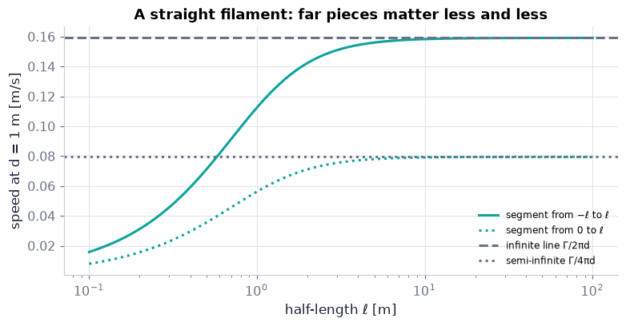

```python
ell = np.geomspace(0.1, 100, 200)                                    # half-length of the segment [m]
d = 1.0                                                              # distance of the point from the line [m]
full = np.array([ch05.segment_induced_velocity(np.array([d, 0, 0]), np.array([0, 0, -L_]), np.array([0, 0, L_]), 1.0)[1] for L_ in ell])   # segment −ℓ…ℓ
semi = np.array([ch05.segment_induced_velocity(np.array([d, 0, 0]), np.array([0, 0, 0.0]), np.array([0, 0, L_]), 1.0)[1] for L_ in ell])  # 0…ℓ
fig, ax = plt.subplots(figsize=(7, 3.6))                             # one panel
ax.semilogx(ell, full, color=COLORS["teal"], lw=2, label="segment from −ℓ to ℓ")       # climbs to the line vortex
ax.semilogx(ell, semi, color=COLORS["teal"], ls=":", lw=2, label="segment from 0 to ℓ")  # climbs to half of it
ax.axhline(1/(2*np.pi*d), color=COLORS["muted"], ls="--", label="infinite line Γ/2πd")    # the ghost
ax.axhline(1/(4*np.pi*d), color=COLORS["muted"], ls=":", label="semi-infinite Γ/4πd")
ax.set_xlabel("half-length ℓ [m]"); ax.set_ylabel("speed at d = 1 m [m/s]"); ax.legend(fontsize=8)   # axis labels with units
ax.set_title("A straight filament: far pieces matter less and less")
plt.show()
```

**What you see.** The solid teal curve climbs to the grey dashed line once ℓ ≫ d; the dotted curve (a line starting at the foot of the perpendicular) climbs to exactly half of it.

**How to read it.** Γ/4πd (cos θ_a − cos θ_b): the far pieces are seen at angles near 0 and π and add little. A semi-infinite line gives exactly half — the reason a wing's trailing vortex makes half the downwash at the wing than far behind it (Ch. 14).

**What would change if…** …d halved: the whole curve doubles and reaches the ghost at half the length.

#### 🎮 Interactive: How does a vortex push water far away?

**Why interactive rather than a static figure:** dragging a field point around straight, bent, square, ring and helical filaments while each segment's contribution and their vector sum are drawn makes the 1/distance² law and the perpendicular direction tangible.

The sign toggle shows what the book's printed form $\mathbf u=-\frac1{4\pi}\int_{V'}\frac{\nabla'\times\boldsymbol\omega}{\lvert\mathbf x-\mathbf x'\rvert}d^3x'$ would do; the Derivation tab carries the ★★★ D10 and D11.

**What to try:**

- Straight segment: lengthen it and watch the speed approach Γ/2πd.
- Ring: put the point on the axis and read Γ/2R at the centre.
- Click a segment: the inspector shows its dl, r and du.
- Flip the sign to the printed −1/(4π): every arrow reverses — the badge says why that is wrong.

```python
show_viz("ch05", "biot_savart_filament")   # full-width explainer; ⤢ Full screen for more room
```

🎮 Interactive 5/9 How does a vortex push water far away? Open alone ↗

[interactive chart not shown]

**What would change if…** …the filament were curved and we asked for the velocity *on* it? The sum diverges logarithmically near the point itself: a curved vortex moves itself only because its core has a finite size — the smoke ring's self-speed $\frac{\Gamma}{4\pi R}\big[\ln\frac{8R}{a}-\frac14\big]$ (note N42, C13).

## 5.6 Vorticity Equation in a Rotating Frame

**What is this section about?** The ocean and the atmosphere are watched from a rotating Earth and have density contrasts. Redoing the vorticity equation in a frame turning at Ω, for a nearly incompressible (Boussinesq) fluid of variable density, adds two things: the planet's own vorticity 2Ω is stretched and tilted like any other, and density gradients across pressure gradients create vorticity. Two consequences follow: stretching and tilting of vortex lines (the engine of 3-D turbulence), and the conservation of absolute circulation — the seed of potential vorticity.

> 🔁 **Recap — Hypotheses and comma notation of §5.6** (Ch. 4 §4.9 (Boussinesq), Ch. 2 §2.14). A frame rotating at constant Ω; a non-barotropic but nearly incompressible (Boussinesq) fluid, so ∇·u ≈ 0; and the comma notation of Ch. 2 §2.14: $u_{i,j}\equiv\partial u_i/\partial x_j$, $u_{i,jk}\equiv\partial^2u_i/\partial x_j\partial x_k$. Gloss: at the end of a derivation we may rename the free index (n → i); a repeated (dummy) index may be renamed at any time (Ch. 2 §2.1).

> 🔁 **Recap — Continuity** (Ch. 4 §4.2). Nearly incompressible flow: $u_{i,i}=0$ *(Eq. 5.19)* — Ch. 4's $\nabla\cdot\mathbf u=0$ *(4.10)*.

> 🔁 **Recap — Momentum in a steadily rotating frame** (Ch. 4 §4.7). $\frac{\partial u_i}{\partial t}+u_ju_{i,j}+2\varepsilon_{ijk}\Omega_ju_k=-\frac1\rho p_{,i}+g_i+\nu u_{i,jj}$ *(Eq. 5.20)* — Ch. 4's rotating-frame momentum equation (4.45), $\rho\frac{D'\mathbf u'}{Dt}=-\nabla'p+\rho\big[\mathbf g-2\boldsymbol\Omega\times\mathbf u'-\boldsymbol\Omega\times(\boldsymbol\Omega\times\mathbf x')-\dots\big]+\mu\nabla'^2\mathbf u'$ with Ω constant; g is the effective gravity (true gravity plus the centrifugal term). Ch. 4's explainer `rotating_frame_coriolis` shows the frame.

```python
u_rest = lambda x, t: np.zeros_like(np.asarray(x, float))            # fluid at rest in a frame turning at 0.5 rad/s [m/s]
p_h = lambda x, t: 1e5 - 1000*9.81*np.asarray(x)[2]                  # hydrostatic pressure with effective gravity [Pa]
print(ch05.rotating_ns_residual(u_rest, p_h, 1000.0, np.array([0.3, 0.1, -0.2]), Omega=(0, 0, 0.5)))   # ≈ 0: a solution of (5.20)
```

```
[0. 0. 0.]
```

> 🔁 **Recap — The Lamb identity in index form** (Ch. 4 §4.9). $u_ju_{i,j}=-(\mathbf u\times\boldsymbol\omega)_i+\tfrac12(u_j^2)_{,i}$ *(Eq. 5.21)* — the index form of (4.68), $u_i\frac{\partial u_j}{\partial x_i}=-(\mathbf u\times\boldsymbol\omega)_j+\frac{\partial}{\partial x_j}\big(\tfrac12u_i^2\big)$, recapped as R11.

> 🔁 **Tools from earlier chapters used here** (see `knowledge/primers.md`)
- **np.random.default_rng** — `np.random.default_rng(seed).normal(size=…)` draws reproducible random numbers (Ch. 1 P10).
- **np.einsum index strings** — `np.einsum('ijk,k->ij', E, w)` sums over the repeated index k exactly as the index notation says (Ch. 2 P62).

> 🔁 **Recap — The antisymmetric gradient is the vorticity** (Ch. 3 §3.4). $\varepsilon_{ijk}\omega_k=u_{j,i}-u_{i,j}$ *(Eq. 5.22)* — Ch. 3's rotation tensor $R_{ij}=-\varepsilon_{ijk}\omega_k$ *(3.15)*, from the ε–δ identity (2.19), $\varepsilon_{ijk}\varepsilon_{klm}=\delta_{il}\delta_{jm}-\delta_{im}\delta_{jl}$.

```python
G = np.random.default_rng(5).normal(size=(3, 3))                     # a random velocity gradient, G[i, j] = u_{i,j} [1/s]
w = kinematics.vorticity_from_gradient(G)                            # its vorticity vector [1/s]
E = tensors.levi_civita()                                            # ε_ijk as a 3×3×3 array
print(np.max(abs(np.einsum('ijk,k->ij', E, w) - (G.T - G))))         # ε_ijk ω_k − (u_{j,i} − u_{i,j}): 0 (round-off)
```

```
0.0
```

> 🔁 **Recap — The viscous force as a curl of the vorticity** (Ch. 4 §4.6). $\nu u_{i,jj}=-\nu\varepsilon_{ijk}\omega_{k,j}$ *(Eq. 5.23)*: ν∇²u = −ν∇×ω for ∇·u = 0 — Ch. 4's (4.40), $\mu\nabla^2\mathbf u=-\mu\nabla\times\boldsymbol\omega\ \ (\nabla\cdot\mathbf u=0)$.

### 🧩 The full vorticity equation: rotation and baroclinic generation `C09`

*The question:* The air over a warm coast on a rotating planet: where does its spin come from — the winds, the planet, or the warm land?

*In one line:* $\frac{D\boldsymbol\omega}{Dt}=(\boldsymbol\omega+2\boldsymbol\Omega)\cdot\nabla\mathbf u+\frac1{\rho^2}\nabla\rho\times\nabla p+\nu\nabla^2\boldsymbol\omega$ *(5.30)*

#### The problem in plain words

Weather maps are maps of vorticity: cyclones, troughs, fronts. The equation that governs it for the atmosphere and ocean must include the planet's rotation and the fact that warm and cold, fresh and salty fluid lie side by side. It is the same idea as $\frac{D\boldsymbol\omega}{Dt}=(\boldsymbol\omega\cdot\nabla)\mathbf u+\nu\nabla^2\boldsymbol\omega$ (5.13) with two new sources — and every Ch. 13 theory (quasi-geostrophy, potential vorticity, baroclinic instability) starts from it.

#### The idea

```
(5.13)  Dw/Dt = (w . grad)u                                   + nu lap(w)      constant rho, inertial frame
(5.30)  Dw/Dt = ((w + 2 Omega) . grad)u + grad(rho) x grad(p)/rho^2 + nu lap(w)    Boussinesq, frame turning at Omega
                 ^ the planet's vorticity 2 Omega    ^ baroclinic torque (C04)
                   is stretched and tilted like the fluid's own
```

*The numbered equations in the sketch:* $\frac{D\boldsymbol\omega}{Dt}=(\boldsymbol\omega\cdot\nabla)\mathbf u+\nu\nabla^2\boldsymbol\omega$ *(5.13)* · $\frac{D\boldsymbol\omega}{Dt}=(\boldsymbol\omega+2\boldsymbol\Omega)\cdot\nabla\mathbf u+\frac1{\rho^2}\nabla\rho\times\nabla p+\nu\nabla^2\boldsymbol\omega$ *(5.30)*

Here **2Ω is the planetary vorticity**: fluid at rest in the rotating frame spins at Ω as seen from the stars, and vorticity is twice the spin (recapped in full as R18 before C11).

📝 **Note.** **∇·ω = 0 in index form** `N30` — $\omega_i=\varepsilon_{inq}u_{q,n}$, so (5.18) follows: $\varepsilon_{inq}$ is antisymmetric in i, n and $u_{q,ni}$ symmetric (Schwarz), and the contraction of a symmetric with an antisymmetric pair vanishes (Ch. 2 §2.7). True for compressible and unsteady flow too.

$$ \omega_{i,i}=(\varepsilon_{inq}u_{q,n})_{,i}=\varepsilon_{inq}u_{q,ni}=0\quad\text{or}\quad\nabla\cdot\boldsymbol\omega=0 \qquad \text{(5.18)} $$

```python
print(ch05.vorticity_divergence(ch05.abc_flow(), np.array([0.3, 1.1, -0.4])))   # ∇·(∇×u) of the ABC flow by nested stencils: ≈ 0
```

```
0.0
```

*Gloss — quotient rule for a gradient:* $\nabla(1/\rho)=-\nabla\rho/\rho^2$, so $\nabla\times(\nabla p/\rho)=\nabla(1/\rho)\times\nabla p=-\nabla\rho\times\nabla p/\rho^2$ (the curl of the gradient ∇p itself is zero).

#### 🧮 Derivation — Navier–Stokes in a rotating frame in Lamb form: (5.20) → (5.21)–(5.24) → (5.25) `D14` (Eq. 5.25)

**What we want to show.** Rewrite the rotating-frame momentum equation so that the vorticity appears explicitly, ready for the curl in D15.

**Assumptions.** ∇·u = 0 (step 5); Ω constant (step 6); ν constant (step 4); effective gravity conservative (step 7).

**The plan.**

1. Split the advective term into a gradient and a vorticity term.
2. Write the viscous term with ω.
3. Reorder the Coriolis indices.
4. Collect.

**Tools we use** (each explained before this point): Comma notation (gloss; Ch. 2 §2.14) · ε–δ identity (2.19), $\varepsilon_{ijk}\varepsilon_{klm}=\delta_{il}\delta_{jm}-\delta_{im}\delta_{jl}$ (Ch. 2 §2.7) · ω_k = ε_kmn u_{n,m} (R16) · dummy relabelling (Ch. 2 §2.1) · g = −∇Φ (4.18), $\mathbf g=-\nabla\Phi$.

**We start from**

$$ u_{i,i}=0\ \text{,}\ \frac{\partial u_i}{\partial t}+u_ju_{i,j}+2\varepsilon_{ijk}\Omega_ju_k=-\frac1\rho p_{,i}+g_i+\nu u_{i,jj}\ \text{(5.19, 5.20)} $$

*In words:* Boussinesq continuity and momentum in a frame turning at constant Ω, with effective gravity g (R12–R14).

**Step 1 of 8 — Add and subtract u_j u_{j,i}.**

$$ u_ju_{i,j}=u_j(u_{i,j}-u_{j,i})+u_ju_{j,i} $$

- *Why we can do this:* Adding zero; the bracket is antisymmetric, which is what vorticity is made of.
- *In words:* Split advection into a rotation part and the rest.

**Step 2 of 8 — Express the bracket with ω.**

$$ \varepsilon_{ijk}\omega_k=\varepsilon_{ijk}\varepsilon_{kmn}u_{n,m}=(\delta_{im}\delta_{jn}-\delta_{in}\delta_{jm})u_{n,m}=u_{j,i}-u_{i,j} $$

- *Why we can do this:* ω_k = ε_kmn u_{n,m}, then ε–δ (2.19), $\varepsilon_{ijk}\varepsilon_{klm}=\delta_{il}\delta_{jm}-\delta_{im}\delta_{jl}$; ε_ijk ε_kmn = ε_kij ε_kmn by cyclic order. This is (5.22), $\varepsilon_{ijk}\omega_k=u_{j,i}-u_{i,j}$ — the line above.
- *In words:* The antisymmetric gradient is the vorticity in disguise.

**Step 3 of 8 — Substitute; write the rest as a gradient.**

$$ u_ju_{i,j}=-u_j\varepsilon_{ijk}\omega_k+\tfrac12(u_ju_j)_{,i}=-(\mathbf u\times\boldsymbol\omega)_i+\tfrac12(u_j^2)_{,i} $$

- *Why we can do this:* Step 2 gives the first term; u_j u_{j,i} = ½(u_ju_j)_{,i} (chain rule). This is (5.21), $u_ju_{i,j}=-(\mathbf u\times\boldsymbol\omega)_i+\tfrac12(u_j^2)_{,i}$ — the line above, the index Lamb identity (R15).
- *In words:* Advection = −u × ω + gradient of kinetic energy.

**Step 4 of 8 — Split the viscous term the same way.**

$$ \nu u_{i,jj}=\nu(u_{i,j}-u_{j,i})_{,j}+\nu u_{j,ij} $$

- *Why we can do this:* Add and subtract νu_{j,ij}; Schwarz lets u_{j,ij} = u_{j,ji}.
- *In words:* Diffusion = a rotation part + a divergence part.

**Step 5 of 8 — Use continuity and (5.22).**

$$ \nu u_{i,jj}=-\nu\varepsilon_{ijk}\omega_{k,j} $$

- *Why we can do this:* u_{j,ij} = (u_{j,j})_{,i} = 0 by (5.19), $u_{i,i}=0$; the bracket is −ε_ijkω_k by (5.22), $\varepsilon_{ijk}\omega_k=u_{j,i}-u_{i,j}$. This is (5.23), $\nu u_{i,jj}=-\nu\varepsilon_{ijk}\omega_{k,j}$ — the line above: ν∇²u = −ν∇×ω (R17, (4.40), $\mu\nabla^2\mathbf u=-\mu\nabla\times\boldsymbol\omega\ \ (\nabla\cdot\mathbf u=0)$).
- *In words:* Viscous force = −ν curl ω.

**Step 6 of 8 — Swap the Coriolis dummy indices.**

$$ 2\varepsilon_{ijk}\Omega_ju_k=-2\varepsilon_{ijk}\Omega_ku_j $$

- *Why we can do this:* Rename j ↔ k (dummies, Ch. 2 §2.1): 2ε_ikjΩ_ku_j, and ε_ikj = −ε_ijk. This is (5.24), $2\varepsilon_{ijk}\Omega_ju_k=-2\varepsilon_{ijk}\Omega_ku_j$ — the line above: Ω × u = −u × Ω.
- *In words:* Put u first, like in the Lamb term.

**Step 7 of 8 — Write gravity with its potential.**

$$ g_i=-\Phi_{,i} $$

- *Why we can do this:* (4.18), $\mathbf g=-\nabla\Phi$; the effective gravity (true gravity plus centrifugal) is conservative (ch04 D18).
- *In words:* Gravity is downhill in a potential.

**Step 8 of 8 — Substitute and collect the u × brackets.**

$$ \frac{\partial u_i}{\partial t}+\Big(\tfrac12u_j^2+\Phi\Big)_{,i}-\varepsilon_{ijk}u_j(\omega_k+2\Omega_k)=-\frac1\rho p_{,i}-\nu\varepsilon_{ijk}\omega_{k,j} $$

- *Why we can do this:* Steps 3, 5–7 in (5.20), $\frac{\partial u_i}{\partial t}+u_ju_{i,j}+2\varepsilon_{ijk}\Omega_ju_k=-\frac1\rho p_{,i}+g_i+\nu u_{i,jj}$; −ε_ijku_jω_k − 2ε_ijku_jΩ_k = −ε_ijku_j(ω_k + 2Ω_k). This is (5.25), $\frac{\partial u_i}{\partial t}+\Big(\tfrac12u_j^2+\Phi\Big)_{,i}-\varepsilon_{ijk}u_j(\omega_k+2\Omega_k)=-\frac1\rho p_{,i}-\nu\varepsilon_{ijk}\omega_{k,j}$ — the line above.
- *In words:* Momentum in the rotating frame, with the absolute vorticity ω + 2Ω inside the Lamb term.

**Result**

$$ \partial u_i/\partial t+(\tfrac12u_j^2+\Phi)_{,i}-\varepsilon_{ijk}u_j(\omega_k+2\Omega_k)=-(1/\rho)p_{,i}-\nu\varepsilon_{ijk}\omega_{k,j} $$

*In words:* Navier–Stokes in Lamb form, where the frame's rotation simply adds 2Ω to the vorticity.

**What it means.** In a rotating frame the Coriolis force enters exactly like extra vorticity 2Ω — the planetary vorticity (R18) that D15 and C11 build on.

**Check it.** Units m/s² ✓. Ω = 0 gives the Lamb form of Ch. 4 ✓. `rotating_lamb_form_terms` residual equals the (5.20), $\frac{\partial u_i}{\partial t}+u_ju_{i,j}+2\varepsilon_{ijk}\Omega_ju_k=-\frac1\rho p_{,i}+g_i+\nu u_{i,jj}$ residual `rotating_ns_residual` on the inertial-oscillation field (the cell after note N32) ✓. Relabel check (5.24), $2\varepsilon_{ijk}\Omega_ju_k=-2\varepsilon_{ijk}\Omega_ku_j$ with numbers (the cell after note N31) ✓.

> ⚠️ **Common confusion (traps in `D14`):** Forgetting that step 5 needs ∇·u = 0. Losing the sign in step 6 (relabelling flips ε).

📝 **Note.** **The Coriolis term reordered** `N31` — D14's step 6 is (5.24), the Coriolis term with its dummy indices swapped (Ω × u = −u × Ω). Check with numbers: Ω = (0, 0, 1), u = (1, 0, 0): both sides give (0, 2, 0).

$$ 2\varepsilon_{ijk}\Omega_ju_k=-2\varepsilon_{ijk}\Omega_ku_j \qquad \text{(5.24)} $$

```python
print(2*np.cross([0, 0, 1.0], [1.0, 0, 0]), -2*np.cross([1.0, 0, 0], [0, 0, 1.0]))   # 2Ω×u and −2u×Ω: [0 2 0] twice
```

```
[0. 2. 0.] [-0.  2. -0.]
```

📝 **Note.** **Rotating Navier–Stokes in Lamb form** `N32` — D14's result is (5.25). The cell checks it on an **inertial oscillation** — fluid sliding in circles at the frequency f = 2Ω, $\mathbf u=U(\cos ft,-\sin ft,0)$, an exact solution of (5.20), $\frac{\partial u_i}{\partial t}+u_ju_{i,j}+2\varepsilon_{ijk}\Omega_ju_k=-\frac1\rho p_{,i}+g_i+\nu u_{i,jj}$ with hydrostatic pressure: the residual of (5.25) equals the residual of (5.20).

$$ \frac{\partial u_i}{\partial t}+\Big(\tfrac12u_j^2+\Phi\Big)_{,i}-\varepsilon_{ijk}u_j(\omega_k+2\Omega_k)=-\frac1\rho p_{,i}-\nu\varepsilon_{ijk}\omega_{k,j} \qquad \text{(5.25)} $$

```python
U0, Om = 0.1, 0.5                                                    # speed [m/s], frame rotation [rad/s]; f = 2Ω = 1 1/s
u_io = lambda x, t: np.stack([U0*np.cos(2*Om*t) + 0*np.asarray(x)[0], -U0*np.sin(2*Om*t) + 0*np.asarray(x)[0], 0*np.asarray(x)[0]])   # inertial oscillation
Phi = lambda x, t: 9.81*np.asarray(x)[2]                             # effective-gravity potential Φ = gz [J/kg]
x0 = np.array([0.2, -0.1, 0.3])                                      # a point [m]
lf = ch05.rotating_lamb_form_terms(u_io, p_h, 1000.0, Phi, x0, t=1.0, Omega=(0, 0, Om))   # the five terms of (5.25) [m/s²]
print("(5.25) residual:", [f"{v:.2e}" for v in lf["residual"]])     # ≈ 1e-10: stencil round-off
print("(5.20) residual:", [f"{v:.2e}" for v in ch05.rotating_ns_residual(u_io, p_h, 1000.0, x0, t=1.0, nu=1e-6, Omega=(0, 0, Om))])   # the same numbers
```

```
(5.25) residual: ['1.40e-10', '9.00e-11', '1.31e-12']
(5.20) residual: ['1.40e-10', '9.00e-11', '2.33e-12']
```

> 🔁 **Tools from earlier chapters used here** (see `knowledge/primers.md`) — needed in the derivation below
- **permutations, cyclic order and parity of ε** — $\varepsilon_{ijk}$ is unchanged by a cyclic shift (ijk → jki) and changes sign when two indices are swapped (Ch. 2 P72).
- **product rule for differentials** — d(ab) = a db + b da, also for derivatives with a comma (Ch. 1 P38).

#### 🧮 Derivation — The vorticity equation in a rotating frame with baroclinic generation: curl of (5.25) → (5.26)–(5.29) → (5.30) `D15` (Eq. 5.30)

**What we want to show.** Take the curl of (5.25), $\frac{\partial u_i}{\partial t}+\Big(\tfrac12u_j^2+\Phi\Big)_{,i}-\varepsilon_{ijk}u_j(\omega_k+2\Omega_k)=-\frac1\rho p_{,i}-\nu\varepsilon_{ijk}\omega_{k,j}$ in index notation and arrive at the full vorticity equation (5.30), $\frac{D\boldsymbol\omega}{Dt}=(\boldsymbol\omega+2\boldsymbol\Omega)\cdot\nabla\mathbf u+\frac1{\rho^2}\nabla\rho\times\nabla p+\nu\nabla^2\boldsymbol\omega$, with every ε–δ move shown, including the term the book drops silently.

**Assumptions.** Boussinesq continuity u_{i,i} = 0 (step 9); Ω constant (step 7); ν constant (step 12); ρ kept inside the pressure term (step 10).

**The plan.**

1. Apply ε_nqi( )_{,q} to every term, (5.26), $\frac{\partial}{\partial t}(\varepsilon_{nqi}u_{i,q})+\varepsilon_{nqi}\big(\tfrac12u_j^2+\Phi\big)_{,iq}-\varepsilon_{nqi}\varepsilon_{ijk}\big[u_j(\omega_k+2\Omega_k)\big]_{,q}=-\varepsilon_{nqi}\big(\tfrac1\rho p_{,i}\big)_{,q}-\nu\varepsilon_{nqi}\varepsilon_{ijk}\omega_{k,jq}$.
2. Treat the gradient, the Lamb, the pressure and the viscous terms one at a time with ε–δ, (5.27)–(5.29), $-\nu\varepsilon_{nqi}\varepsilon_{ijk}\omega_{k,jq}=\nu\omega_{n,jj}$.
3. Collect and write in vector form.

**Tools we use** (each explained before this point): ε–δ identity (2.19), $\varepsilon_{ijk}\varepsilon_{klm}=\delta_{il}\delta_{jm}-\delta_{im}\delta_{jl}$ with cyclic reordering ε_nqi = ε_inq (ch02 P72, reminder) · symmetric × antisymmetric = 0 (Ch. 2 §2.7) · ∇·ω = 0 (5.18), $\omega_{i,i}=\varepsilon_{inq}u_{q,ni}=0$ (N30) · product rule (ch01 P38) · quotient rule for ∇(1/ρ) (gloss) · comma notation (gloss).

**We start from**

$$ \partial u_i/\partial t+(\tfrac12u_j^2+\Phi)_{,i}-\varepsilon_{ijk}u_j(\omega_k+2\Omega_k)=-(1/\rho)p_{,i}-\nu\varepsilon_{ijk}\omega_{k,j}\ \text{(5.25) and}\ \omega_n=\varepsilon_{nqi}u_{i,q} $$

*In words:* rotating Navier–Stokes in Lamb form; the vorticity is the curl.

**Step 1 of 15 — Apply ε_nqi( )_{,q} to every term.**

$$ \frac{\partial}{\partial t}(\varepsilon_{nqi}u_{i,q})+\varepsilon_{nqi}\big(\tfrac12u_j^2+\Phi\big)_{,iq}-\varepsilon_{nqi}\varepsilon_{ijk}\big[u_j(\omega_k+2\Omega_k)\big]_{,q}=-\varepsilon_{nqi}\big(\tfrac1\rho p_{,i}\big)_{,q}-\nu\varepsilon_{nqi}\varepsilon_{ijk}\omega_{k,jq} $$

- *Why we can do this:* Since ω_n = ε_nqi u_{i,q}, this operation is the curl; applied to both sides it keeps the equation true. This is (5.26), $\frac{\partial}{\partial t}(\varepsilon_{nqi}u_{i,q})+\varepsilon_{nqi}\big(\tfrac12u_j^2+\Phi\big)_{,iq}-\varepsilon_{nqi}\varepsilon_{ijk}\big[u_j(\omega_k+2\Omega_k)\big]_{,q}=-\varepsilon_{nqi}\big(\tfrac1\rho p_{,i}\big)_{,q}-\nu\varepsilon_{nqi}\varepsilon_{ijk}\omega_{k,jq}$ — the line above.
- *In words:* Take the curl of every term, in index form.

**Step 2 of 15 — Identify the local term.**

$$ \frac{\partial}{\partial t}(\varepsilon_{nqi}u_{i,q})=\frac{\partial\omega_n}{\partial t} $$

- *Why we can do this:* ε is constant and derivatives commute (Schwarz); the bracket is ω_n by definition.
- *In words:* The first term is the vorticity's local rate.

**Step 3 of 15 — Kill the gradient term.**

$$ \varepsilon_{nqi}\big(\tfrac12u_j^2+\Phi\big)_{,iq}=0 $$

- *Why we can do this:* ε_nqi is antisymmetric in q, i while the second derivative is symmetric in q, i; their contraction is zero (Ch. 2 §2.7). The book writes "Π" here — a slip for Φ.
- *In words:* The curl of a gradient vanishes.

**Step 4 of 15 — Reorder ε and apply ε–δ.**

$$ \varepsilon_{nqi}\varepsilon_{ijk}=\varepsilon_{inq}\varepsilon_{ijk}=\delta_{nj}\delta_{qk}-\delta_{nk}\delta_{qj} $$

- *Why we can do this:* Cyclic reordering (nqi → inq) does not change ε (P72); then (2.19), $\varepsilon_{ijk}\varepsilon_{klm}=\delta_{il}\delta_{jm}-\delta_{im}\delta_{jl}$ with the shared first index.
- *In words:* Two ε's become four δ's.

**Step 5 of 15 — Contract the δ's in the Lamb term.**

$$ -\varepsilon_{nqi}\varepsilon_{ijk}\big[u_j(\omega_k+2\Omega_k)\big]_{,q}=-\big[u_n(\omega_k+2\Omega_k)\big]_{,k}+\big[u_j(\omega_n+2\Omega_n)\big]_{,j} $$

- *Why we can do this:* δ_njδ_qk sets j = n, q = k; δ_nkδ_qj sets k = n, q = j; the minus in front distributes.
- *In words:* Two terms: one differentiates along ω + 2Ω, one along u.

**Step 6 of 15 — Expand the first bracket.**

$$ -\big[u_n(\omega_k+2\Omega_k)\big]_{,k}=-u_{n,k}(\omega_k+2\Omega_k)-u_n(\omega_{k,k}+2\Omega_{k,k}) $$

- *Why we can do this:* Product rule (P38): the derivative of a product u_n(ω_k + 2Ω_k) is the derivative of each factor times the other.
- *In words:* Differentiate each factor in turn.

**Step 7 of 15 — Drop ∇·ω and ∇·Ω.**

$$ -\big[u_n(\omega_k+2\Omega_k)\big]_{,k}=-u_{n,k}(\omega_k+2\Omega_k) $$

- *Why we can do this:* ω_{k,k} = 0 by (5.18), $\omega_{i,i}=\varepsilon_{inq}u_{q,ni}=0$ and Ω is constant, so Ω_{k,k} = 0.
- *In words:* Only the stretching of the absolute vorticity remains.

**Step 8 of 15 — Expand the second bracket.**

$$ \big[u_j(\omega_n+2\Omega_n)\big]_{,j}=u_{j,j}(\omega_n+2\Omega_n)+u_j\omega_{n,j} $$

- *Why we can do this:* Product rule again; Ω_{n,j} = 0.
- *In words:* A divergence term and an advection term.

**Step 9 of 15 — Drop the divergence term the book skips.**

$$ \big[u_j(\omega_n+2\Omega_n)\big]_{,j}=u_j\omega_{n,j} $$

- *Why we can do this:* u_{j,j} = 0 by (5.19), $u_{i,i}=0$. **The book's (5.27), $-\varepsilon_{nqi}\varepsilon_{ijk}\big[u_j(\omega_k+2\Omega_k)\big]_{,q}=-u_{n,j}(\omega_j+2\Omega_j)+u_j\omega_{n,j}$ drops u_{j,j}(ω_n + 2Ω_n) without a word**; this is why. Steps 5–9 are (5.27): $-u_{n,j}(\omega_j+2\Omega_j)+u_j\omega_{n,j}$.
- *In words:* Incompressibility removes it.

**Step 10 of 15 — Differentiate the pressure term.**

$$ -\varepsilon_{nqi}\Big(\frac1\rho p_{,i}\Big)_{,q}=-\frac1\rho\varepsilon_{nqi}p_{,iq}+\frac1{\rho^2}\varepsilon_{nqi}\rho_{,q}p_{,i} $$

- *Why we can do this:* Product rule with (1/ρ)*{,q} = −ρ*{,q}/ρ² (quotient rule, gloss). ρ is **not** constant here.
- *In words:* Pressure's curl splits into two pieces.

**Step 11 of 15 — Keep only the baroclinic piece.**

$$ -\varepsilon_{nqi}\Big(\frac1\rho p_{,i}\Big)_{,q}=\frac1{\rho^2}\big[\nabla\rho\times\nabla p\big]_n $$

- *Why we can do this:* ε_nqi p_{,iq} = 0 (antisymmetric × symmetric); ε_nqi a_q b_i = (a × b)_n. This is (5.28), $-\varepsilon_{nqi}\Big(\frac1\rho p_{,i}\Big)_{,q}=\frac1{\rho^2}[\nabla\rho\times\nabla p]_n$ — the line above — D06's torque.
- *In words:* Pressure twists fluid only where density gradients cross it.

**Step 12 of 15 — Apply ε–δ to the viscous term.**

$$ -\nu\varepsilon_{nqi}\varepsilon_{ijk}\omega_{k,jq}=-\nu(\delta_{nj}\delta_{qk}-\delta_{nk}\delta_{qj})\omega_{k,jq}=-\nu\omega_{k,nk}+\nu\omega_{n,jj} $$

- *Why we can do this:* Same reordering and identity as step 4.
- *In words:* Two terms: a divergence and a Laplacian.

**Step 13 of 15 — Drop the divergence of ω.**

$$ -\nu\varepsilon_{nqi}\varepsilon_{ijk}\omega_{k,jq}=\nu\omega_{n,jj} $$

- *Why we can do this:* ω_{k,nk} = (ω_{k,k})_{,n} = 0 by (5.18), $\omega_{i,i}=\varepsilon_{inq}u_{q,ni}=0$. This is (5.29), $-\nu\varepsilon_{nqi}\varepsilon_{ijk}\omega_{k,jq}=\nu\omega_{n,jj}$ — the line above.
- *In words:* Viscosity diffuses vorticity.

**Step 14 of 15 — Assemble and move terms right.**

$$ \frac{\partial\omega_n}{\partial t}+u_j\omega_{n,j}=u_{n,j}(\omega_j+2\Omega_j)+\frac1{\rho^2}[\nabla\rho\times\nabla p]_n+\nu\omega_{n,jj} $$

- *Why we can do this:* Put steps 2, 3, 9, 11, 13 in (5.26), $\frac{\partial}{\partial t}(\varepsilon_{nqi}u_{i,q})+\varepsilon_{nqi}\big(\tfrac12u_j^2+\Phi\big)_{,iq}-\varepsilon_{nqi}\varepsilon_{ijk}\big[u_j(\omega_k+2\Omega_k)\big]_{,q}=-\varepsilon_{nqi}\big(\tfrac1\rho p_{,i}\big)_{,q}-\nu\varepsilon_{nqi}\varepsilon_{ijk}\omega_{k,jq}$ and move −u_{n,j}(ω_j + 2Ω_j) to the right (sign flips).
- *In words:* Local + advective change = stretching + baroclinic + diffusion.

**Step 15 of 15 — Rename n → i; write vectors.**

$$ \frac{D\boldsymbol\omega}{Dt}=(\boldsymbol\omega+2\boldsymbol\Omega)\cdot\nabla\mathbf u+\frac1{\rho^2}\nabla\rho\times\nabla p+\nu\nabla^2\boldsymbol\omega $$

- *Why we can do this:* ∂/∂t + u_j∂_j = D/Dt (3.5), $\frac{DF}{Dt}=\frac{\partial F}{\partial t}+\mathbf u\cdot\nabla F$; a free index may be renamed. This is (5.30), $\frac{D\boldsymbol\omega}{Dt}=(\boldsymbol\omega+2\boldsymbol\Omega)\cdot\nabla\mathbf u+\frac1{\rho^2}\nabla\rho\times\nabla p+\nu\nabla^2\boldsymbol\omega$ — the line above. With Ω = 0 and ∇ρ ∥ ∇p it is (5.13), $\frac{D\boldsymbol\omega}{Dt}=(\boldsymbol\omega\cdot\nabla)\mathbf u+\nu\nabla^2\boldsymbol\omega$.
- *In words:* The full vorticity equation.

**Result**

$$ \frac{D\boldsymbol\omega}{Dt}=(\boldsymbol\omega+2\boldsymbol\Omega)\cdot\nabla\mathbf u+\frac1{\rho^2}\nabla\rho\times\nabla p+\nu\nabla^2\boldsymbol\omega $$

*In words:* following a particle (in the rotating frame), vorticity changes by stretching and tilting of the **absolute** vorticity, by baroclinic generation, and by viscous diffusion.

**What it means.** The backbone of geophysical vorticity dynamics: planetary vorticity 2Ω is stretched and tilted like any other (C11: potential vorticity), density contrasts across isobars create vorticity (fronts, sea breezes), and friction spreads it. u and ω are relative; the stretching acts on the absolute vorticity.

**Check it.** Units s⁻² every term ✓. Ω = 0, ρ = ρ(p) → (5.13), $\frac{D\boldsymbol\omega}{Dt}=(\boldsymbol\omega\cdot\nabla)\mathbf u+\nu\nabla^2\boldsymbol\omega$ ✓ (asserted by `vorticity_budget_sym`). Numbers (the code cell after the tiny example below): a column at Ω = 7.292×10⁻⁵ rad/s stretched at ∂w/∂z = 10⁻⁵ s⁻¹ gains 2Ω∂w/∂z = 1.458×10⁻⁹ s⁻²; the lock exchange's baroclinic term 2.42 s⁻² (C04) ✓. **sympy check (the cell right after this derivation, every line commented):** re-run steps 1–15 with `sp.LeviCivita` for a generic field: define u_i(x, y, z, t), p, ρ as generic functions and Ω as constant symbols; build each term of (5.26), $\frac{\partial}{\partial t}(\varepsilon_{nqi}u_{i,q})+\varepsilon_{nqi}\big(\tfrac12u_j^2+\Phi\big)_{,iq}-\varepsilon_{nqi}\varepsilon_{ijk}\big[u_j(\omega_k+2\Omega_k)\big]_{,q}=-\varepsilon_{nqi}\big(\tfrac1\rho p_{,i}\big)_{,q}-\nu\varepsilon_{nqi}\varepsilon_{ijk}\omega_{k,jq}$ by explicit sums over indices; show the gradient term is 0 (step 3); show the Lamb term equals −u_{n,j}(ω_j + 2Ω_j) + u_jω_{n,j} + u_{j,j}(ω_n + 2Ω_n) − u_n ω_{k,k} identically (steps 5–8, with the two dropped terms kept), then that ∇·ω ≡ 0 for any u, so u_n ω_{k,k} drops (step 7); the pressure term equals [∇ρ × ∇p]*n/ρ² (steps 10–11); the viscous term equals νω*{n,jj} (steps 12–13); finally curl(5.25), $\frac{\partial u_i}{\partial t}+\Big(\tfrac12u_j^2+\Phi\Big)_{,i}-\varepsilon_{ijk}u_j(\omega_k+2\Omega_k)=-\frac1\rho p_{,i}-\nu\varepsilon_{ijk}\omega_{k,j}$ − (5.30), $\frac{D\boldsymbol\omega}{Dt}=(\boldsymbol\omega+2\boldsymbol\Omega)\cdot\nabla\mathbf u+\frac1{\rho^2}\nabla\rho\times\nabla p+\nu\nabla^2\boldsymbol\omega$ equals exactly u_{j,j}(ω_n + 2Ω_n), which vanishes when u_{i,i} = 0 (step 9). Every line uses a generic u that is NOT assumed divergence-free — a stronger test than a single divergence-free field. The last printed line shows exactly what step 9 claims: the curl of (5.25) differs from (5.30) only by $u_{j,j}(\omega_n+2\Omega_n)$, which vanishes when $u_{i,i}=0$ (5.19).

```python
X = sp.symbols('x0:3'); t, nu = sp.symbols('t nu'); Om = sp.symbols('Omega0:3')   # coordinates, time, ν, a constant Ω
u = [sp.Function(f'u{i}')(*X, t) for i in range(3)]                  # a generic velocity (NOT assumed divergence-free)
rho = sp.Function('rho')(*X, t); p = sp.Function('p')(*X, t)         # generic density and pressure
Phi = sp.Function('Phi')(*X)                                         # generic effective-gravity potential
d = lambda f, j: sp.diff(f, X[j])                                    # the comma: f_{,j}
eps = sp.LeviCivita                                                  # ε_ijk
curl = lambda V: [sum(eps(n, q, i)*d(V[i], q) for q in range(3) for i in range(3)) for n in range(3)]   # step 1: ε_nqi( )_{,q}
w = curl(u)                                                          # ω_n = ε_nqi u_{i,q}
gradB = [d(sum(uj**2 for uj in u)/2 + Phi, i) for i in range(3)]    # (½u_j² + Φ)_{,i}
lamb = [-sum(eps(i, j, k)*u[j]*(w[k] + 2*Om[k]) for j in range(3) for k in range(3)) for i in range(3)]   # −ε_ijk u_j(ω_k + 2Ω_k)
pres = [-d(p, i)/rho for i in range(3)]                              # −(1/ρ)p_{,i}
visc = [-nu*sum(eps(i, j, k)*d(w[k], j) for j in range(3) for k in range(3)) for i in range(3)]   # −ν ε_ijk ω_{k,j}
print("step 3, curl of the gradient term:", [sp.simplify(c) for c in curl(gradB)])   # [0, 0, 0]
book = [sum(-d(u[n], j)*(w[j] + 2*Om[j]) + u[j]*d(w[n], j) + d(u[j], j)*(w[n] + 2*Om[n]) - u[n]*d(w[j], j) for j in range(3)) for n in range(3)]   # steps 5–8, nothing dropped
print("steps 5–8, curl of the Lamb term minus the expanded form:", [sp.expand(a - b) for a, b in zip(curl(lamb), book)])   # [0, 0, 0]
print("step 7, ∇·ω for ANY u:", sp.expand(sum(d(w[j], j) for j in range(3))))   # 0: so u_n ω_{k,k} drops
gr = sp.Matrix([d(rho, j) for j in range(3)]); gp = sp.Matrix([d(p, j) for j in range(3)])   # ∇ρ, ∇p
baro = gr.cross(gp)/rho**2                                           # the baroclinic vector (5.28)
print("steps 10–11, curl of the pressure term minus ∇ρ×∇p/ρ²:", [sp.simplify(a - b) for a, b in zip(curl(pres), baro)])   # [0, 0, 0]
lapw = [sum(d(d(w[n], j), j) for j in range(3)) for n in range(3)]   # ω_{n,jj}
print("steps 12–13, curl of the viscous term minus ν∇²ω:", [sp.expand(a - nu*b) for a, b in zip(curl(visc), lapw)])   # [0, 0, 0]
res25 = [sp.diff(u[i], t) + gradB[i] + lamb[i] - pres[i] - visc[i] for i in range(3)]   # residual of (5.25), as LHS − RHS
res30 = [sp.diff(w[n], t) + sum(u[j]*d(w[n], j) for j in range(3)) - sum((w[j] + 2*Om[j])*d(u[n], j) for j in range(3))
         - baro[n] - nu*lapw[n] for n in range(3)]                   # residual of (5.30), as LHS − RHS
divu = sum(d(u[j], j) for j in range(3))                             # u_{j,j}: the term the book drops
print("steps 14–15, curl(5.25) − (5.30) − u_{j,j}(ω_n + 2Ω_n):",
      [sp.simplify(sp.expand(a - b - divu*(w[n] + 2*Om[n]))) for n, (a, b) in enumerate(zip(curl(res25), res30))])   # [0, 0, 0]
```

```
step 3, curl of the gradient term: [0, 0, 0]
steps 5–8, curl of the Lamb term minus the expanded form: [0, 0, 0]
step 7, ∇·ω for ANY u: 0
steps 10–11, curl of the pressure term minus ∇ρ×∇p/ρ²: [0, 0, 0]
```

```
steps 12–13, curl of the viscous term minus ν∇²ω: [0, 0, 0]
```

```
steps 14–15, curl(5.25) − (5.30) − u_{j,j}(ω_n + 2Ω_n): [0, 0, 0]
```

> ⚠️ **Common confusion (traps in `D15`):** Dropping u_{j,j}(ω_n + 2Ω_n) without saying why (step 9). Sign flips when moving terms right (step 14). Keeping ρ inside the pressure term while calling the fluid "Boussinesq" is a mixed approximation: to leading order ∇ρ × ∇p/ρ² ≈ ∇ρ′ × g/ρ₀ with g = −g e_z (cf. (4.86), $\frac{D\mathbf u}{Dt}=-\frac1{\rho_0}\nabla p'+\frac{\rho'}{\rho_0}\mathbf g+\nu\nabla^2\mathbf u$).

📝 **Note.** **The curl of (5.25), $\frac{\partial u_i}{\partial t}+\Big(\tfrac12u_j^2+\Phi\Big)_{,i}-\varepsilon_{ijk}u_j(\omega_k+2\Omega_k)=-\frac1\rho p_{,i}-\nu\varepsilon_{ijk}\omega_{k,j}$ in index form** `N33` — D15's step 1 is (5.26). ⚠️ The book's sentence after it calls the scalar "Π"; it is Φ.

$$ \frac{\partial}{\partial t}(\varepsilon_{nqi}u_{i,q})+\varepsilon_{nqi}\big(\tfrac12u_j^2+\Phi\big)_{,iq}-\varepsilon_{nqi}\varepsilon_{ijk}\big[u_j(\omega_k+2\Omega_k)\big]_{,q}=-\varepsilon_{nqi}\big(\tfrac1\rho p_{,i}\big)_{,q}-\nu\varepsilon_{nqi}\varepsilon_{ijk}\omega_{k,jq} \qquad \text{(5.26)} $$

📝 **Note.** **The Lamb and Coriolis terms** `N34` — D15's steps 5–9 are (5.27). ⚠️ Between its second and third lines the book drops $u_{j,j}(\omega_n+2\Omega_n)$ without comment; it is zero because $u_{i,i}=0$ (5.19).

$$ -\varepsilon_{nqi}\varepsilon_{ijk}\big[u_j(\omega_k+2\Omega_k)\big]_{,q}=-u_{n,j}(\omega_j+2\Omega_j)+u_j\omega_{n,j} \qquad \text{(5.27)} $$

📝 **Note.** **The baroclinic vector** `N35` — D15's step 11 is (5.28). It is exactly the torque of C04 (D06). Zero when ρ = ρ(p). The cell asks sympy for it in two fields: density falling with x under hydrostatic pressure, and a density that is any function R of the pressure.

$$ -\varepsilon_{nqi}\Big(\frac1\rho p_{,i}\Big)_{,q}=-\frac1\rho\varepsilon_{nqi}p_{,iq}+\frac1{\rho^2}\varepsilon_{nqi}\rho_{,q}p_{,i}=0+\frac1{\rho^2}[\nabla\rho\times\nabla p]_n \qquad \text{(5.28)} $$

```python
xs, ys, zs = sp.symbols('x y z')                                     # coordinates [m]
print(ch05.baroclinic_term_sym(1000 - 2*xs, 1e5 - 9810*zs, (xs, ys, zs)).T)   # ρ = 1000 − 2x, hydrostatic p: (0, −19620/(1000 − 2x)², 0)
print(ch05.baroclinic_term_sym(sp.Function('R')(1e5 - 9810*zs), 1e5 - 9810*zs, (xs, ys, zs)).T)   # ρ = R(p): (0, 0, 0)
```

```
Matrix([[0, -4905/(x - 500)**2, 0]])
```

```
Matrix([[0, 0, 0]])
```

**What does the code above do?**

A sideways density gradient under vertical gravity gives a horizontal vorticity source — sympy writes it as $-4905/(x-500)^2$, which is $-19620/(1000-2x)^2$: a roll about the y-axis, the sea-breeze circulation. A barotropic field ρ = R(p) gives none.

📝 **Note.** **The viscous term** `N36` — D15's steps 12–13 are (5.29):

$$ -\nu\varepsilon_{nqi}\varepsilon_{ijk}\omega_{k,jq}=-\nu(\delta_{nj}\delta_{qk}-\delta_{nk}\delta_{qj})\omega_{k,jq}=-\nu\omega_{k,nk}+\nu\omega_{n,jj}=\nu\omega_{n,jj} \qquad \text{(5.29)} $$

#### ✏️ Tiny example: a stretched column on the Earth and a lock exchange

1. **Planetary stretching.** At the pole, Ω = 7.292×10⁻⁵ rad/s; a column of air at rest stretched at $\partial w/\partial z$ = 10⁻⁵ s⁻¹ (a weak convergence: 1 cm/s of updraft gained per kilometre of height): the planetary term $2\Omega\,\partial w/\partial z$ = 2 × 7.292×10⁻⁵ × 10⁻⁵ = 1.46×10⁻⁹ s⁻² — kept up for a day (86 400 s) it gives ζ ≈ 1.3×10⁻⁴ s⁻¹, comparable with f itself (1.46×10⁻⁴ s⁻¹ at the pole): cyclones spin up this way.
2. **Baroclinic.** The lock exchange of C04: 2.42 s⁻² at the interface.
3. **Relative stretching** in Burgers' vortex (C06): 62 s⁻².

The same equation spans ten orders of magnitude.

```python
for name in ("burgers", "lock_exchange", "rotating_column"):         # three scenes of (5.30), each at its preset probe
    b = ch05.vorticity_budget_preset(name)                           # z-components of every term [1/s²]
    print(f"{name:16s}" + "  ".join(f"{k} {v:+.4g}" for k, v in b.items()))
print(f"2Ω ∂w/∂z on the Earth: {2*rotating.OMEGA_EARTH*1e-5:.6e} 1/s²")   # the tiny example's planetary term
ts, nus, Oms = sp.symbols('t nu Omega')                               # symbols for the symbolic budget
vb = ch05.vorticity_budget_sym([ys*zs**2, xs*zs, -xs*ys], (xs, ys, zs), ts, nus, (0, 0, Oms), 1000 - 2*xs, 1e5 - 9810*zs)   # a divergence-free field
print("(5.30) with Ω = 0 and ρ = ρ(p) is (5.13):", vb["reduces_to_513"])   # True
```

```
burgers         local +0  advective +15.49  stretching_tilting +61.97  planetary +0  baroclinic +0  diffusion -46.48  residual +2.551e-05
lock_exchange   local +2.422  advective +0  stretching_tilting +0  planetary +0  baroclinic +2.422  diffusion +0  residual +0
```

```
rotating_column local +0.2  advective +0  stretching_tilting +0  planetary +0.2  baroclinic +0  diffusion +0  residual +7.485e-12
2Ω ∂w/∂z on the Earth: 1.458423e-09 1/s²
```

```
(5.30) with Ω = 0 and ρ = ρ(p) is (5.13):
```

```
 True
```

**What does the code above do?**

1. The budget of (5.30), $\frac{D\boldsymbol\omega}{Dt}=(\boldsymbol\omega+2\boldsymbol\Omega)\cdot\nabla\mathbf u+\frac1{\rho^2}\nabla\rho\times\nabla p+\nu\nabla^2\boldsymbol\omega$ at a probe of three scenes — one term dominates in each: Burgers (stretching +61.97, advective +15.49, diffusion −46.48, planetary and baroclinic 0); the lock exchange at the first instant (baroclinic 2.4222 s⁻², and the local tendency it produces); a column at rest in a frame turning at Ω = 0.5 rad/s, stretched at α = 0.2 s⁻¹ (planetary 2Ωα = 0.2 s⁻² = local).
2. The Earth number of the tiny example: 1.458423×10⁻⁹ s⁻².
3. sympy: with Ω → 0 and no baroclinic term, the residual of (5.30) becomes that of (5.13), $\frac{D\boldsymbol\omega}{Dt}=(\boldsymbol\omega\cdot\nabla)\mathbf u+\nu\nabla^2\boldsymbol\omega$.

**From scratch — the baroclinic vector by central differences** at the lock-exchange interface:

```python
F = ch05.lock_exchange_fields(1000.0, 1025.0, 0.1)                   # ρ(x, y) and p(x, y) at t = 0⁺ (fluid at rest)
h, x0, y0 = 1e-4, 0.0, 0.5                                           # step [m]; the probe on the interface, mid-depth
drx = (F["rho"](x0 + h, y0) - F["rho"](x0 - h, y0))/(2*h); dry = (F["rho"](x0, y0 + h) - F["rho"](x0, y0 - h))/(2*h)   # ∇ρ [kg/m⁴]
dpx = (F["p"](x0 + h, y0) - F["p"](x0 - h, y0))/(2*h); dpy = (F["p"](x0, y0 + h) - F["p"](x0, y0 - h))/(2*h)           # ∇p [Pa/m]
b = (drx*dpy - dry*dpx)/F["rho"](x0, y0)**2                          # (∇ρ × ∇p)_z/ρ² [1/s²]
print(f"ours {b:.10f}, library {ch05.baroclinic_term(F['rho_fn'], F['p_fn'], np.array([x0, y0]))[2]:.10f} 1/s²")
assert np.allclose(b, ch05.baroclinic_term(F["rho_fn"], F["p_fn"], np.array([x0, y0]))[2], rtol=1e-8)   # same stencil, same number
```

```
ours 2.4222189926, library 2.4222189926 1/s²
```

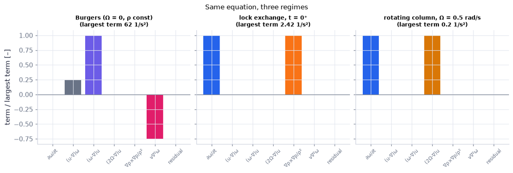

```python
scenes = ["burgers", "lock_exchange", "rotating_column"]              # three regimes of (5.30)
titles = ["Burgers (Ω = 0, ρ const)", "lock exchange, t = 0⁺", "rotating column, Ω = 0.5 rad/s"]
keys = ["local", "advective", "stretching_tilting", "planetary", "baroclinic", "diffusion", "residual"]   # the bars of (5.30)
cols = [COLORS["blue"], COLORS["muted"], COLORS["accent"], COLORS["amber"], COLORS["orange"], COLORS["rose"], COLORS["ink"]]
labs = ["∂ω/∂t", "(u·∇)ω", "(ω·∇)u", "(2Ω·∇)u", "∇ρ×∇p/ρ²", "ν∇²ω", "residual"]
fig, axs = plt.subplots(1, 3, figsize=(11.5, 3.8), sharey=True)      # one panel per scene
for a, nm, tt in zip(axs, scenes, titles):
    b = ch05.vorticity_budget_preset(nm)                              # z-components [1/s²]
    big = max(abs(b[k]) for k in keys)                                # the largest term of this scene
    a.bar(range(7), [b[k]/big for k in keys], color=cols)             # normalised by it
    a.axhline(0, color=COLORS["muted"], lw=0.8); a.set_xticks(range(7)); a.set_xticklabels(labs, rotation=45, fontsize=8)
    a.set_title(f"{tt}\n(largest term {big:.3g} 1/s²)", fontsize=9)
axs[0].set_ylabel("term / largest term [–]")                          # normalised, so the three scenes share an axis
fig.suptitle("Same equation, three regimes", fontsize=11)
savefig(fig, "ch05", "vorticity_budget_530"); plt.show()             # save the PNG to outputs/ch05, then draw
```

**What you see.** (Note `N37`: reading the terms of (5.30), $\frac{D\boldsymbol\omega}{Dt}=(\boldsymbol\omega+2\boldsymbol\Omega)\cdot\nabla\mathbf u+\frac1{\rho^2}\nabla\rho\times\nabla p+\nu\nabla^2\boldsymbol\omega$.) Burgers — grey advective bar balanced by purple stretching and a negative rose diffusion bar; lock exchange — one orange baroclinic bar and the blue local bar it drives; rotating column — the amber planetary bar equals the blue local bar. Every residual (black) is invisible.

**How to read it.** The left side of (5.30) is the rate following a particle (blue + grey); $\nu\nabla^2\boldsymbol\omega$ is molecular diffusion (as $\nu\nabla^2\mathbf u$ diffuses velocity); the baroclinic bar exists only where ∇ρ crosses ∇p; stretching matters even with Ω = 0. Each panel is divided by its own largest term — the titles give the sizes (62, 2.4 and 0.2 s⁻²).

**What would change if…** …Ω switched off in the rotating column: the amber bar vanishes and nothing spins the column up.

> ⚠️ **Common confusion:** "Boussinesq means the density can be treated as constant." In (5.30), $\frac{D\boldsymbol\omega}{Dt}=(\boldsymbol\omega+2\boldsymbol\Omega)\cdot\nabla\mathbf u+\frac1{\rho^2}\nabla\rho\times\nabla p+\nu\nabla^2\boldsymbol\omega$ ρ is kept inside the pressure term — that is where the baroclinic source lives. To leading order $\frac{1}{\rho^2}\nabla\rho\times\nabla p\approx\frac{1}{\rho_0}\nabla\rho'\times\mathbf g$ with g = −g e_z (cf. Ch. 4's Boussinesq momentum equation $\frac{D\mathbf u}{Dt}=-\frac1{\rho_0}\nabla p'+\frac{\rho'}{\rho_0}\mathbf g+\nu\nabla^2\mathbf u$ *(4.86)*): only the density *perturbation* crossed with gravity matters.

🎮 **What does a spinning planet add to the vorticity equation?** (embedded after C11 below) walks through D14 and D15 with term bars in its Derivation tab.

**What would change if…** …we looked at one vortex line in an inviscid, barotropic, inertial flow? Only $(\boldsymbol\omega\cdot\nabla)\mathbf u$ would remain — and it splits cleanly into stretching and tilting (C10).

### 🧩 Stretching and tilting of vortex lines `C10`

*The question:* A figure skater spins faster by pulling in her arms; a tornado tightens as its column is stretched upward. How can a flow make vorticity stronger without any torque at all?

*In one line:* $\frac{D\omega_s}{Dt}=\omega\frac{\partial u_s}{\partial s},\ \frac{D\omega_n}{Dt}=\omega\frac{\partial u_n}{\partial s},\ \frac{D\omega_m}{Dt}=\omega\frac{\partial u_m}{\partial s}$ *(5.32)*

#### The problem in plain words

In three dimensions a flow can amplify the vorticity it carries simply by stretching vortex lines, and redirect it by tilting them. This is how turbulence builds its thin, intense vortices (Ch. 12) and why a flat, two-dimensional flow behaves so differently. It is also, with the planet's vorticity, how a converging column of air becomes a cyclone (C11).

#### The idea

```
(w . grad)u = |w| du/ds        (how u changes ALONG the vortex line)                                     (5.31)
   |- along the line  (du_s/ds > 0): the line is stretched -> thinner -> spins faster   (the skater)
   '- across the line (du_n/ds, du_m/ds): the line is turned -> vorticity appears in new directions (tilting)   (5.32)
2-D flow: w perpendicular to the plane, nothing varies along it -> neither
```

*The numbered equations in the sketch:* $(\boldsymbol\omega\cdot\nabla)\mathbf u=\omega\frac{\partial\mathbf u}{\partial s}$ *(5.31)* · $\frac{D\omega_s}{Dt}=\omega\frac{\partial u_s}{\partial s},\ \frac{D\omega_n}{Dt}=\omega\frac{\partial u_n}{\partial s},\ \frac{D\omega_m}{Dt}=\omega\frac{\partial u_m}{\partial s}$ *(5.32)*

> 📎 **Primer — Frenet frame of a curve.** `P145` · At each point of a smooth curve: the unit tangent $\mathbf e_s$, the principal normal (toward the centre of curvature) and the binormal (their cross product). The book's Fig. 5.9 takes $\mathbf e_n$ **away** from the centre of curvature (the opposite of the usual Frenet normal) and $\mathbf e_m$ as the second normal; for a helix of radius a and pitch 2πc the curvature is $a/(a^2+c^2)$ and the torsion $c/(a^2+c^2)$.

```python
d = ch05.helix_frame(0.0, a=1.0, c=0.3)                  # the frame at s = 0 of a helix, radius 1 m, pitch 2π·0.3 m
print(np.round([d['e_s'], d['e_n'], d['e_m']], 4))       # three orthonormal vectors; e_n = (1, 0, 0) points away from the axis
print(round(d['curvature'], 6), round(d['torsion'], 6), np.dot(d['e_s'], d['e_n']))   # 0.917431 0.275229 0.0
```

```
[[-0.      0.9578  0.2873]
 [ 1.      0.      0.    ]
 [ 0.      0.2873 -0.9578]]
0.917431 0.275229 0.0
```

> 📎 **Primer — angular momentum of a spinning cylinder.** `P146` · A cylinder of mass m and radius R spinning at Ω about its axis has angular momentum L = IΩ with I = ½mR² = mA/2π (A its cross-section). With no torque L is fixed; stretch the cylinder at fixed mass and volume and A shrinks, so Ω grows like 1/A — like the length.

```python
m, A0, Om0 = 1.0, 1e-4, 10.0                             # mass [kg], cross-section [m²], spin [rad/s]
for stretch in (1, 2, 4):                                # length × 1, 2, 4 at fixed volume
    A = A0/stretch; Om = Om0*A0/A                        # L = (m A/2π) Ω fixed
    print(stretch, A, Om)                                # the spin doubles when the length doubles
```

```
1 0.0001 10.0
2 5e-05 20.0
4 2.5e-05 40.0
```

> 🔁 **Tools from earlier chapters used here** (see `knowledge/primers.md`) — needed in the derivations below
- **orthonormal basis, projection and completeness** — the component of a vector along a unit vector e is its dot product with e; three orthonormal vectors rebuild it (Ch. 2 P65).

#### 🧮 Derivation — Natural coordinates on a vortex line: (ω·∇)u = ω ∂u/∂s, (5.31) `D16` (Eq. 5.31)

**What we want to show.** Rewrite the stretching–tilting term of (5.13), $\frac{D\boldsymbol\omega}{Dt}=(\boldsymbol\omega\cdot\nabla)\mathbf u+\nu\nabla^2\boldsymbol\omega$ in coordinates that follow a vortex line, so each part has a picture.

**Assumptions.** ω ≠ 0 at the point (step 3); the frame is frozen at the instant (step 5).

**The plan.**

1. Write ∇ in the local frame.
2. Dot with ω.
3. Use that ω points along e_s.
4. Project on the frame.

**Tools we use** (each explained before this point): Frenet frame of a curve (primer in C10) · level sets and the directional derivative (ch02 P75, reminder) · orthonormal basis and projection (ch02 P65, reminder).

**We start from**

$$ \begin{array}{l}(\boldsymbol\omega\cdot\nabla)\mathbf u\ \text{at a point where ω ≠ 0, with the local orthonormal frame (e\_s,} \\ \text{e\_n, e\_m) of Fig. 5.9}\end{array} $$

*In words:* s along the vortex line, n away from its centre of curvature, m the second normal.

**Step 1 of 6 — Write ∇ in the line's own frame.**

$$ \nabla=\mathbf e_s\frac{\partial}{\partial s}+\mathbf e_n\frac{\partial}{\partial n}+\mathbf e_m\frac{\partial}{\partial m} $$

- *Why we can do this:* At one point any orthonormal basis can carry the gradient: each ∂/∂(·) is a directional derivative along its unit vector (P75).
- *In words:* Measure changes along, across and out of the line.

**Step 2 of 6 — Dot the operator with ω.**

$$ \boldsymbol\omega\cdot\nabla=(\boldsymbol\omega\cdot\mathbf e_s)\frac{\partial}{\partial s}+(\boldsymbol\omega\cdot\mathbf e_n)\frac{\partial}{\partial n}+(\boldsymbol\omega\cdot\mathbf e_m)\frac{\partial}{\partial m} $$

- *Why we can do this:* Linearity of the dot product: ω·(a + b + c) = ω·a + ω·b + ω·c, applied to the three terms of step 1.
- *In words:* Weight each directional derivative by ω's component along it.

**Step 3 of 6 — Use that ω points along the line.**

$$ \boldsymbol\omega\cdot\mathbf e_s=\omega,\qquad\boldsymbol\omega\cdot\mathbf e_n=\boldsymbol\omega\cdot\mathbf e_m=0 $$

- *Why we can do this:* A vortex line is tangent to ω, so e_s = ω/|ω| and ω = |ω| = the magnitude.
- *In words:* Only the along-line derivative survives.

**Step 4 of 6 — Apply the operator to u.**

$$ (\boldsymbol\omega\cdot\nabla)\mathbf u=\omega\frac{\partial\mathbf u}{\partial s} $$

- *Why we can do this:* Steps 2–3. This is (5.31), $(\boldsymbol\omega\cdot\nabla)\mathbf u=\omega\frac{\partial\mathbf u}{\partial s}$ — the line above (the printed line ends in ω ∂/∂s; u is understood).
- *In words:* Stretching–tilting = vorticity magnitude × how u changes along the line.

**Step 5 of 6 — Project on the three directions.**

$$ \omega\frac{\partial\mathbf u}{\partial s}\ \to\ \Big(\omega\frac{\partial u_s}{\partial s},\ \omega\frac{\partial u_n}{\partial s},\ \omega\frac{\partial u_m}{\partial s}\Big) $$

- *Why we can do this:* Components are projections on the unit vectors (P65), with the frame frozen at this point: ∂u_s/∂s means e_s·∂u/∂s.
- *In words:* One along the line, two across it.

**Step 6 of 6 — Give each component its picture.**

$$ \frac{\partial u_s}{\partial s}=\mathbf e_s\cdot\mathsf G\,\mathbf e_s $$

- *Why we can do this:* The along-line part is the stretching rate of a material element along e_s (Ch. 3 §3.4); ∂u_n/∂s and ∂u_m/∂s turn the element about m and n.
- *In words:* Along = stretching; across = tilting.

**Result**

$$ (\boldsymbol\omega\cdot\nabla)\mathbf u=\omega\frac{\partial\mathbf u}{\partial s} $$

*In words:* the stretching–tilting term is the vorticity magnitude times the rate at which the velocity changes along the vortex line.

**What it means.** Only the variation of u along the line matters: parallel to ω it stretches, across ω it tilts.

**Check it.** Units s⁻² ✓. `stretching_tilting_split` (the code cell after the tiny example of this block): stretching + tilting = Gω to 1e-12; stretching ∥ ω, tilting ⟂ ω; axial strain (α = 1 s⁻¹) along ω: rate = α, tilting 0 ✓.

> ⚠️ **Common confusion (traps in `D16`):** Thinking ∂u_n/∂s involves the frame's turning (the frame is frozen). Taking e_n toward the centre of curvature (the book's e_n points away — opposite to the usual Frenet N).

📝 **Note.** **Natural coordinates** `N38` — D16's result is (5.31). The stretching part is $(\mathbf e_s\cdot\mathsf G\,\mathbf e_s)\boldsymbol\omega$ along ω; the tilting part is the rest of $\mathsf G\boldsymbol\omega$, perpendicular to ω.

$$ (\boldsymbol\omega\cdot\nabla)\mathbf u=\Big[\boldsymbol\omega\cdot\Big(\mathbf e_s\frac{\partial}{\partial s}+\mathbf e_n\frac{\partial}{\partial n}+\mathbf e_m\frac{\partial}{\partial m}\Big)\Big]\mathbf u=\omega\frac{\partial\mathbf u}{\partial s} \qquad \text{(5.31)} $$

#### 🧮 Derivation — Stretching and tilting components (5.32), and the angular-momentum reading `D17` (Eq. 5.32)

**What we want to show.** Write (5.30), $\frac{D\boldsymbol\omega}{Dt}=(\boldsymbol\omega+2\boldsymbol\Omega)\cdot\nabla\mathbf u+\frac1{\rho^2}\nabla\rho\times\nabla p+\nu\nabla^2\boldsymbol\omega$ along the natural frame for an ideal fluid and see stretching as the spinning skater and tilting as turning — and why neither exists in 2-D.

**Assumptions.** Inertial frame Ω = 0, barotropic, inviscid (step 1); frame frozen at the instant (step 3).

**The plan.**

1. Remove rotation, baroclinicity and viscosity.
2. Use (5.31), $(\boldsymbol\omega\cdot\nabla)\mathbf u=\omega\frac{\partial\mathbf u}{\partial s}$.
3. Project.
4. Interpret.

**Tools we use** (each explained before this point): (5.31), $(\boldsymbol\omega\cdot\nabla)\mathbf u=\omega\frac{\partial\mathbf u}{\partial s}$ (D16) · projection (ch02 P65, reminder) · angular momentum of a spinning cylinder (primer in C10).

**We start from**

$$ \text{(5.30)}\ \frac{D\boldsymbol\omega}{Dt}=(\boldsymbol\omega+2\boldsymbol\Omega)\cdot\nabla\mathbf u+\frac1{\rho^2}\nabla\rho\times\nabla p+\nu\nabla^2\boldsymbol\omega $$

*In words:* the full vorticity equation.

**Step 1 of 5 — Remove rotation, baroclinicity, viscosity.**

$$ \frac{D\boldsymbol\omega}{Dt}=(\boldsymbol\omega\cdot\nabla)\mathbf u $$

- *Why we can do this:* Ω = 0, ∇ρ ∥ ∇p and ν = 0 remove three terms of (5.30), $\frac{D\boldsymbol\omega}{Dt}=(\boldsymbol\omega+2\boldsymbol\Omega)\cdot\nabla\mathbf u+\frac1{\rho^2}\nabla\rho\times\nabla p+\nu\nabla^2\boldsymbol\omega$.
- *In words:* In an ideal fluid only stretching and tilting act.

**Step 2 of 5 — Use the natural-coordinate form.**

$$ \frac{D\boldsymbol\omega}{Dt}=\omega\frac{\partial\mathbf u}{\partial s} $$

- *Why we can do this:* Use (5.31), $(\boldsymbol\omega\cdot\nabla)\mathbf u=\omega\frac{\partial\mathbf u}{\partial s}$ from D16: at a point where ω ≠ 0 the operator ω·∇ is the magnitude ω times the derivative along the vortex line.
- *In words:* The rate is set by how u changes along the line.

**Step 3 of 5 — Project on s, n, m.**

$$ \frac{D\omega_s}{Dt}=\omega\frac{\partial u_s}{\partial s},\quad\frac{D\omega_n}{Dt}=\omega\frac{\partial u_n}{\partial s},\quad\frac{D\omega_m}{Dt}=\omega\frac{\partial u_m}{\partial s} $$

- *Why we can do this:* Components in the frame frozen at the instant (the frame's own turning is not part of this instantaneous statement). This is (5.32), $\frac{D\omega_s}{Dt}=\omega\frac{\partial u_s}{\partial s},\ \frac{D\omega_n}{Dt}=\omega\frac{\partial u_n}{\partial s},\ \frac{D\omega_m}{Dt}=\omega\frac{\partial u_m}{\partial s}$ — the line above.
- *In words:* Stretching changes the along-line vorticity; tilting creates across-line vorticity.

**Step 4 of 5 — Read stretching as angular momentum.**

$$ L=I\,\Omega_{spin},\quad I\propto mA\ \Rightarrow\ \Omega_{spin}\propto1/A $$

- *Why we can do this:* A spinning cylinder of fixed mass m keeps L without torque; stretching it thins it (A falls), so it spins faster (primer). Pressure exerts no torque on it (D09).
- *In words:* The skater pulling in her arms.

**Step 5 of 5 — Check the 2-D case.**

$$ \boldsymbol\omega=\omega\,\mathbf e_z,\ \mathbf u=(u,v,0)(x,y)\ \Rightarrow\ \frac{\partial\mathbf u}{\partial s}=\frac{\partial\mathbf u}{\partial z}=\mathbf 0 $$

- *Why we can do this:* In a planar flow ω is normal to the plane and nothing varies along it.
- *In words:* In 2-D vorticity can be carried and diffused, never stretched or tilted.

**Result**

$$ \frac{D\omega_s}{Dt}=\omega\frac{\partial u_s}{\partial s}\ \text{,}\ \frac{D\omega_n}{Dt}=\omega\frac{\partial u_n}{\partial s}\ \text{,}\ \frac{D\omega_m}{Dt}=\omega\frac{\partial u_m}{\partial s} $$

*In words:* stretching along a vortex line spins it up; shear across it tilts it; neither happens in 2-D.

**What it means.** Stretching is how 3-D turbulence concentrates vorticity into thin intense tubes (Ch. 12); its absence in 2-D is why 2-D and 3-D turbulence differ; with planetary vorticity it spins up converging columns (C11).

**Check it.** Axial strain (the code cell after the tiny example of this block): ω_z(t) = ω₀e^{αt} (`uniform_strain_vorticity`), e² = 7.389 at αt = 2 ✓. Shear tilt w = s x: ω_z = s t ω_x0 (= 2.0 at s = 1 s⁻¹, t = 2 s) ✓. Planar strain with ω ⟂ plane: unchanged ✓.

> ⚠️ **Common confusion (traps in `D17`):** Reading (5.32), $\frac{D\omega_s}{Dt}=\omega\frac{\partial u_s}{\partial s},\ \frac{D\omega_n}{Dt}=\omega\frac{\partial u_n}{\partial s},\ \frac{D\omega_m}{Dt}=\omega\frac{\partial u_m}{\partial s}$ as equations for a fixed frame over finite time (the frame turns). Expecting stretching in a flat flow.

#### ✏️ Tiny example: stretching and tilting of one vortex line

ω = (1, 0, 1) s⁻¹ in the axial strain G = diag(−½, −½, 1) s⁻¹ (u = −x/2, v = −y/2, w = z).

1. $(\boldsymbol\omega\cdot\nabla)\mathbf u=\mathsf G\boldsymbol\omega$ = (−0.5, 0, 1) s⁻².
2. $\mathbf e_s=\boldsymbol\omega/\lvert\boldsymbol\omega\rvert$ = (1, 0, 1)/√2; stretching rate $\mathbf e_s\cdot\mathsf G\,\mathbf e_s$ = (−0.5 + 1)/2 = 0.25 s⁻¹.
3. Stretching part 0.25 × ω = (0.25, 0, 0.25) — along ω.
4. Tilting part (−0.5, 0, 1) − (0.25, 0, 0.25) = (−0.75, 0, 0.75) — perpendicular to ω (dot product −0.75 + 0.75 = 0): the line is being turned toward the stretching axis z.

> 🔁 **Tools from earlier chapters used here** (see `knowledge/primers.md`)
- **scipy.linalg.expm and e^{Gt}ω₀** — the matrix exponential solves $d\boldsymbol\omega/dt=\mathsf G\boldsymbol\omega$ for a constant G: $\boldsymbol\omega(t)=e^{\mathsf Gt}\boldsymbol\omega_0$ (Ch. 2 P79).

```python
S = ch05.stretching_tilting_split(np.array([1.0, 0, 1.0]), ch05.strain_preset("axial_stretch"))   # the tiny example
print(f"e_s {S['e_s'].round(4)}, rate {S['rate']:.4f} 1/s, stretching {S['stretching'].round(4)}, tilting {S['tilting'].round(4)}, total Gω {S['total'].round(4)}")
S2 = ch05.stretching_tilting_split(np.array([0, 0, 2.0]), ch05.strain_preset("axial_stretch"))   # ω along the stretching axis
print(f"ω along z: rate {S2['rate']:.4f} 1/s (= α), tilting {S2['tilting']}")                      # rate α = 1, tilting 0
for name, w0 in (("axial_stretch", [0, 0, 1]), ("shear_tilt", [1, 0, 0]), ("planar", [0, 0, 1])):   # three steady linear flows, rate 1 1/s
    print(name, np.round(ch05.uniform_strain_vorticity(w0, name, 2.0), 4))   # ω after 2 s = e^{2G} ω0 (inviscid, frozen-in)
print(ch05.stretched_tube(2.0, 1.0, 10.0, 1e-4))                      # a tube stretched from 1 m to 2 m: ω 10 → 20 1/s, area halves
```

```
e_s [0.7071 0.     0.7071], rate 0.2500 1/s, stretching [0.25 0.   0.25], tilting [-0.75  0.    0.75], total Gω [-0.5  0.   1. ]
ω along z: rate 1.0000 1/s (= α), tilting [0. 0. 0.]
axial_stretch [0.     0.     7.3891]
shear_tilt [1. 0. 2.]
planar [0. 0. 1.]
{'omega': 20.0, 'A': 5e-05, 'Gamma': 0.001, 'radius_ratio': 0.7071067811865476}
```

**What does the code above do?**

1. The split of the worked example: $\mathbf e_s$ = (0.7071, 0, 0.7071), rate 0.25 s⁻¹, stretching (0.25, 0, 0.25), tilting (−0.75, 0, 0.75), total Gω = (−0.5, 0, 1).
2. With ω along the stretching axis the whole of Gω is stretching (rate α = 1 s⁻¹) and the tilting is zero.
3. Three steady linear flows for 2 s: axial stretching multiplies ω_z by e² = 7.389; the shear w = x tilts ω_x into ω_z = s t ω_x = 2.0; the planar strain leaves ω ⟂ plane alone.
4. The stretched tube of D18: ω doubles, the area halves, Γ = ωA stays 10⁻³ m²/s.

**From scratch — the projection by hand:** the part of Gω along ω, and the rest.

```python
w = np.array([1.0, 0, 1.0]); G = ch05.strain_preset("axial_stretch")   # the tiny example's ω [1/s] and G [1/s]
es = w/np.linalg.norm(w)                                             # unit vector along the vortex line
rate = es @ G @ es                                                   # stretching rate e_s·G e_s [1/s]
st = rate*w                                                          # stretching part (along ω) [1/s²]
ti = G @ w - st                                                      # tilting part: the rest of Gω [1/s²]
print(rate, st, ti, ti @ w)                                          # 0.25, (0.25, 0, 0.25), (−0.75, 0, 0.75), 0
assert np.allclose(st, S["stretching"]) and np.allclose(ti, S["tilting"]) and abs(ti @ w) < 1e-14   # = the library, and ⟂ ω
```

```
0.24999999999999994 [0.25 0.   0.25] [-0.75  0.    0.75] 0.0
```

```python
a_h, c_h, s0 = 1.0, 0.3, 1.0                                         # helix radius [m], pitch/2π [m], arc length of the marked point [m]
sl = np.linspace(0, 3*2*np.pi*np.hypot(a_h, c_h), 400)               # three turns of arc length [m]
Xh = ch05.helix(sl, a_h, c_h)                                        # the vortex line (3, 400) [m]
P0 = ch05.helix(s0, a_h, c_h); fr = ch05.helix_frame(s0, a_h, c_h)   # the marked point and its natural frame
fig = go.Figure(go.Scatter3d(x=Xh[0], y=Xh[1], z=Xh[2], mode="lines", line=dict(color=COLORS["teal"], width=5), name="vortex line"))  # the helical vortex line
for key, col in (("e_s", COLORS["ink"]), ("e_n", COLORS["orange"]), ("e_m", COLORS["muted"])):   # the frame (book convention: e_n away from the axis)
    e = 0.6*fr[key]                                                                                 # a frame vector drawn 0.6 m long
    fig.add_trace(go.Scatter3d(x=[P0[0], P0[0] + e[0]], y=[P0[1], P0[1] + e[1]], z=[P0[2], P0[2] + e[2]], mode="lines+text",  # draw it from the marked point
                               text=["", key], line=dict(color=col, width=6), name=key))            # labelled at its tip
presets = ["axial_stretch", "shear_tilt", "planar"]                  # three velocity gradients G (rate 1 1/s)
for j, nm in enumerate(presets):                                     # the stretching and tilting arrows for each G, |ω| = 1 1/s
    sp_ = ch05.stretching_tilting_split(fr["e_s"], ch05.strain_preset(nm))                          # split Gω into stretching and tilting (|ω| = 1 1/s)
    for part, col in (("stretching", COLORS["accent"]), ("tilting", COLORS["blue"])):               # purple along the line, blue across it
        v = 0.8*sp_[part]                                                                           # the arrow, scaled for visibility
        fig.add_trace(go.Scatter3d(x=[P0[0], P0[0] + v[0]], y=[P0[1], P0[1] + v[1]], z=[P0[2], P0[2] + v[2]], mode="lines",  # drawn from the marked point
                                   line=dict(color=col, width=10), name=f"{part} ({nm})", visible=(j == 0)))  # only the first flow's arrows start visible
buttons = []                                                          # a dropdown: show the arrows of one G at a time
for j, nm in enumerate(presets):                                                                    # one dropdown button per flow
    vis = [True]*4 + [k//2 == j for k in range(6)]                   # line + 3 frame vectors always; 2 arrows per preset
    buttons.append(dict(label=nm, method="update", args=[{"visible": vis}]))                        # shows that flow's two arrows
fig.update_layout(updatemenus=[dict(buttons=buttons, x=0.02, y=0.98)], height=500, margin=dict(l=0, r=0, t=40, b=0),  # the dropdown, size and title
                  title=f"Natural frame on a helix (κ = {fr['curvature']:.4f} 1/m): stretching (purple) and tilting (blue)",  # the message of the figure
                  scene=dict(aspectmode="data", xaxis_title="x [m]", yaxis_title="y [m]", zaxis_title="z [m]"))  # equal axes, labels with units
fig.show()                                                                                          # draw it (works on the web page too)
```

[interactive chart not shown]

**What you see.** (Note `N53`, Fig. 5.9 analogue.) A teal helical vortex line with, at one point, its frame (e_s black along the line, e_n orange pointing away from the axis, e_m grey) and a thick purple arrow along the line plus a blue one across it; the dropdown (a plotly `updatemenus` menu) switches between three flows.

**How to read it.** $(\boldsymbol\omega\cdot\nabla)\mathbf u=\omega\frac{\partial\mathbf u}{\partial s}$ (5.31): only the change of u along the line counts; its along-component stretches (purple), its across-components tilt (blue).

**What would change if…** …the planar preset: G has no z-row or column, so for a line that is mostly vertical both arrows shrink — and for a line exactly along z they vanish (2-D flow).

**Stretching and tilting in motion.** Left, a vortex tube in axial strain α = 1 s⁻¹ seen side-on (it lengthens as $e^{\alpha t}$ and thins as $e^{-\alpha t/2}$) and end-on with a spin marker; middle, a vortex segment in the shear w = s x (s = 1 s⁻¹) being tilted from x toward z; right, the growth |ω|(t)/|ω₀| (purple) against the ghost $e^{\alpha t}$ and the tilt angle (blue). Use ◀ ▶ to step.

```python
nf = 19 if not FAST else 10                                          # frames
tt = np.linspace(0, 3*np.log(2), nf)                                 # 0 … 3 ln 2 s, so that frames land on t = ln 2 and 2 ln 2 [s]
alpha, s_sh, w0 = 1.0, 1.0, 10.0                                     # strain rate, shear rate [1/s], initial vorticity [1/s]
grow = np.array([ch05.uniform_strain_vorticity([0, 0, 1], "axial_stretch", t_)[2] for t_ in tt])   # |ω|/|ω0| in axial strain
tilt = np.array([ch05.uniform_strain_vorticity([1, 0, 0], "shear_tilt", t_) for t_ in tt])         # ω(t) of a segment in shear
with plt.rc_context(ANIM_RC):                                         # light settings for fast frames
    fig, (a, b, c) = plt.subplots(1, 3, figsize=(10.5, 3.6), dpi=80)
fig.subplots_adjust(left=0.04, right=0.98, bottom=0.14, top=0.86, wspace=0.3)   # fixed margins
tube = plt.Rectangle((-0.5, -0.1), 1.0, 0.2, fc=COLORS["teal"], alpha=0.4, ec=COLORS["teal"]); a.add_patch(tube)   # side view
circ = plt.Circle((0, 0.75), 0.1, fc="none", ec=COLORS["teal"], lw=2); a.add_patch(circ)   # end view
(spoke,) = a.plot([0, 0.1], [0.75, 0.75], color=COLORS["ink"], lw=2)   # spin marker
a.set_xlim(-4, 4); a.set_ylim(-0.6, 1.1); a.set_aspect("equal"); a.axis("off"); a.set_title("axial strain: length × e^{αt}")
(seg,) = b.plot([0, 1], [0, 0], color=COLORS["blue"], lw=3)          # the vortex segment in the (x, z) plane
b.set_xlim(-0.2, 1.3); b.set_ylim(-0.2, 2.2); b.set_aspect("equal"); b.set_xlabel("ω_x [1/s]"); b.set_ylabel("ω_z [1/s]")
b.set_title("shear w = s x: ω_x tilted into ω_z")
c.plot(tt, np.exp(alpha*tt), color=COLORS["muted"], ls="--", label="ghost e^{αt}")   # the prediction
(gl,) = c.plot([], [], color=COLORS["accent"], lw=2.5, label="|ω|/|ω₀|, axial strain")
(tl,) = c.plot([], [], color=COLORS["blue"], lw=2, label="tilt angle [rad], shear")
c.set_xlim(0, tt[-1]); c.set_ylim(0, 8.5); c.set_xlabel("t [s]"); c.legend(fontsize=7, loc="upper left"); c.set_title("growth and tilt")
theta = (w0/(2*alpha))*(np.exp(alpha*tt) - 1)                        # angle turned by the spin marker: ∫ ω/2 dt [rad]


def update(i):                                                       # draw frame i
    L = np.exp(alpha*tt[i]); r = 0.1*np.exp(-alpha*tt[i]/2)          # length × e^{αt}, radius × e^{−αt/2}
    tube.set_bounds(-0.5*L, -r, L, 2*r)                              # the stretched, thinned tube
    circ.set_radius(r)                                               # its end view
    spoke.set_data([0, r*np.cos(theta[i])], [0.75, 0.75 + r*np.sin(theta[i])])   # the spin marker turns faster and faster
    seg.set_data([0, tilt[i][0]], [0, tilt[i][2]])                   # ω = (1, 0, s t): tilted toward z
    gl.set_data(tt[:i + 1], grow[:i + 1]); tl.set_data(tt[:i + 1], np.arctan2(tilt[:i + 1, 2], tilt[:i + 1, 0]))
    fig.suptitle(f"t = {tt[i]:.2f} s: length × {L:.2f}, |ω| × {grow[i]:.2f}", fontsize=10)
    return tube, circ, spoke, seg, gl, tl


with plt.rc_context(ANIM_RC):                                         # render the frames with the light settings
    show_animation(animate(update, frames=nf, fig=fig, interval=250), player="frames")   # step through with ◀ ▶
```

[figure not shown]

**What you see.** The tube lengthens and thins while its end-view spoke turns faster; the blue segment swings from the x-axis toward z; the purple growth curve lies on the grey ghost and the blue tilt angle climbs toward π/2.

**How to read it.** Step to t = ln 2 ≈ 0.69 s: length × 2, vorticity × 2 — D18's ω ∝ L; at 2 ln 2 ≈ 1.39 s both are × 4, at the last frame × 8. The tilted segment's ω_z = s t ω_x grows linearly; no torque acts in either case (D17 step 4).

**What would change if…** …α negative (compression): the tube shortens, fattens and spins down.

📝 **Note.** **Burgers' vortex** `N21` — (the book leaves it to Exercise 5.12): an axial strain $u_R=-\alpha R/2$, $u_z=\alpha z$ with a swirl, as below, is steady because stretching (which would thin and intensify the core) is balanced by diffusion (which would spread it). D18 derives the balance. **Number:** α = 1 s⁻¹, water, Γ = 10⁻³ m²/s: core radius $\sqrt{4\nu/\alpha}$ = 2 mm, peak vorticity 79.6 s⁻¹. → the classic model of the finest vortices of turbulence (Ch. 12).

$$ u_\varphi=\frac{\Gamma}{2\pi R}\Big[1-e^{-\alpha R^2/4\nu}\Big],\qquad\omega_z=\frac{\alpha\Gamma}{4\pi\nu}e^{-\alpha R^2/4\nu} $$

> 🔁 **Tools from earlier chapters used here** (see `knowledge/primers.md`) — needed in the derivation below
- **separation of variables** — put everything with ω on one side and everything with R on the other, then integrate both (Ch. 1 P42).
- **natural logarithm and exponential** — $\int dy/y=\ln y$, so y′/y = k gives $y=y_0e^{kx}$ (Ch. 1 P36).

*Glosses used in D18.* **Incompressible tube:** a material tube of fixed volume V = A L gets thinner as it gets longer. **Cylindrical Laplacian of an axisymmetric scalar:** $\nabla^2\omega_z=\frac1R\frac{d}{dR}\big(R\frac{d\omega_z}{dR}\big)$ when ω_z depends on R only.

#### 🧮 Derivation — A stretched tube spins faster (ω ∝ L), and Burgers' vortex balances stretching against diffusion `D18` (Eq. 5.13)

**What we want to show.** Put numbers on stretching: an ideal tube stretched to twice its length has twice the vorticity; with viscosity, a steady axial strain holds a vortex at a fixed core size — the book leaves this to Exercise 5.12 and never writes the balance.

**Assumptions.** Inviscid, uniform ω in a thin tube (steps 1–3); steady, axisymmetric, ν > 0 (steps 4–9); decay at R → ∞ and regularity at R = 0 (step 8).

**The plan.**

1. Ideal tube: strength and volume fixed, eliminate the area.
2. Burgers: write (5.13), $\frac{D\boldsymbol\omega}{Dt}=(\boldsymbol\omega\cdot\nabla)\mathbf u+\nu\nabla^2\boldsymbol\omega$ for an axial strain plus swirl, integrate the steady balance once, then again.

**Tools we use** (each explained before this point): Helmholtz 4 (C05) · incompressibility A L = const (gloss) · cylindrical Laplacian of an axisymmetric scalar (gloss) · separation of variables (ch01 P42, reminder) · exponential solution of a first-order ODE (ch01 P36, reminder).

**We start from**

$$ \begin{array}{l}\text{Helmholtz 4 (tube strength constant in time, D08) and} \\ \frac{D\boldsymbol\omega}{Dt}=(\boldsymbol\omega\cdot\nabla)\mathbf u+\nu\nabla^2\boldsymbol\omega\ \text{(5.13)}\end{array} $$

*In words:* an ideal tube keeps its strength; a real one also diffuses.

**Step 1 of 9 — Fix the ideal tube's strength.**

$$ \Gamma=\omega A=\text{const} $$

- *Why we can do this:* Helmholtz 4 (D08): an inviscid tube keeps its strength; for a thin tube with uniform ω the strength is ω times the section.
- *In words:* Vorticity × area stays put.

**Step 2 of 9 — Fix its volume.**

$$ A\,L=V=\text{const} $$

- *Why we can do this:* The tube is material (Helmholtz 1) and the fluid incompressible (gloss).
- *In words:* Stretch it longer and it gets thinner.

**Step 3 of 9 — Eliminate the area.**

$$ \omega=\frac{\Gamma}{A}=\frac{\Gamma L}{V}\ \propto\ L $$

- *Why we can do this:* Divide step 1 by A and use step 2.
- *In words:* Double the length, double the vorticity.

**Step 4 of 9 — Take Burgers' axisymmetric strain.**

$$ u_R=-\tfrac12\alpha R,\quad u_z=\alpha z,\quad\boldsymbol\omega=\omega_z(R)\,\mathbf e_z $$

- *Why we can do this:* A steady axial stretching flow (α > 0) that satisfies ∇·u = (1/R)∂(Ru_R)/∂R + ∂u_z/∂z = −α + α = 0; a swirl adds ω_z.
- *In words:* Fluid is drawn in sideways and stretched upward.

**Step 5 of 9 — Write the steady z-component of (5.13).**

$$ u_R\frac{d\omega_z}{dR}=\omega_z\frac{\partial u_z}{\partial z}+\nu\frac1R\frac{d}{dR}\Big(R\frac{d\omega_z}{dR}\Big) $$

- *Why we can do this:* Steady: Dω_z/Dt = u_R dω_z/dR; stretching ω_z∂u_z/∂z; cylindrical Laplacian of ω_z(R) (gloss).
- *In words:* Inward carrying = stretching + diffusion.

**Step 6 of 9 — Insert u_R and ∂u_z/∂z = α.**

$$ -\frac{\alpha R}{2}\omega_z'=\alpha\,\omega_z+\frac{\nu}{R}\big(R\,\omega_z'\big)' $$

- *Why we can do this:* Substitute step 4 into step 5: u_R = −αR/2 and ∂u_z/∂z = α, both constant in time, turn it into an ODE in R.
- *In words:* All three processes, one ODE.

**Step 7 of 9 — Spot a total derivative.**

$$ \frac1R\frac{d}{dR}\Big[\nu R\,\omega_z'+\frac{\alpha}{2}R^2\omega_z\Big]=0 $$

- *Why we can do this:* (α/2R)(R²ω_z)′ = αω_z + (αR/2)ω_z′ (product rule), which is exactly the advection + stretching terms moved left.
- *In words:* The balance is one derivative set to zero.

**Step 8 of 9 — Integrate once.**

$$ \nu R\,\omega_z'+\frac{\alpha}{2}R^2\omega_z=0 $$

- *Why we can do this:* The bracket is constant; at R = 0 it is 0 (regularity), so it is 0 everywhere.
- *In words:* Outward diffusive flux of vorticity = inward advective flux.

**Step 9 of 9 — Integrate again and normalise.**

$$ \omega_z=\frac{\alpha\Gamma}{4\pi\nu}\,e^{-\alpha R^2/4\nu} $$

- *Why we can do this:* ω_z′/ω_z = −αR/2ν (separation, P42) gives a Gaussian; ∫ω_z 2πR dR = Γ fixes the amplitude to αΓ/4πν.
- *In words:* A Gaussian core of radius √(4ν/α), where stretching and diffusion balance.

**Result**

$$ \text{Ideal tube:}\ \omega=\Gamma L/V\propto L\ \text{; Burgers:}\ \omega_z=\frac{\alpha\Gamma}{4\pi\nu}e^{-\alpha R^2/4\nu}\ \text{, core radius}\ \sqrt{4\nu/\alpha} $$

*In words:* stretching concentrates vorticity; viscosity spreads it; a steady strain holds the two in balance at a fixed core size.

**What it means.** Burgers' vortex is the classic model of the thin intense vortices of turbulence (Ch. 12); the core size is set by the strain and the viscosity, not by how the vortex started.

**Check it.** Units: αΓ/ν in s⁻¹ ✓; √(ν/α) in m ✓. α → 0: the core widens without bound (pure diffusion, Lamb–Oseen) ✓. Term bars at R = 1 mm (C06's code cell, §5.4): advective = stretching + diffusion, residual ≈ 10⁻⁶ of the largest ✓ (`vorticity_terms`); the code cell right after this derivation prints the core radius, the peak and Γ. The book's α is twice Wikipedia's (same flow; Wikipedia writes v_r = −αr, v_z = 2αz) ✓.

> ⚠️ **Common confusion (traps in `D18`):** Expecting ωA constant with viscosity. Using Wikipedia's α in the book's formula (a factor 2).

```python
R = np.linspace(0, 8e-3, 401)                                        # radius [m]
uR, uphi, uz, wz = ch05.burgers_vortex(R, 0.0, 1e-3, 1.0, 1e-6)       # Burgers: Γ = 1e-3 m²/s, α = 1 1/s, ν = 1e-6 m²/s
print(ch05.burgers_core_radius(1.0, 1e-6), round(wz[0], 4), round(np.trapezoid(wz*2*np.pi*R, R), 7))   # core 2 mm, peak 79.5775, Γ
bb = ch05.vorticity_budget_preset("burgers", x=2e-3)                  # the terms of (5.13) at R = core radius
print({k: round(v, 4) for k, v in bb.items()})                       # advective = stretching = 29.27, diffusion ≈ 0
```

```
0.002 79.5775 0.001
{'local': 0.0, 'advective': 29.2749, 'stretching_tilting': 29.2749, 'planetary': 0.0, 'baroclinic': 0.0, 'diffusion': 0.0, 'residual': -0.0}
```

**What does the code above do?**

1. The closed-form Burgers vortex. 2. Core radius $\sqrt{4\nu/\alpha}$ = 0.002 m, peak ω_z = 79.5775 s⁻¹, and the total circulation $\int\omega_z2\pi R\,dR$ = 0.0010000 m²/s (Γ recovered to about 2×10⁻⁵ on this grid, which stops at 4 core radii).
2. At R = √(4ν/α) the diffusion term changes sign (where the cylindrical Laplacian (1/R)(Rω_z′)′ changes sign): inside it removes vorticity, outside it adds; there advection (+29.27 s⁻²) equals stretching (+29.27 s⁻²).

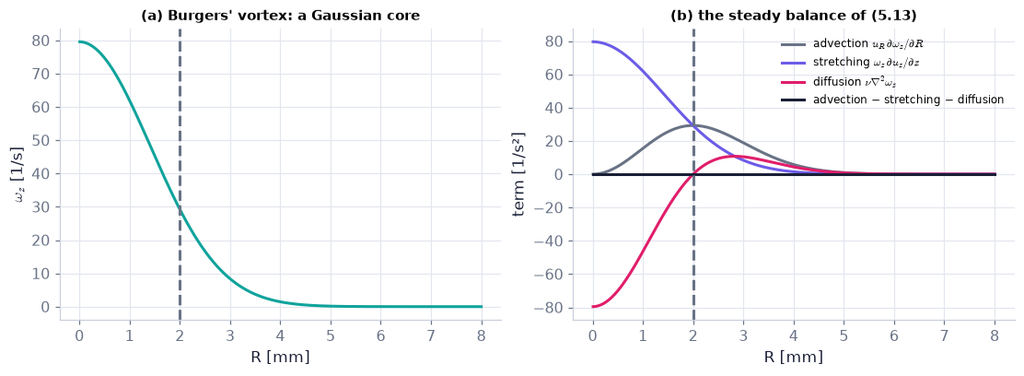

```python
Rm = np.linspace(1e-5, 8e-3, 300)                                    # radius [m] (the terms are regular at R → 0)
bal = ch05.burgers_balance(Rm)                                       # ω_z and the three terms of (5.13) [1/s], [1/s²]
fig, (a, b) = plt.subplots(1, 2, figsize=(10, 3.6))                  # profile | balance
a.plot(Rm*1e3, bal["omega_z"], color=COLORS["teal"]); a.axvline(bal["core_radius"]*1e3, color=COLORS["muted"], ls="--")  # the vorticity profile and the core radius
a.set_xlabel("R [mm]"); a.set_ylabel(r"$\omega_z$ [1/s]"); a.set_title("(a) Burgers' vortex: a Gaussian core", fontsize=10)  # labels with units
b.plot(Rm*1e3, bal["advective"], color=COLORS["muted"], label=r"advection $u_R\,\partial\omega_z/\partial R$")  # grey: advection (left side of (5.13))
b.plot(Rm*1e3, bal["stretching"], color=COLORS["accent"], label=r"stretching $\omega_z\,\partial u_z/\partial z$")  # purple: stretching
b.plot(Rm*1e3, bal["diffusion"], color=COLORS["rose"], label=r"diffusion $\nu\nabla^2\omega_z$")    # rose: diffusion
b.plot(Rm*1e3, bal["residual"], color=COLORS["ink"], label="advection − stretching − diffusion")    # black: the residual, ≈ 0
b.axvline(bal["core_radius"]*1e3, color=COLORS["muted"], ls="--"); b.set_xlabel("R [mm]"); b.set_ylabel("term [1/s²]")  # the core radius; labels with units
b.legend(fontsize=8); b.set_title("(b) the steady balance of (5.13)", fontsize=10)                  # legend and title
savefig(fig, "ch05", "burgers_balance"); plt.show()                  # save the PNG to outputs/ch05, then draw
```

**What you see.** Left, a Gaussian vorticity profile with the dashed core radius 2 mm. Right, purple stretching largest on the axis, rose diffusion negative inside the core and positive outside, grey advection zero on the axis and peaking near the core, and a black residual flat at zero.

**How to read it.** Advection brings vorticity inward, stretching amplifies it, diffusion spreads it outward; advection = stretching + diffusion everywhere, so the vortex is steady. The dashed line (√(4ν/α)) is where diffusion changes sign.

**What would change if…** …α four times larger: the core halves (√(4ν/α)) and the peak quadruples (αΓ/4πν).

#### 🎮 Interactive: How can a flow spin fluid faster without a torque?

**Why interactive rather than a static figure:** a vortex line and a material element ride a chosen flow on one clock while |ω| grows or turns, the stretching and tilting arrows update and the term bars of (5.13), $\frac{D\boldsymbol\omega}{Dt}=(\boldsymbol\omega\cdot\nabla)\mathbf u+\nu\nabla^2\boldsymbol\omega$ fight — growth in time is what a static figure cannot show.

Switching on ν brings in diffusion and the Burgers balance; the Derivation tab carries the ★★★ D09 and D16–D18.

**What to try:**

- Axial strain, press ▶: |ω| grows as e^{αt}; the material element stays parallel to ω.
- Shear tilt: a new component appears — tilting.
- Planar flow: nothing happens — 2-D.
- Burgers: raise ν and watch the core widen to √(4ν/α).

```python
show_viz("ch05", "vorticity_stretching_tilting")   # full-width explainer; ⤢ Full screen for more room
```

🎮 Interactive 6/9 How can a flow spin fluid faster without a torque? Open alone ↗

[interactive chart not shown]

> ⚠️ **Common confusion:** "stretching needs a torque." It needs none: angular momentum is conserved while the moment of inertia shrinks — the spin rises on its own, exactly as the skater's does.

**What would change if…** …the frame rotated? Then a vertical fluid column contains the planet's vorticity 2Ω even when it does not spin relative to the Earth — and stretching it spins it up (C11).

> 🔁 **Tools from earlier chapters used here** (see `knowledge/primers.md`)
- **latitude, Earth's rotation rate and the local vertical** — at latitude φ only the local vertical part of the Earth's rotation, Ω sin φ, turns horizontal motion: $f=2\Omega\sin\varphi$ (Ch. 4 P126).

> 🔁 **Recap — Planetary and absolute vorticity** (Ch. 3 §3.4, Ch. 4 §4.7). Seen from a frame rotating at Ω, a fluid at rest in the frame has inertial vorticity 2Ω — the *planetary vorticity*; the *absolute vorticity* is ω + 2Ω (Ch. 3: ω′ = ω − 2Ω). On the Earth only the local vertical part matters for horizontal motion: f = 2Ω sin φ, and the absolute vertical vorticity is ζ + f.

```python
print([f"{v:.4e}" for v in ch05.absolute_vorticity(np.array([0, 0, 1e-5]), np.array([0, 0, rotating.OMEGA_EARTH]))])   # ω + 2Ω at the pole: (0, 0, 1.5584e-4) [1/s]
print([f"{rotating.coriolis_parameter(np.deg2rad(p)):.4e}" for p in (0, 30, 45, 60, 90)])         # f at 0°, 30°, 45°, 60°, 90° [1/s]
w_rel, Om_v = np.array([1e-5, 2e-5, 3e-5]), np.array([0, 0, rotating.OMEGA_EARTH])               # a relative vorticity, the Earth's Ω
print(np.allclose(kinematics.vorticity_in_rotating_frame(ch05.absolute_vorticity(w_rel, Om_v), Om_v), w_rel))   # round trip: True
```

```
['0.0000e+00', '0.0000e+00', '1.5584e-04']
['0.0000e+00', '7.2921e-05', '1.0313e-04', '1.2630e-04', '1.4584e-04']
True
```

### 🧩 Absolute circulation and the fluid column `C11`

*The question:* Air crosses a mountain range and is squashed into a thinner layer; a ring of air drifts toward the pole. On a spinning planet, what is conserved — and which way must each turn?

*In one line:* $\frac{D\Gamma_a}{Dt}=0,\ \Gamma_a\equiv\int_A(\boldsymbol\omega+2\boldsymbol\Omega)\cdot\mathbf n\,dA=\Gamma+2\int_A\boldsymbol\Omega\cdot\mathbf n\,dA$ *(5.33)*

#### The problem in plain words

Kelvin's theorem failed in a rotating frame because the Coriolis force is not conservative (C03). Something must replace it — otherwise the atmosphere would have no rule for how cyclones spin up over plains and anticyclones sit over mountains. The replacement is the circulation of the *absolute* vorticity, and for a column it becomes (ζ + f)/h = const: potential vorticity, the single most useful conserved quantity of Ch. 13.

#### The idea

```
inertial frame:  Gamma conserved (Kelvin)                                                                   (5.8)
rotating frame:  Gamma changes, because the Coriolis loop integral = -2 Omega . (rate of the loop's vector area)
                 ->  Gamma + 2 Omega . A_vec  =  Int (w + 2 Omega) . n dA  =  Gamma_a  is conserved            (5.33)
thin column:     (zeta + f) A = const  and  A h = const   ->   (zeta + f)/h = const      stretch -> cyclonic, squash -> anticyclonic
```

*The numbered equations in the sketch:* $\frac{D\Gamma}{Dt}=0$ *(5.8)* · $\frac{D\Gamma_a}{Dt}=0,\ \Gamma_a\equiv\int_A(\boldsymbol\omega+2\boldsymbol\Omega)\cdot\mathbf n\,dA=\Gamma+2\int_A\boldsymbol\Omega\cdot\mathbf n\,dA$ *(5.33)*

*Reminder — loop vector area* (primed in C05, P138): $\mathbf A_{vec}=\tfrac12\oint\mathbf x\times d\mathbf x$, the loop's area times its normal; for a horizontal loop on the Earth only its vertical part meets the vertical planetary vorticity.

> 🔁 **Tools from earlier chapters used here** (see `knowledge/primers.md`) — needed in the derivation below
- **product rule for a cross product** — $d(\mathbf a\times\mathbf b)=d\mathbf a\times\mathbf b+\mathbf a\times d\mathbf b$, keeping the order (Ch. 4 P125).

#### 🧮 Derivation — Kelvin's theorem in a rotating frame: the absolute circulation (5.33) `D19` (Eq. 5.33)

**What we want to show.** Redo Kelvin's proof in a frame turning at constant Ω, where the Coriolis force is not conservative, and find the quantity that is still conserved. The book states (5.33), $\frac{D\Gamma_a}{Dt}=0,\ \Gamma_a\equiv\int_A(\boldsymbol\omega+2\boldsymbol\Omega)\cdot\mathbf n\,dA=\Gamma+2\int_A\boldsymbol\Omega\cdot\mathbf n\,dA$ and refers to "Exercise 5.11" (meaning 5.10).

**Assumptions.** Inviscid, barotropic, conservative effective gravity (step 3); Ω constant (step 8).

**The plan.**

1. Repeat D04–D05 with the extra Coriolis term.
2. Show the Coriolis loop integral is −2Ω·(rate of the loop's vector area).
3. Move it to the left and use Stokes.

**Tools we use** (each explained before this point): D04–D05 moves · vector area of a closed loop (primer P138 in C05) · triple product (Ω×u)·dx = Ω·(u×dx) (ch02 §2.7) · closed-loop integral of an exact differential (primer in C03) · Stokes' theorem (2.34), $\int_A(\nabla\times\mathbf u)\cdot\mathbf n\,dA=\oint_C\mathbf u\cdot d\mathbf x$.

**We start from**

$$ \begin{array}{l}\frac{D\mathbf u}{Dt}=-\frac1\rho\nabla p-\nabla\Phi-2\boldsymbol\Omega\times\mathbf u\ \text{((5.20) with ν = 0) and}\ \Gamma=\oint_C\mathbf u\cdot d\mathbf x\ \text{for a} \\ \text{material loop}\end{array} $$

*In words:* inviscid momentum in the rotating frame; u is the velocity measured in that frame.

**Step 1 of 10 — Reuse the material-loop rate.**

$$ \frac{D\Gamma}{Dt}=\oint_C\frac{D\mathbf u}{Dt}\cdot d\mathbf x $$

- *Why we can do this:* D04 did not depend on the frame: ∮u·du = 0 for any single-valued u.
- *In words:* Only the acceleration along the loop counts.

**Step 2 of 10 — Substitute rotating-frame momentum.**

$$ \frac{D\Gamma}{Dt}=-\oint_C\frac{dp}{\rho}-\oint_Cd\Phi-2\oint_C(\boldsymbol\Omega\times\mathbf u)\cdot d\mathbf x $$

- *Why we can do this:* As in D05 steps 1–4, with the Coriolis force −2Ω × u added.
- *In words:* A new, frame-made term appears.

**Step 3 of 10 — Drop the barotropic and conservative terms.**

$$ \frac{D\Gamma}{Dt}=-2\oint_C(\boldsymbol\Omega\times\mathbf u)\cdot d\mathbf x $$

- *Why we can do this:* D05 steps 5–6: exact differentials integrate to zero round a closed loop.
- *In words:* Only the Coriolis term can change Γ.

**Step 4 of 10 — Reorder the triple product.**

$$ (\boldsymbol\Omega\times\mathbf u)\cdot d\mathbf x=\boldsymbol\Omega\cdot(\mathbf u\times d\mathbf x) $$

- *Why we can do this:* Cyclic property of a·(b×c) (Ch. 2 §2.7); Ω is constant, so it leaves the integral.
- *In words:* Pull Ω out.

**Step 5 of 10 — Define the loop's vector area.**

$$ \mathbf A_{vec}=\tfrac12\oint_C\mathbf x\times d\mathbf x $$

- *Why we can do this:* For a planar loop this is area × unit normal (primer); in general it is ∫n dA over any surface spanning C.
- *In words:* A vector whose length is the loop's area.

**Step 6 of 10 — Differentiate it following the fluid.**

$$ \frac{D\mathbf A_{vec}}{Dt}=\tfrac12\oint_C\big(\mathbf u\times d\mathbf x+\mathbf x\times d\mathbf u\big) $$

- *Why we can do this:* Product rule for a cross product (ch04 P125) with Dx/Dt = u and D(dx)/Dt = du (D04 step 6).
- *In words:* The area changes as the loop's points move.

**Step 7 of 10 — Integrate the second term by parts.**

$$ \oint_C\mathbf x\times d\mathbf u=-\oint_Cd\mathbf x\times\mathbf u=\oint_C\mathbf u\times d\mathbf x\ \Rightarrow\ \frac{D\mathbf A_{vec}}{Dt}=\oint_C\mathbf u\times d\mathbf x $$

- *Why we can do this:* d(x × u) = dx × u + x × du, and ∮d(x × u) = 0 (exact differential, primer).
- *In words:* The area grows at the loop integral of u × dx.

**Step 8 of 10 — Move the Coriolis term to the left.**

$$ \frac{D}{Dt}\big(\Gamma+2\boldsymbol\Omega\cdot\mathbf A_{vec}\big)=0 $$

- *Why we can do this:* Steps 3, 4 and 7 give DΓ/Dt = −2Ω·DA_vec/Dt; Ω is constant, so it passes inside D/Dt.
- *In words:* Γ plus twice Ω dotted with the area is conserved.

**Step 9 of 10 — Write the planetary part as a flux.**

$$ 2\boldsymbol\Omega\cdot\mathbf A_{vec}=2\int_A\boldsymbol\Omega\cdot\mathbf n\,dA $$

- *Why we can do this:* A_vec = ∫n dA over any surface bounded by C (primer; Stokes for the uniform field Ω×x gives the same).
- *In words:* It is the planetary vorticity 2Ω passing through the loop.

**Step 10 of 10 — Name the absolute circulation.**

$$ \frac{D\Gamma_a}{Dt}=0,\qquad\Gamma_a\equiv\int_A(\boldsymbol\omega+2\boldsymbol\Omega)\cdot\mathbf n\,dA=\Gamma+2\int_A\boldsymbol\Omega\cdot\mathbf n\,dA $$

- *Why we can do this:* Γ = ∫ω·n dA (Stokes). This is (5.33), $\frac{D\Gamma_a}{Dt}=0,\ \Gamma_a\equiv\int_A(\boldsymbol\omega+2\boldsymbol\Omega)\cdot\mathbf n\,dA=\Gamma+2\int_A\boldsymbol\Omega\cdot\mathbf n\,dA$ — the line above; the book's pointer "Exercise 5.11" should read 5.10.
- *In words:* The circulation of the absolute vorticity is conserved.

**Result**

$$ \frac{D\Gamma_a}{Dt}=0\ \text{,}\ \Gamma_a\equiv\int_A(\boldsymbol\omega+2\boldsymbol\Omega)\cdot\mathbf n\,dA=\Gamma+2\int_A\boldsymbol\Omega\cdot\mathbf n\,dA $$

*In words:* in a rotating frame the relative circulation can change, but the absolute circulation (relative plus planetary vorticity through the loop) cannot.

**Check it.** Units m²/s ✓. Equivalent route: inertial velocity u + Ω × x and ∮(Ω × x)·dx = 2Ω·A_vec (Stokes) give the same line ✓. The rotating scenario of the Kelvin explainer (the code cell after the tiny example of this block; Ω = 0.5 rad/s, α = 0.2 s⁻¹): Γ(5 s) = 1.9859 m²/s while Γ_a = π stays fixed ✓. Fluid at rest in the inertial frame seen from the rotating frame: Γ = −2ΩA, Γ_a = 0 (same cell) ✓.

> ⚠️ **Common confusion (traps in `D19`):** Writing 2ΩA instead of 2Ω·A_vec (only equal for a horizontal loop and vertical Ω). Thinking the Coriolis force "does no work, so it cannot change Γ" — it does no work on a particle but its loop integral is not zero.

*Gloss — column mass.* A vertical column of incompressible fluid keeps its volume: section × height = const, so a taller column is a thinner one.

#### 🧮 Derivation — A fluid column in a rotating layer keeps (ω_z + 2Ω)/h `D20` (Eq. 5.33)

**What we want to show.** Explain Fig. 5.10: a column of fluid stretched or squashed in a rotating layer changes its spin in a predictable way. The book describes it in words only.

**Assumptions.** Inviscid, barotropic (step 2); thin loop, ω_z nearly uniform inside (step 1); the column stays vertical — Taylor–Proudman, Ch. 13 (step 3).

**The plan.**

1. Approximate Γ_a for a thin loop.
2. Use mass conservation of the column.
3. Divide.

**Tools we use** (each explained before this point): (5.33), $\frac{D\Gamma_a}{Dt}=0,\ \Gamma_a\equiv\int_A(\boldsymbol\omega+2\boldsymbol\Omega)\cdot\mathbf n\,dA=\Gamma+2\int_A\boldsymbol\Omega\cdot\mathbf n\,dA$ (D19) · column mass A h = const for an incompressible column (gloss) · f = 2Ω sin φ (ch04 P126, reminder).

**We start from**

$$ \begin{array}{l}\frac{D\Gamma_a}{Dt}=0\ \text{,}\ \Gamma_a=\int_A(\boldsymbol\omega+2\boldsymbol\Omega)\cdot\mathbf n\,dA\ \text{(5.33), applied to a thin horizontal} \\ \text{material loop around a vertical column of height h}\end{array} $$

*In words:* the absolute circulation of the loop is fixed.

**Step 1 of 6 — Approximate Γ_a for a thin loop.**

$$ \Gamma_a\approx(\omega_z+2\Omega)\,A $$

- *Why we can do this:* Over a small horizontal loop ω_z and the vertical planetary vorticity 2Ω (f = 2Ω sin φ on the Earth) are nearly uniform; n = e_z.
- *In words:* Absolute vorticity times area.

**Step 2 of 6 — Hold it fixed in time.**

$$ (\omega_z+2\Omega)\,A=\text{const} $$

- *Why we can do this:* (5.33), $\frac{D\Gamma_a}{Dt}=0,\ \Gamma_a\equiv\int_A(\boldsymbol\omega+2\boldsymbol\Omega)\cdot\mathbf n\,dA=\Gamma+2\int_A\boldsymbol\Omega\cdot\mathbf n\,dA$ applies because the loop is material (it moves with the column's fluid) and the fluid is inviscid and barotropic.
- *In words:* If the loop shrinks, the absolute vorticity must grow.

**Step 3 of 6 — Use the column's mass.**

$$ \rho A h=\text{const}\ \Rightarrow\ A h=\text{const} $$

- *Why we can do this:* The column's particles stay in it (material) and its density is fixed (incompressible, gloss).
- *In words:* A taller column is a thinner column.

**Step 4 of 6 — Divide the two constants.**

$$ \frac{\omega_z+2\Omega}{h}=\text{const} $$

- *Why we can do this:* (ω_z + 2Ω)A ÷ Ah; A cancels.
- *In words:* Absolute vorticity grows in proportion to the column's height.

**Step 5 of 6 — Solve for the new relative vorticity.**

$$ \omega_z=(\omega_{z0}+2\Omega)\frac{h}{h_0}-2\Omega $$

- *Why we can do this:* Apply step 4 between the start (ω_z0, h₀) and now.
- *In words:* Stretch a column at rest and it spins with the planet; squash it and it spins against.

**Step 6 of 6 — Check small changes against N39.**

$$ \frac{D\omega_z}{Dt}=\frac{\omega_z+2\Omega}{h}\frac{Dh}{Dt}\approx2\Omega\frac{\partial w}{\partial z} $$

- *Why we can do this:* Differentiate step 4; (1/h)Dh/Dt = ∂w/∂z for a uniformly stretched column, and ω_z ≪ 2Ω. This is the planetary stretching term Dω_z/Dt = 2Ω∂w/∂z (N39).
- *In words:* The same physics, written as a rate.

**Result**

$$ \frac{\omega_z+2\Omega}{h}=\text{const}\ \text{, i.e.}\ \omega_z=(\omega_{z0}+2\Omega)h/h_0-2\Omega $$

*In words:* a column stretched in a rotating layer spins up in the sense of the rotation (cyclonic); a squashed one spins down or reverses (anticyclonic).

**What it means.** The first form of potential-vorticity conservation, (ζ + f)/h = const (Ch. 13): columns crossing a mountain ridge turn anticyclonic, air converging into a low spins up cyclonically, Taylor columns and Rossby waves follow.

**Check it.** Units s⁻¹/m on both sides ✓. h = h₀ gives ω_z = ω_z0 ✓. Ω = 0: ω_z/h = const — pure stretching of a vortex (D18) ✓. Number: +10 % height at f = 10⁻⁴ s⁻¹ → ζ = +1.0×10⁻⁵ s⁻¹ (the code cell after the tiny example below) ✓.

> ⚠️ **Common confusion (traps in `D20`):** Using 2Ω instead of the local vertical component f = 2Ω sin φ on the Earth. Forgetting the column must stay vertical and inviscid.

📝 **Note.** **Planetary stretching and tilting** `N39` — With Ω = Ω e_z, $2(\boldsymbol\Omega\cdot\nabla)\mathbf u=2\Omega\,\partial\mathbf u/\partial z$, so, keeping only this term of (5.30), $\frac{D\boldsymbol\omega}{Dt}=(\boldsymbol\omega+2\boldsymbol\Omega)\cdot\nabla\mathbf u+\frac1{\rho^2}\nabla\rho\times\nabla p+\nu\nabla^2\boldsymbol\omega$, the equations below follow. Stretching vertical *fluid* lines (not vortex lines — they contain 2Ω already) raises ω_z; tilting them makes horizontal vorticity. By continuity $\partial w/\partial z=-(\partial u/\partial x+\partial v/\partial y)$: horizontal convergence spins fluid up. This is D20 step 6's small-change form. The cell: a convergence that stretches columns at ∂w/∂z = 2×10⁻⁵ s⁻¹ gives 2Ω × 2×10⁻⁵ = 2.9168×10⁻⁹ s⁻².

$$ \frac{D\omega_z}{Dt}=2\Omega\frac{\partial w}{\partial z},\qquad\frac{D\omega_x}{Dt}=2\Omega\frac{\partial u}{\partial z},\qquad\frac{D\omega_y}{Dt}=2\Omega\frac{\partial v}{\partial z} $$

```python
G = np.array([[-0.1, 0, 0], [0, -0.1, 0], [0, 0, 0.2]])*1e-4         # horizontal convergence feeding vertical stretching [1/s]
print([f"{v:.4e}" for v in ch05.planetary_vorticity_terms(G, np.array([0, 0, rotating.OMEGA_EARTH]))])   # 2(Ω·∇)u: (0, 0, 2Ω × 2e-5) = 2.9168e-9 1/s²
```

```
['0.0000e+00', '0.0000e+00', '2.9168e-09']
```

#### ✏️ Tiny example: a column over a ridge and a ring moving poleward

1. **Column** at 45° N (f = 1.03×10⁻⁴ s⁻¹), at rest (ζ₀ = 0), 1000 m deep. It moves over a 200 m high ridge: h = 800 m. $\zeta=(0+f)(800/1000)-f=-0.2f$ = −2.06×10⁻⁵ s⁻¹: anticyclonic (clockwise in the north). Past the ridge, h = 1000 m again and ζ = 0. Into a trough 1200 m deep: ζ = +0.2f, cyclonic.
2. **Ring of air** of radius 500 km (A = 7.85×10¹¹ m²) at rest at 30° N, carried to 60° N keeping its area: $\Gamma_1=2\Omega A(\sin30°-\sin60°)$ = 1.458×10⁻⁴ × 7.854×10¹¹ × (−0.366) = −4.19×10⁷ m²/s; mean ζ = Γ₁/A = −5.34×10⁻⁵ s⁻¹ — anticyclonic, about half the local f.

```python
f45 = rotating.coriolis_parameter(np.deg2rad(45.0))                  # f at 45° N [1/s]
print([f"{ch05.column_relative_vorticity(h, 1000.0, 0.0, f45):+.4e}" for h in (800.0, 1000.0, 1200.0)])   # ζ over a ridge, flat, trough [1/s]
print(f"{ch05.column_relative_vorticity(1100.0, 1000.0, 0.0, 1e-4):.2e} 1/s")   # D20's number: +10 % height at f = 1e-4 → +1.0e-5
A = np.pi*5e5**2                                                     # a ring of radius 500 km [m²]
G1 = ch05.relative_circulation_after_move(0.0, A, 30.0, A, 60.0)     # at rest at 30° N, moved to 60° N [m²/s]
print(f"Γ₁ = {G1:.5e} m²/s, mean ζ = {G1/A:.5e} 1/s")                 # −4.19261e7, −5.33820e-5: anticyclonic
rsc = ch05.kelvin_scenario("rotating"); t = np.linspace(0, 5, 6)      # a converging flow seen in a frame turning at 0.5 rad/s
Pr = ch05.material_loop(rsc["u"], rsc["pts0"], t)                    # a material loop (unit circle at t = 0) carried by it
print([tuple(round(g, 6) for g in ch05.absolute_circulation(rsc["u"], Pk, np.array([0, 0, 0.5]), t=tk)) for Pk, tk in zip(Pr, t)])   # (Γ, Γ_a)
u_still = lambda x, t: np.stack([0.5*np.asarray(x)[1], -0.5*np.asarray(x)[0]])   # fluid at rest in the inertial frame, seen rotating: −Ω×x
print(ch05.absolute_circulation(u_still, rsc["pts0"], np.array([0, 0, 0.5])))   # (Γ, Γ_a) = (−2ΩA, 0) = (−π, 0)
```

```
['-2.0625e-05', '+0.0000e+00', '+2.0625e-05']
1.00e-05 1/s
Γ₁ = -4.19261e+07 m²/s, mean ζ = -5.33820e-05 1/s
[(-0.0, 3.141593), (0.569474, 3.141593), (1.03572, 3.141593), (1.41745, 3.141593), (1.729984, 3.141593), (1.985865, 3.141593)]
(-3.141592653589793, 2.6645352591003757e-15)
```

**What does the code above do?**

1. The column rule of D20: over the ridge ζ = −2.0625×10⁻⁵ s⁻¹ (anticyclonic), flat 0, over the trough +2.0625×10⁻⁵ s⁻¹ (cyclonic); and D20's own number, +1.0×10⁻⁵ s⁻¹ for a 10 % taller column at f = 10⁻⁴ s⁻¹.
2. The poleward ring of $\frac{D\Gamma_a}{Dt}=0$ (5.33): Γ₁ = −4.19261×10⁷ m²/s, mean ζ = −5.33820×10⁻⁵ s⁻¹.
3. A material loop in a converging rotating flow: Γ grows 0 → 1.985865 m²/s in 5 s while Γ_a stays at π = 3.141593 m²/s.
4. Fluid at rest in the inertial frame, seen from the rotating frame, circulates backwards: Γ = −2ΩA = −π, Γ_a = 0.

**From scratch — the vector area by chords, then Γ_a by hand:**

```python
Pk = Pr[-1]                                                          # the loop at t = 5 s, shape (2, 256) [m]
P3 = np.vstack([Pk, 0*Pk[0]])                                        # as 3-D points in the plane z = 0
A_hand = 0.5*np.sum(np.cross(P3.T, (np.roll(P3, -1, axis=1) - P3).T), axis=0)   # ½ Σ x × (chord) [m²]
A_lib = ch05.loop_vector_area(Pk)                                    # the library (spectral) [m²]
print(A_hand, A_lib)                                                 # (0, 0, A): chords cut the corners by ~1e-4
assert np.allclose(A_hand, A_lib, rtol=5e-4)                         # same vector area
Gam = ch05.loop_circulation(rsc["u"], Pk, 5.0)                       # relative circulation Γ [m²/s]
print(Gam + 2*0.5*A_hand[2], Gam + 2*0.5*A_lib[2], np.pi)            # Γ_a = Γ + 2Ω·A_vec, by chords and spectrally, vs π
assert np.allclose(Gam + 2*0.5*A_hand[2], np.pi, rtol=1e-3) and np.allclose(Gam + 2*0.5*A_lib[2], np.pi, rtol=1e-8)
```

```
[0.     0.     1.1556] [0.     0.     1.1557]
3.141476623435169 3.141592653588377 3.141592653589793
```

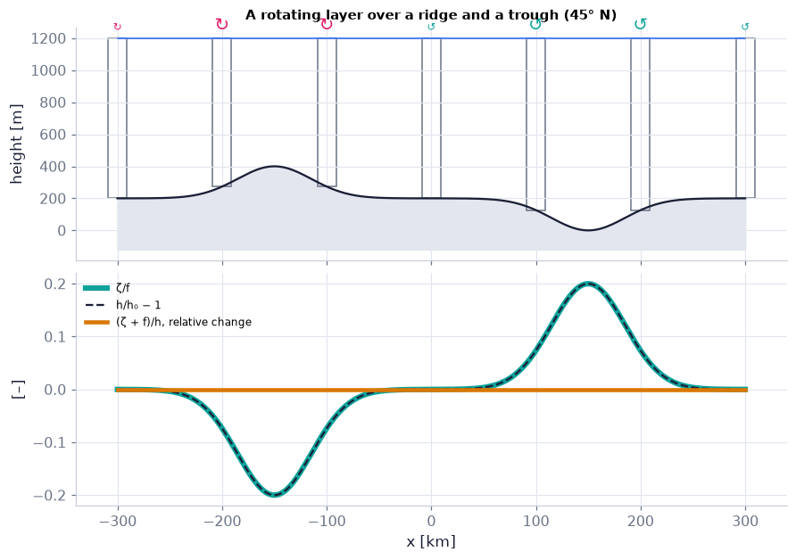

```python
xs_ = np.linspace(-3e5, 3e5, 241)                                    # distance along the path [m]
hf = lambda x: 1000 - 200*np.exp(-((x + 1.5e5)/5e4)**2) + 200*np.exp(-((x - 1.5e5)/5e4)**2)   # layer depth: ridge, then trough [m]
cs = ch05.column_over_slope(xs_, hf, 45.0)                           # ζ along the path at 45° N, starting at rest [1/s]
fig, (a, b) = plt.subplots(2, 1, figsize=(8, 5.6), sharex=True)      # the layer | the numbers
column_sketch(a, xs_/1e3, cs["h"], cs["zeta"], n_cols=7)             # columns with spin marks (teal ↺ cyclonic, rose ↻ anticyclonic)
a.set_xlabel(""); a.set_ylabel("height [m]"); a.set_title("A rotating layer over a ridge and a trough (45° N)", fontsize=10)
b.plot(xs_/1e3, cs["zeta"]/cs["f"], color=COLORS["teal"], lw=4, label="ζ/f")             # relative vorticity in units of f (wide)
b.plot(xs_/1e3, cs["h"]/1000.0 - 1, color=COLORS["ink"], ls="--", lw=1.5, label="h/h₀ − 1")  # depth change, dashed on top: identical
b.plot(xs_/1e3, cs["ratio"]/cs["ratio"][0] - 1, color=COLORS["amber"], lw=3, label="(ζ + f)/h, relative change")   # conserved
b.set_xlabel("x [km]"); b.set_ylabel("[–]"); b.legend(fontsize=8)
savefig(fig, "ch05", "column_ridge"); plt.show()                     # save the PNG to outputs/ch05, then draw
```

**What you see.** (Note `N54`, Fig. 5.10 analogue.) Top, a layer that thins over a ridge and deepens over a trough, with columns turning clockwise (rose) over the ridge and counterclockwise (teal) over the trough; bottom, the wide teal ζ/f with the dashed black h/h₀ − 1 lying exactly on it, and the amber (ζ + f)/h flat at zero change.

**How to read it.** (ζ + f)/h is carried unchanged by each column (D20): squashed columns lose absolute vorticity (anticyclonic), stretched ones gain it (cyclonic); ζ/f equals h/h₀ − 1 for a column that starts at rest.

**What would change if…** …the same layer at 10° N: f is 4.1 times smaller (sin 10° vs sin 45°), so every ζ is 4.1 times smaller — the equator has little planetary vorticity to lend.

```python
hh = np.linspace(800, 1200, 41)                                      # column height [m], h₀ = 1000 m
z45 = ch05.column_relative_vorticity(hh, 1000.0, 0.0, rotating.coriolis_parameter(np.deg2rad(45.0)))   # the 45° N reference


def lat(phi):                                                        # latitude [deg] → curves
    f = rotating.coriolis_parameter(np.deg2rad(phi))                 # f = 2Ω sin φ [1/s]
    return {"ζ(h) at this latitude": (hh, ch05.column_relative_vorticity(hh, 1000.0, 0.0, f)*1e5),   # [10⁻⁵ 1/s]
            "45° N reference": (hh, z45*1e5)}


fig = slider_figure(lat, "φ", np.linspace(-90, 90, 19 if not FAST else 10), unit="°", xlabel="column height h [m]",  # precompute every slider position
                    ylabel="relative vorticity ζ [10⁻⁵ 1/s]", title="The planet lends more spin toward the pole")
recolor(fig, {"ζ(h) at this latitude": COLORS["teal"], "45° N reference": COLORS["muted"]}, dashes={"45° N reference": "dash"})  # house colours by trace name
fig.show()                                                                                          # draw it (works on the web page too)
```

[interactive chart not shown]

**What you see.** A teal line through (1000 m, 0) whose slope grows with |φ|, flat at the equator and reversed in the Southern Hemisphere; the grey dashed line is 45° N.

**How to read it.** For a column starting at rest, ζ = f(h/h₀ − 1): the slope is f/h₀ = 2Ω sin φ/h₀. Stretching (h > h₀) gives ζ with the sign of f — cyclonic in either hemisphere.

**What would change if…** …the Southern Hemisphere (φ < 0): f < 0, the line tilts the other way — cyclones turn clockwise there.

#### 🎮 Interactive: What does a spinning planet add to the vorticity equation?

**Why interactive rather than a static figure:** dragging a column over a ridge, moving a ring of air in latitude and switching the scene of a term-bar budget of (5.30), $\frac{D\boldsymbol\omega}{Dt}=(\boldsymbol\omega+2\boldsymbol\Omega)\cdot\nabla\mathbf u+\frac1{\rho^2}\nabla\rho\times\nabla p+\nu\nabla^2\boldsymbol\omega$ shows the same conservation law — and the same equation — in three regimes that a single figure cannot hold at once.

The Derivation tab carries the ★★★ D15 and D14, D19, D20.

**What to try:**

- Column mode: drag h below h₀ and watch the column turn anticyclonic while (ζ + f)/h stays put.
- Ring mode: move the ring from 30° N to 60° N and read Γ = −4.19×10⁷ m²/s.
- Budget mode: switch scenes and watch which bar dominates.
- Southern Hemisphere preset: every sign flips.

```python
show_viz("ch05", "vorticity_equation_rotating")   # full-width explainer; ⤢ Full screen for more room
```

🎮 Interactive 7/9 What does a spinning planet add to the vorticity equation? Open alone ↗

[interactive chart not shown]

> ⚠️ **Common confusion:** "2ΩA is the planetary part." It is $2\boldsymbol\Omega\cdot\mathbf A_{vec}$ — only the component of Ω along the loop's normal counts. On the Earth, for a horizontal loop, that is fA = 2Ω sin φ A.

**What would change if…** …the layer were also stratified? The column would be a slab between two density surfaces and h its thickness: (ζ + f)/h becomes Ertel's potential vorticity (Ch. 13) — the same bookkeeping.

## 5.7 Interaction of Vortices

**What is this section about?** Idealise each vortex as a line vortex. A straight line vortex cannot move itself, but Helmholtz says it moves with the fluid — and the fluid at its position is moved by all the *other* vortices (Biot–Savart). That one rule makes like vortices orbit, opposite ones travel together, a vortex slide along a wall (its mirror image does the pushing) and smoke rings leap-frog.

### 🧩 Point vortices move each other: pairs and the centre of vorticity `C12`

*The question:* Two hurricanes that come within a thousand kilometres start to circle each other; two dimples made by a paddle stroke glide away side by side. A vortex cannot push itself — so how do vortices move?

*In one line:* $\frac{d\mathbf x_k}{dt}=\sum_{j\ne k}\frac{\Gamma_j}{2\pi}\frac{\mathbf e_z\times(\mathbf x_k-\mathbf x_j)}{\lvert\mathbf x_k-\mathbf x_j\rvert^2}$

#### The problem in plain words

Weather forecasters watch binary cyclones dance (the Fujiwhara effect); airport controllers space landing aircraft because each plane leaves a pair of vortices that sinks behind it; modellers of 2-D turbulence and of ocean eddies use swarms of point vortices. All of these rest on one simple rule.

#### The idea

```
real vortex (core with vorticity)  ~  line vortex of the same Gamma      (outside the core the flow is irrotational)
each vortex k moves with the velocity induced at x_k by all the OTHERS:  dx_k/dt = sum_{j != k} (Gamma_j/2pi) e_z x (x_k - x_j)/|x_k - x_j|^2
two alike     ->  orbit their centre of vorticity         two opposite  ->  translate together at Gamma/(2 pi h)
```

*Glosses used below.* **Superposition.** Outside the cores the flow is irrotational and (Ch. 6) obeys the linear Laplace equation, so the velocities of several vortices add. A **point vortex** is a line vortex seen in the plane: $u_\theta=\Gamma/2\pi r$ (5.2) around one point. **Lever rule.** The balance point of two weights w₁, w₂ a distance h apart is $h\,w_2/(w_1+w_2)$ from the first. **Circular motion.** A point turning at rate $\dot\theta$ at distance d from the centre moves at $d\,\dot\theta$.

> 📎 **Primer — systems of ODEs for interacting bodies and their invariants.** `P147` · N vortices give 2N coupled ODEs (each position's rate depends on all the others). `solve_ivp` integrates them as one state vector. Because the exact motion conserves some quantities — here the linear impulse ΣΓx, the angular impulse ΣΓ|x|² and the energy $H=-\frac1{2\pi}\sum_{j<k}\Gamma_j\Gamma_k\ln\lvert\mathbf x_j-\mathbf x_k\rvert$ (Kirchhoff's function) — watching them stay constant tells us the numerical solution is trustworthy.

```python
xv0 = np.array([[-0.5, 0.5], [0.0, 0.0]]); G = np.array([1.0, 1.0])   # two like vortices 1 m apart [m], Γ = 1 m²/s each
t = np.linspace(0, 20, 5)                                            # five output times [s]
X = ch05.point_vortex_evolve(xv0, G, t)                              # positions, shape (T, 2, M) [m]
print([round(ch05.point_vortex_invariants(Xk, G)['I'], 10) for Xk in X])   # ΣΓ|x|² = 0.5 m⁴/s every time
```

```
[0.5, 0.5, 0.5, 0.5, 0.5]
```

#### 🧮 Derivation — Two point vortices: the centre of vorticity, the orbit rate, and the translating pair `D21` (Eq. 5.2)

**What we want to show.** Predict how two line vortices move each other: where the pair turns, how fast, and why an opposite pair marches off in a straight line. The book gives V₁ and V₂; the rest is left to Exercise 5.18.

**Assumptions.** Ideal line vortices, no walls (all steps); Γ₁, Γ₂ counterclockwise positive (ω_z > 0 and Γ > 0 mean counterclockwise, as in the notation cell).

**The plan.**

1. Compute each vortex's velocity.
2. Show the separation is fixed, so the motion is a rigid rotation.
3. Find its centre and rate.
4. Take the opposite-pair limit.

**Tools we use** (each explained before this point): Line vortex (R03) · lever rule / centre of mass analogy (gloss) · circular motion speed = rate × radius (gloss).

**We start from**

$$ \begin{array}{l}u_\theta=\Gamma/2\pi r\ \text{(5.2) for each vortex, and Helmholtz 1: each vortex moves with the} \\ \text{velocity the *other* induces (a straight line vortex does not move itself)}\end{array} $$

*In words:* vortices are carried by the flow.

**Step 1 of 6 — Velocity of vortex 2 due to 1.**

$$ V_1=\frac{\Gamma_1}{2\pi h} $$

- *Why we can do this:* (5.2), $u_\theta=\frac{\Gamma}{2\pi r}$ at distance h, perpendicular to the joining line; for Γ₁ > 0 and 2 to the right of 1, it points up (Fig. 5.11).
- *In words:* Vortex 1 pushes vortex 2 sideways.

**Step 2 of 6 — Velocity of vortex 1 due to 2.**

$$ V_2=\frac{\Gamma_2}{2\pi h} $$

- *Why we can do this:* The same law; vortex 1 is to the left of 2, so the push points down.
- *In words:* Vortex 2 pushes vortex 1 the other way.

**Step 3 of 6 — Show the separation cannot change.**

$$ \frac{d}{dt}\lvert\mathbf x_2-\mathbf x_1\rvert^2=2(\mathbf x_2-\mathbf x_1)\cdot(\mathbf v_2-\mathbf v_1)=0 $$

- *Why we can do this:* Both velocities are perpendicular to x₂ − x₁. Fixed distance + perpendicular velocities = rigid rotation about a point G on the joining line.
- *In words:* The pair turns like a rigid dumbbell.

**Step 4 of 6 — Locate the fixed point G.**

$$ \frac{V_2}{h_1}=\frac{V_1}{h_2}\ \Rightarrow\ h_1=\frac{\Gamma_2\,h}{\Gamma_1+\Gamma_2} $$

- *Why we can do this:* Rigid rotation: speed = rate × distance from the centre; with h₁ + h₂ = h this is the lever rule. G is the centre of vorticity (Γ₁x₁ + Γ₂x₂)/(Γ₁ + Γ₂), fixed since ΣΓ_kx_k is conserved.
- *In words:* G sits nearer the stronger vortex.

**Step 5 of 6 — Find the rotation rate.**

$$ \dot\theta=\frac{V_1+V_2}{h}=\frac{\Gamma_1+\Gamma_2}{2\pi h^2} $$

- *Why we can do this:* The relative speed of the two vortices, V₁ + V₂, divided by their distance is the angular rate of the joining line.
- *In words:* Stronger or closer vortices orbit faster.

**Step 6 of 6 — Take the opposite pair.**

$$ \Gamma_2=-\Gamma_1:\ \ h_1\to\infty,\ \dot\theta=0,\ V=\frac{\Gamma}{2\pi h} $$

- *Why we can do this:* With Γ₁ + Γ₂ = 0 the centre goes to infinity; both velocities are equal and parallel, so the pair translates without turning.
- *In words:* An opposite pair marches off together.

**Result**

$$ \begin{array}{l}\text{Centre of vorticity at}\ h_1=\Gamma_2h/(\Gamma_1+\Gamma_2)\ \text{from vortex 1, orbit rate}\ (\Gamma_1+\Gamma_2)/2\pi h^2\ \text{; an} \\ \text{opposite pair translates at}\ \Gamma/2\pi h\end{array} $$

*In words:* like vortices orbit their centre of vorticity; opposite ones travel together.

**What it means.** Binary cyclones orbit each other (Fujiwhara); aircraft wake vortex pairs descend together (Ch. 14); every point-vortex model rests on this.

**Check it.** Units: m²/s/m² = rad/s ✓. Equal strengths: G at the midpoint, period 19.74 s for Γ = 1 m²/s, h = 1 m; the numerical integration (`point_vortex_evolve`, the code cell after the tiny example below) finds the same period and keeps ΣΓx, ΣΓ|x|² and H flat to 1e-10 (the cell prints all three spreads) ✓. ⚠️ **The caption of Fig. 5.11 says G is "where the combined velocity induced by the two vortices is zero" — true only for Γ₁ = Γ₂.** For Γ₂ = 3Γ₁ the fluid at G (same cell) moves at 1/(2π·0.75) − 3/(2π·0.25) = −1.70 m/s; G is the fixed centre of the motion, not a stagnation point of the fluid.

> ⚠️ **Common confusion (traps in `D21`):** Letting a vortex push itself. Mistaking the centre of vorticity for a point of zero fluid velocity (the caption's slip). Putting G nearer the weaker vortex.

📝 **Note.** **Two like vortices (Fig. 5.11)** `N40` — Γ₁, Γ₂ > 0 a distance h apart push each other sideways at the speeds below, in opposite directions, so the pair turns about its centre of vorticity G, at $h_1=\Gamma_2h/(\Gamma_1+\Gamma_2)$ from vortex 1, at the rate $(\Gamma_1+\Gamma_2)/2\pi h^2$ (D21; the book leaves G to Exercise 5.18). **Numbers:** Γ₁ = Γ₂ = 1 m²/s, h = 1 m → each moves at 0.159 m/s, period 19.7 s; Γ₂ = 3Γ₁ → G is ¾h from vortex 1. ⚠️ The caption of Fig. 5.11 calls G the point where the induced velocity is zero — true only for equal strengths.

$$ V_1=\Gamma_1/2\pi h,\qquad V_2=\Gamma_2/2\pi h $$

📝 **Note.** **Equal and opposite pair (Figs. 5.12–5.13)** `N41` — each moves the other at Γ/2πh in the same direction, so the pair translates at the speed below relative to the fluid — made by a paddle stroke or a knife blade drawn briefly through a bucket (Lighthill's picture, our simulation in C13). The wake of an aircraft is such a pair, sinking behind it (Ch. 14).

$$ V=\Gamma/(2\pi h) $$

#### ✏️ Tiny example: two like vortices, then two opposite

1. Γ₁ = Γ₂ = 1 m²/s at (−0.5, 0) and (0.5, 0) m: vortex 2 is pushed up at $1/(2\pi\times1)$ = 0.159 m/s, vortex 1 down at 0.159 m/s; G is the midpoint; the joining line turns at (0.159 + 0.159)/1 = 0.318 rad/s — one orbit in 2π/0.318 = 19.7 s.
2. Γ₂ = 3 m²/s instead: V₁ = 0.159, V₂ = 0.477 m/s; G at 0.75 m from vortex 1 (the lever rule with weights 1 and 3); rate $(1+3)/2\pi$ = 0.637 rad/s.
3. Γ₂ = −1 m²/s: both move up at 0.159 m/s — a straight march.

```python
for G2 in (1.0, 3.0, -1.0):                                           # the three cases of the example
    vp = ch05.vortex_pair(1.0, G2, 1.0)                               # D21's closed forms, h = 1 m
    print(G2, {k: round(v, 6) for k, v in vp.items()})
Pq = ch05.point_vortex_preset("equal_pair"); t = np.linspace(0, ch05.vortex_pair(1.0, 1.0, 1.0)["period"], 200)   # one predicted period, 2π/rate
Xe = ch05.point_vortex_evolve(Pq["xv"], Pq["Gamma"], t)               # the full integration [m]
print(f"back at the start after one period: {np.abs(Xe[-1] - Xe[0]).max():.1e} m")
inv = [ch05.point_vortex_invariants(Xk, Pq["Gamma"]) for Xk in Xe]    # invariants along the run
print(f"spread of P = ΣΓx: {np.ptp([v['P'] for v in inv], axis=0).max():.1e}, of I = ΣΓ|x|²: {np.ptp([v['I'] for v in inv]):.1e},  of H: {np.ptp([v['H'] for v in inv]):.1e}")   # all flat
xv_u, G_u = ch05.point_vortex_preset("unequal_pair")["xv"], np.array([1.0, 3.0])   # Γ₂ = 3Γ₁
Gc = ch05.centre_of_vorticity(xv_u, G_u); print("centre of vorticity:", Gc)   # (0.25, 0): ¾ of the way from −0.5 to 0.5
print("fluid velocity AT G:", ch05.point_vortex_velocity(Gc, xv_u, G_u))      # (0, −1.70) m/s: G is not a point of rest
```

```
1.0 {'V1': 0.159155, 'V2': 0.159155, 'centre_from_1': 0.5, 'rotation_rate': 0.31831, 'period': 19.739209, 'translation_speed': 0.0}
3.0 {'V1': 0.159155, 'V2': 0.477465, 'centre_from_1': 0.75, 'rotation_rate': 0.63662, 'period': 9.869604, 'translation_speed': 0.0}
-1.0 {'V1': 0.159155, 'V2': -0.159155, 'centre_from_1': inf, 'rotation_rate': 0.0, 'period': inf, 'translation_speed': 0.159155}
back at the start after one period: 2.0e-11 m
spread of P = ΣΓx: 0.0e+00, of I = ΣΓ|x|²: 5.0e-11,  of H: 7.9e-12
centre of vorticity: [0.25 0.  ]
fluid velocity AT G: [-0.     -1.6977]
```

**What does the code above do?**

1. The closed forms of D21: equal pair V = 0.159155 m/s, centre 0.5 m, rate 0.318310 rad/s, period 19.739 s; unequal pair centre 0.75 m, rate 0.636620 rad/s, period 9.870 s; opposite pair: centre at infinity, no rotation, translation 0.159155 m/s.
2. The full point-vortex integration returns to its start after the predicted period.
3. The invariants stay flat — the integrator is trustworthy.
4. The centre of vorticity of the unequal pair, and the fluid velocity there: −1.70 m/s — the pair turns about G, yet the fluid at G is not at rest (the Fig. 5.11 caption's slip).

**From scratch — $d\mathbf x_k/dt$ by a double loop over pairs** ($\mathbf e_z\times(a,b)=(-b,a)$: each pair of vortices, one line):

```python
P3v = ch05.point_vortex_preset("three_vortices"); xv, Gm = P3v["xv"], P3v["Gamma"]   # three vortices, Γ = (1, 1, −0.5)
M = xv.shape[1]                                                      # number of vortices
v = np.zeros((2, M))                                                 # their velocities [m/s]
for k in range(M):                                                   # the vortex being moved
    for j in range(M):                                               # every other vortex pushes it
        if j != k:
            d = xv[:, k] - xv[:, j]                                  # x_k − x_j [m]
            v[:, k] += Gm[j]/(2*np.pi)*np.array([-d[1], d[0]])/(d @ d)   # (Γ_j/2π) e_z × d/|d|²
print(v)
assert np.allclose(v, ch05.point_vortex_rhs(xv, Gm), atol=1e-14)     # = the library
```

```
[[-0.0872 -0.0563 -0.2871]
 [-0.1265  0.1099 -0.0332]]
```

**Pairs in motion (Figs. 5.11–5.12 analogues, notes `N55`, `N56`):** left, the equal pair orbiting G (black cross); middle, Γ₂ = 3Γ₁ orbiting its off-centre G; right, the opposite pair (teal +, rose −) marching up.

```python
nf = 30 if not FAST else 16                                          # frames
tf = np.linspace(0, 19.7392, nf)                                     # one period of the equal pair [s]
runs = []                                                            # (positions, strengths, centre) for each panel
for name in ("equal_pair", "unequal_pair", "opposite_pair"):                                        # the three panels
    pr = ch05.point_vortex_preset(name)                              # positions and strengths
    runs.append((ch05.point_vortex_evolve(pr["xv"], pr["Gamma"], tf), pr["Gamma"], ch05.centre_of_vorticity(pr["xv"], pr["Gamma"])))  # positions over one period, strengths, centre of vorticity
with plt.rc_context(ANIM_RC):                                         # light settings for fast frames
    fig, axs = plt.subplots(1, 3, figsize=(10.5, 3.8), dpi=80)                                      # three panels
fig.subplots_adjust(left=0.05, right=0.98, bottom=0.1, top=0.85, wspace=0.25)   # fixed margins
dots, trails = [], []                                                # artists updated per frame
for a, (X, Gm, Gc), ttl in zip(axs, runs, ["Γ₂ = Γ₁: orbit G", "Γ₂ = 3Γ₁: orbit G", "Γ₂ = −Γ₁: march"]):  # set up each panel
    a.set_xlim(-1.0, 1.0); a.set_ylim(-1.0 if ttl != "Γ₂ = −Γ₁: march" else -0.3, 1.0 if ttl != "Γ₂ = −Γ₁: march" else 3.4)  # fixed limits (the marching pair needs more room upward) [m]
    a.set_aspect("equal"); a.locator_params(nbins=4); a.set_title(ttl, fontsize=10)
    if a is not axs[0]:                                              # ticks on the first panel only (fewer labels to draw per frame)
        a.set_xticks([]); a.set_yticks([])                 # equal axes, few ticks, a title
    if np.all(np.isfinite(Gc)):                                                                     # the opposite pair has no finite centre
        a.plot(*Gc, "x", color=COLORS["ink"], ms=10, mew=2)          # the centre of vorticity (fixed)
    cols = [COLORS["teal"] if g > 0 else COLORS["rose"] for g in Gm]                                # teal counterclockwise, rose clockwise
    trails.append([a.plot([], [], color=c, lw=1, alpha=0.6)[0] for c in cols])                      # empty trail lines, filled in update()
    dots.append(a.scatter(X[0, 0], X[0, 1], c=cols, s=60, zorder=3))                                # the vortices at t = 0


def update(i):                                                       # draw frame i
    for (X, Gm, Gc), dt_, tr in zip(runs, dots, trails):                                            # each panel
        dt_.set_offsets(X[i].T)                                      # vortex positions now
        for m, line in enumerate(tr):                                                               # each vortex's trail
            line.set_data(X[:i + 1, 0, m], X[:i + 1, 1, m])          # their trails
    fig.suptitle(f"t = {tf[i]:.1f} s", fontsize=10)                                                 # the clock
    return dots                                                                                     # the artists that changed


with plt.rc_context(ANIM_RC):                                         # render the frames with the light settings
    show_animation(animate(update, frames=nf, fig=fig, interval=150), player="video")   # smooth movie
```

[video not shown]

**What you see.** Two circles of equal size round a fixed cross; two circles of different sizes round a cross nearer the stronger vortex; a teal–rose pair moving straight up.

**How to read it.** Every vortex is carried by the others: like ones orbit their centre of vorticity (which never moves), opposite ones travel together at Γ/2πh. The equal pair completes exactly one orbit in the 19.74 s shown; the unequal pair two.

**What would change if…** …h halved: the orbits are four times faster ((Γ₁ + Γ₂)/2πh²) and the march twice as fast (Γ/2πh).

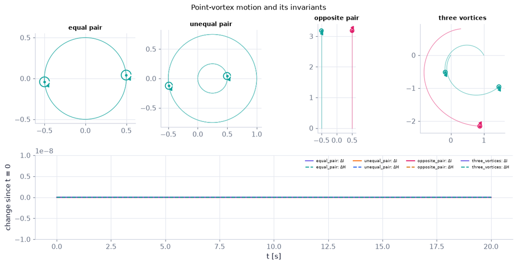

```python
tl = np.linspace(0, 20, 401 if not FAST else 201)                     # 20 s [s]
names = ["equal_pair", "unequal_pair", "opposite_pair", "three_vortices"]   # four presets
fig = plt.figure(figsize=(11, 5.6)); gs = fig.add_gridspec(2, 4, height_ratios=[1.3, 1])   # 4 trajectory panels + 1 invariant panel
axi = fig.add_subplot(gs[1, :])                                       # the invariants
for k, nm in enumerate(names):
    pr = ch05.point_vortex_preset(nm); X = ch05.point_vortex_evolve(pr["xv"], pr["Gamma"], tl)   # run 20 s
    a = fig.add_subplot(gs[0, k])
    vortex_marks(a, X[-1], pr["Gamma"], size=0.06, trails=X)          # trails and the final positions (teal +, rose −)
    a.set_title(nm.replace("_", " "), fontsize=9); a.locator_params(nbins=4)
    inv = [ch05.point_vortex_invariants(Xk, pr["Gamma"]) for Xk in X]
    I = np.array([v["I"] for v in inv]); H = np.array([v["H"] for v in inv])
    axi.plot(tl, I - I[0], label=f"{nm}: ΔI", lw=1.5)                 # angular impulse change
    axi.plot(tl, H - H[0], ls="--", lw=1.5, label=f"{nm}: ΔH")        # energy change
axi.set_xlabel("t [s]"); axi.set_ylabel("change since t = 0"); axi.set_ylim(-1e-8, 1e-8); axi.legend(fontsize=6, ncol=4)
fig.suptitle("Point-vortex motion and its invariants", fontsize=11)
plt.show()
```

**What you see.** Top: the equal pair's single circle, the unequal pair's two circles of different radius, the opposite pair's straight tracks and the three vortices' tangled paths. Bottom: every invariant's change stays inside ±10⁻⁸ (most lines lie on zero).

**How to read it.** Like vortices orbit, opposite ones march, three can wander in complicated ways — but ΣΓ|x|² (I) and the energy H never change, which is how we know the integration is right. (The opposite pair has ΣΓ = 0, so its I is not tied to a fixed centre, yet it is still conserved.)

**What would change if…** …a fourth vortex added: the motion can become chaotic, but the invariants stay flat.

**What would change if…** …one of the two vortices were replaced by a wall? The wall acts like a mirror vortex of opposite sign — the pair becomes a vortex and its image (C13).

### 🧩 Images: a vortex drifts along a wall `C13`

*The question:* A vortex near the bottom of a tank slides sideways along it; a smoke ring blown at a wall grows wider as it slows. How does a wall push a vortex without touching it?

*In one line:* the wall is replaced by a mirror vortex of opposite sign at distance 2h, so the vortex drifts along the wall at $V_A=\Gamma/4\pi h$.

#### The problem in plain words

A wall forbids flow through it. For vortices this boundary condition has a beautiful solution: pretend the wall is a mirror and put an opposite vortex behind it. The mirror twin then moves the real vortex — and the same trick handles circular tanks, channels, the ground under a landing aircraft (Ch. 14) and cylinders in a stream (Ch. 6).

#### The idea

```
     vortex A (+Gamma) o                       wall = the line where A's push and its twin's push have
-------------------------- wall                 equal and opposite normal parts  ->  no flow through it
     image B (-Gamma)  o                       A is moved only by B (distance 2h): V = Gamma/(2 pi 2h) = Gamma/(4 pi h), along the wall
```

*Gloss — mirror symmetry.* Reflect a counterclockwise vortex in the wall and reverse its spin: at every wall point the two velocity vectors are mirror images, so their normal parts cancel and their tangential parts add (the method of images).

#### 🧮 Derivation — A vortex near a wall: its image, u·n = 0 on the wall, and the drift Γ/4πh `D22` (Eq. 5.2)

**What we want to show.** Show that a mirror vortex of opposite sign makes a plane wall a streamline, and find how fast the real vortex slides along the wall.

**Assumptions.** Inviscid (slip allowed along the wall, step 3); infinite plane wall (step 1).

**The plan.**

1. Replace the wall by an image.
2. Check the wall condition by symmetry.
3. Compute A's velocity.

**Tools we use** (each explained before this point): Mirror symmetry of a vortex and its opposite image (gloss) · line vortex (R03) · superposition (gloss).

**We start from**

$$ \begin{array}{l}\text{Vortex A of strength Γ at distance h from the wall y = 0, and the inviscid} \\ \text{wall condition v = 0 at y = 0}\end{array} $$

*In words:* no fluid may cross the wall.

**Step 1 of 5 — Place an opposite image behind the wall.**

$$ \text{B}:\ -\Gamma\ \text{at}\ (x_A,-h) $$

- *Why we can do this:* Method of images: in the region y > 0 the pair A + B is an ideal flow; if it satisfies the wall condition it is the answer (uniqueness).
- *In words:* Imagine a mirror twin spinning the other way.

**Step 2 of 5 — Compare the two pushes at a wall point.**

$$ r_A=r_B\ \Rightarrow\ \lvert\mathbf V_A\rvert=\lvert\mathbf V_B\rvert=\frac{\Gamma}{2\pi r} $$

- *Why we can do this:* Every wall point P is equidistant from A and B (mirror images).
- *In words:* Both vortices push equally hard at the wall.

**Step 3 of 5 — Show the normal parts cancel.**

$$ v_A+v_B=0\ \text{on}\ y=0 $$

- *Why we can do this:* Mirror symmetry: the opposite spin reflects the normal component and keeps the tangential one (gloss; Fig. 5.14's 90° construction).
- *In words:* The wall is a streamline; fluid only slides along it.

**Step 4 of 5 — Give A the image's velocity.**

$$ V_A=\frac{\Gamma}{2\pi(2h)} $$

- *Why we can do this:* A does not move itself (Helmholtz 1); only B, at distance 2h, moves it.
- *In words:* The mirror twin drags the vortex.

**Step 5 of 5 — Simplify and read the direction.**

$$ V_A=\frac{\Gamma}{4\pi h}\ \ \text{parallel to the wall} $$

- *Why we can do this:* 2π·2h = 4πh; the image's push at A is perpendicular to AB, i.e. along the wall (for Γ > 0 above the wall: +x).
- *In words:* A vortex slides along a wall at Γ/4πh.

**Result**

$$ V_A=\frac{\Gamma}{4\pi h}\ \text{parallel to the wall} $$

*In words:* a wall acts like an opposite vortex behind it; the vortex slides along the wall, faster the closer it is.

**What it means.** Why the knife-blade pair separates along the bucket wall (Fig. 5.13), why a smoke ring widens near a wall (N42), and ground effect for wing-tip vortices (Ch. 14). Images enforce only no penetration — real walls also make boundary layers (Ch. 9).

**Check it.** Units m/s ✓. `wall_image_system` (the code cell after the tiny example below): v = 0 at 201 wall points to 1e-12 ✓. Channel of height H: (Γ/4H)cot(πh/H) → Γ/4πh as h → 0 and 0 at h = H/2 (the same cell prints both h = H/4 and h = H/2) ✓.

> ⚠️ **Common confusion (traps in `D22`):** Using a same-sign image (the wall would be crossed). Using distance h instead of 2h.

#### ✏️ Tiny example: a vortex half a metre above the floor

Γ = 1 m²/s at height h = 0.5 m.

1. Image: −1 m²/s at −0.5 m.
2. At the wall point directly below, both vortices are 0.5 m away; each gives $1/(2\pi\times0.5)$ = 0.318 m/s, both horizontal and in the same direction: 0.637 m/s along the floor, 0 through it.
3. At the wall point 0.5 m to the side, distance √0.5 = 0.707 m: each gives 0.225 m/s at 45°; the vertical parts cancel, the horizontal ones add to 0.318 m/s.
4. The vortex itself moves at $1/(4\pi\times0.5)$ = 0.159 m/s along the wall.
5. In a channel 1 m high with the vortex at 0.25 m, all the images add up to $(\Gamma/4H)\cot(\pi h/H)$ = 0.25 m/s — slower than the single-wall 0.318 m/s, because the ceiling's images push back.

```python
xa, Ga = ch05.wall_image_system(np.array([[0.0], [0.5]]), np.array([1.0]))   # the vortex and its image
xw = np.array([np.linspace(-3, 3, 201), np.zeros(201)])               # 201 points on the wall y = 0 (x = 0 among them) [m]
vel = ch05.point_vortex_velocity(xw, xa, Ga)                          # velocity there [m/s]
print(f"largest |v| through the wall: {np.abs(vel[1]).max():.1e} m/s; u below the vortex: {vel[0][100]:.4f} m/s")   # 0; 0.6366
print(ch05.vortex_near_wall_speed(1.0, 0.5), ch05.point_vortex_rhs(np.array([[0.0], [0.5]]), np.array([1.0]), boundary="wall").ravel())   # drift 0.159155
print(ch05.channel_image_velocity(0.25, 1.0, 1.0), 1/(4*1.0)/np.tan(np.pi*0.25))   # channel: image series vs (Γ/4H)cot(πh/H)
print(f"mid-channel, h = H/2: {ch05.channel_image_velocity(0.5, 1.0, 1.0):.1e} m/s")   # 0: the two walls' images cancel
```

```
largest |v| through the wall: 0.0e+00 m/s; u below the vortex: 0.6366 m/s
0.15915494309189535 [0.1592 0.    ]
0.25 0.25000000000000006
mid-channel, h = H/2: 0.0e+00 m/s
```

**What does the code above do?**

1. The vortex and its image (opposite strength, mirrored position).
2. The velocity at 201 wall points has no normal part (0 to round-off) — the wall is a streamline; directly below the vortex it slides at 0.6366 m/s.
3. The vortex's own drift, from the image only: Γ/4πh = 0.159155 m/s along +x.
4. The channel's infinite image series (summed until the next term is below 10⁻¹²) equals its closed form, 0.25 m/s.

**From scratch — the image sum by hand**, at the vortex and at one wall point:

```python
d = np.array([0.0, 0.5]) - np.array([0.0, -0.5])                     # vortex A minus image B [m]
vA = -1.0/(2*np.pi)*np.array([-d[1], d[0]])/(d @ d)                  # B (Γ = −1) pushes A: (Γ_B/2π) e_z × d/|d|²
print(vA)                                                            # (0.159155, 0): along the wall
assert np.allclose(vA, [1/(4*np.pi*0.5), 0.0])                       # = Γ/4πh
P_w = np.array([1.0, 0.0])                                           # a wall point [m]
dA_, dB_ = P_w - np.array([0.0, 0.5]), P_w - np.array([0.0, -0.5])   # from A and from B to the wall point
vAw = 1.0/(2*np.pi)*np.array([-dA_[1], dA_[0]])/(dA_ @ dA_)          # A's push there
vBw = -1.0/(2*np.pi)*np.array([-dB_[1], dB_[0]])/(dB_ @ dB_)         # B's push there
assert abs(vAw[1] + vBw[1]) < 1e-15                                  # normal parts cancel
```

```
[ 0.1592 -0.    ]
```

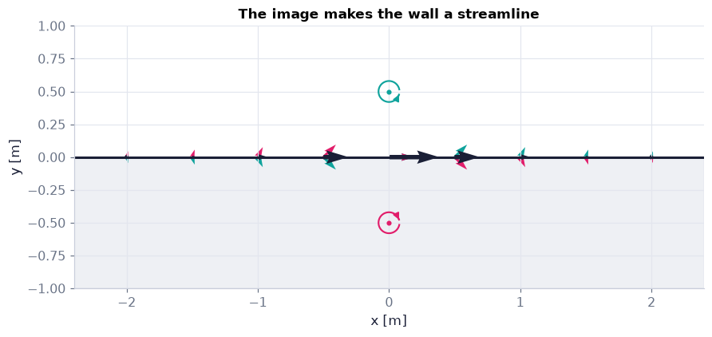

```python
xs9 = np.linspace(-2, 2, 9)                                          # 9 wall points [m]
Pw = np.array([xs9, 0*xs9])                                          # on y = 0
vA_ = ch05.point_vortex_velocity(Pw, np.array([[0.0], [0.5]]), np.array([1.0]))    # A's pushes [m/s]
vB_ = ch05.point_vortex_velocity(Pw, np.array([[0.0], [-0.5]]), np.array([-1.0]))  # the image's pushes [m/s]
fig, ax = plt.subplots(figsize=(8, 3.8))
ax.axhline(0, color=COLORS["ink"], lw=2)                             # the wall
ax.axhspan(-1.0, 0, color=COLORS["grid"], alpha=0.6)                 # behind the wall (the mirror world)
vortex_marks(ax, np.array([[0.0], [0.5]]), [1.0], size=0.08)         # A, teal (counterclockwise)
vortex_marks(ax, np.array([[0.0], [-0.5]]), [-1.0], size=0.08)       # B, rose (clockwise), behind the wall
s_ = 0.6                                                             # arrow scale [m per m/s]
ax.quiver(xs9, 0*xs9, vA_[0], vA_[1], color=COLORS["teal"], angles="xy", scale_units="xy", scale=1/s_, width=0.004)   # from A
ax.quiver(xs9, 0*xs9, vB_[0], vB_[1], color=COLORS["rose"], angles="xy", scale_units="xy", scale=1/s_, width=0.004)   # from B
ax.quiver(xs9, 0*xs9, vA_[0] + vB_[0], vA_[1] + vB_[1], color=COLORS["ink"], angles="xy", scale_units="xy", scale=1/s_, width=0.007)   # sum
ax.set_xlim(-2.4, 2.4); ax.set_ylim(-1.0, 1.0); ax.set_aspect("equal"); ax.set_xlabel("x [m]"); ax.set_ylabel("y [m]")
ax.set_title("The image makes the wall a streamline", fontsize=11)
savefig(fig, "ch05", "wall_image"); plt.show()                       # save the PNG to outputs/ch05, then draw
```

**What you see.** (Note `N58`, Fig. 5.14 analogue.) The teal vortex A above the wall, its rose image B below (in the grey mirror world); at nine wall points a thin teal arrow (A's push), a thin rose arrow (B's push) and a thick black arrow (their sum) that lies flat along the wall, longest under the vortex.

**How to read it.** The image makes the wall a streamline; the black arrows are the slip velocity an inviscid fluid is allowed along a wall (a real, viscous fluid brings it to rest in a boundary layer, Ch. 9).

**What would change if…** …an image of the same sign: the vertical parts would add instead of cancel — the black arrows would cross the wall, so it would no longer be a wall.

📝 **Note.** **The knife-blade pair in a bucket (Fig. 5.13, after Lighthill)** `N57` — A knife drawn briefly through a bucket leaves an opposite pair that marches off; nearing the wall the two vortices separate and run along it in opposite directions, each pushed by its own image. For a circle of radius a the image of a vortex at x is at the inverse point $a^2\mathbf x/\lvert\mathbf x\rvert^2$ (measured from the centre, strength −Γ) — below, our simulation.

```python
PK = ch05.point_vortex_preset("knife_bucket")                        # Γ = (−1, +1) at y = ±0.15 m; circle a = 1 m about (0.3, 0)
nf = 30 if not FAST else 16                                          # frames
tk = np.linspace(0, PK["t_end"], nf)                                 # 0 … 12 s
XK = ch05.point_vortex_evolve(PK["xv"], PK["Gamma"], tk, boundary=PK["boundary"], **PK["bp"])   # with circle images [m]
cx, cy = PK["bp"]["center"]; ac = PK["bp"]["a"]                      # the bucket's centre and radius [m]
with plt.rc_context(ANIM_RC):                                         # light settings for fast frames
    fig, ax = plt.subplots(figsize=(5.6, 5.0), dpi=80)
fig.subplots_adjust(left=0.08, right=0.97, bottom=0.08, top=0.9)     # fixed margins
th = np.linspace(0, 2*np.pi, 200); ax.plot(cx + ac*np.cos(th), cy + ac*np.sin(th), color=COLORS["ink"], lw=2)   # the bucket wall
cols = [COLORS["teal"] if g > 0 else COLORS["rose"] for g in PK["Gamma"]]
trl = [ax.plot([], [], color=c, lw=1.2)[0] for c in cols]             # trails
vd = ax.scatter(XK[0, 0], XK[0, 1], c=cols, s=60, zorder=3)           # the two vortices
im = ax.scatter([], [], c=[], s=30, alpha=0.35)                       # their images, outside the circle
ax.set_xlim(cx - 2.2, cx + 2.2); ax.set_ylim(-2.2, 2.2); ax.set_aspect("equal"); ax.locator_params(nbins=5)


def update(i):                                                       # draw frame i
    vd.set_offsets(XK[i].T)                                          # the vortices now
    for m, line in enumerate(trl):
        line.set_data(XK[:i + 1, 0, m], XK[:i + 1, 1, m])            # their trails
    xa_, Ga_ = ch05.circle_image_system(XK[i], PK["Gamma"], ac, center=(cx, cy), inside=True)   # vortices + images
    im.set_offsets(xa_[:, 2:].T); im.set_color([COLORS["teal"] if g > 0 else COLORS["rose"] for g in Ga_[2:]])   # images faint
    ax.set_title(f"knife-blade pair in a bucket, t = {tk[i]:.1f} s", fontsize=10)
    return vd, im


with plt.rc_context(ANIM_RC):                                         # render the frames with the light settings
    show_animation(animate(update, frames=nf, fig=fig, interval=150), player="video")   # smooth movie
```

[video not shown]

**What you see.** The pair crosses the bucket toward the left, splits at the wall and the two vortices run round it in opposite directions; their faint images move outside the circle, mirroring them.

**How to read it.** Far from the wall the pair translates at Γ/2πh (C12); near it each vortex is dragged by its own image — the wall drift of D22.

**What would change if…** …a stronger stroke (larger Γ): the same paths, travelled faster.

📝 **Note.** **A smoke ring meeting a wall (Fig. 5.15)** `N42` — A ring moves itself (its own curvature, the thin-core self-speed below — Kelvin's formula, which we cite) and is moved by its image ring behind the wall. The image pushes it outward and holds it back: the ring **widens** and **slows** as it approaches, never reaching the wall. We compute the path with the velocity one circular filament induces at another (elliptic integrals — primer below) and the self-speed. **Number:** Γ = 1 m²/s, R = 1 m, core a = 0.1 m: U = 0.329 m/s. ⚠️ This is a **qualitative model**: thin cores that keep their circular shape and their volume a²R; it stops being trustworthy once the gap to the wall shrinks to a few core radii — `ring_dynamics` stops it when the gap falls below three core radii (its `valid` mask and `stop_time`), because a core that close to its image is no longer thin and circular.

$$ U=\frac{\Gamma}{4\pi R}\Big[\ln\frac{8R}{a}-\frac14\Big] $$

> 📎 **Primer — complete elliptic integrals with the parameter m.** `P148` · The velocity induced by a circular filament involves $K(m)=\int_0^{\pi/2}d\theta/\sqrt{1-m\sin^2\theta}$ and $E(m)=\int_0^{\pi/2}\sqrt{1-m\sin^2\theta}\,d\theta$. ⚠️ `scipy.special.ellipk(m)` and `ellipe(m)` take the **parameter m = k²**, not the modulus k — passing k is a classic silent bug (K → ∞ as m → 1: a point near the filament).

```python
from scipy.special import ellipk, ellipe                  # complete elliptic integrals K(m), E(m)
from scipy.integrate import quad                          # to check the definition
m = 0.5                                                   # the parameter m = k²
K = quad(lambda th: 1/np.sqrt(1 - m*np.sin(th)**2), 0, np.pi/2)[0]   # K(m) from its definition
print(ellipk(m), K)                                       # 1.854075 1.854075: same definition
print(ellipk(0.5**0.5))                                   # 2.085974 — what you get by passing k instead of m
```

```
1.8540746773013719 1.854074677301372
2.0859736981949366
```

> 🔁 **Tools from earlier chapters used here** (see `knowledge/primers.md`)
- **np.gradient** — `np.gradient(z, t)` differentiates sampled data by central differences (one-sided at the ends) (Ch. 1 P22).

```python
print(ch05.ring_self_velocity(1.0, 0.1, 1.0))                        # Kelvin's self-speed: R = 1 m, a = 0.1 m, Γ = 1 m²/s → 0.328816 m/s
print(ch05.ring_ring_velocity(0.0, 0.5, 0.5, 0.0, 1.0), ch05.ring_axis_velocity(0.5, 0.5, 1.0))   # on the axis: elliptic formula = closed form
tw = np.linspace(0, 3.5, 141 if not FAST else 71)                    # 3.5 s of the approach [s]
res = ch05.ring_dynamics([dict(R=0.5, z=0.0, Gamma=1.0, a=0.05)], tw, wall_z=2.0)   # Γ > 0 moves toward +z: a wall at z = 2 m
ok = res["valid"]                                                    # samples where the thin-core model still applies
tv, Rr, zr = tw[ok], res["R"][ok, 0], res["z"][ok, 0]                 # time, radius and height of the ring [s], [m]
a_end = res["a"][ok, 0][-1]                                          # the core has thinned as the ring widened (volume a²R fixed) [m]
print(f"model stops at t = {res['stop_time']:.3f} s ({res['stop_reason']}: gap below 3 core radii, 3a = {3*a_end:.3f} m by then)")
for k in (0, len(tv)//3, 2*len(tv)//3, -1):
    print(f"t = {tv[k]:.2f} s: R = {Rr[k]:.4f} m, z = {zr[k]:.4f} m, gap to the wall {2.0 - zr[k]:.4f} m")
vz = np.gradient(zr, tv)                                             # approach speed [m/s]
print("R grows monotonically:", bool(np.all(np.diff(Rr) > 0)), "| approach speed falls monotonically:", bool(np.all(np.diff(vz) < 0)))
```

```
0.3288162319478587
(0.0, 0.35355339059327373) 0.35355339059327373
model stops at t = 3.117 s (wall: gap below 3 core radii, 3a = 0.131 m by then)
t = 0.00 s: R = 0.5000 m, z = 0.0000 m, gap to the wall 2.0000 m
t = 1.03 s: R = 0.5008 m, z = 0.6704 m, gap to the wall 1.3296 m
t = 2.08 s: R = 0.5073 m, z = 1.3430 m, gap to the wall 0.6570 m
t = 3.10 s: R = 0.6596 m, z = 1.8650 m, gap to the wall 0.1350 m
R grows monotonically: True | approach speed falls monotonically: True
```

**What does the code above do?**

1. Kelvin's self-speed of a thin ring, Γ/(4πR)[ln(8R/a) − ¼] = 0.328816 m/s.
2. The velocity a ring induces on its own axis, from the elliptic-integral formula: u_R = 0, u_z = 0.353553 m/s — the closed form ΓR²/2(R² + z²)^{3/2} of C08.
3. A ring (R = 0.5 m, a = 5 cm) launched at a wall 2 m away: it travels at ≈ 0.66 m/s at first, then widens from 0.5 m to about 0.66 m while its approach speed falls — Fig. 5.15b in numbers. At t ≈ 3.12 s the gap is down to three core radii and the model stops: a core that close to its image is squeezed out of shape, which the thin-core formulas ignore (continued blindly, they would let R grow without bound).

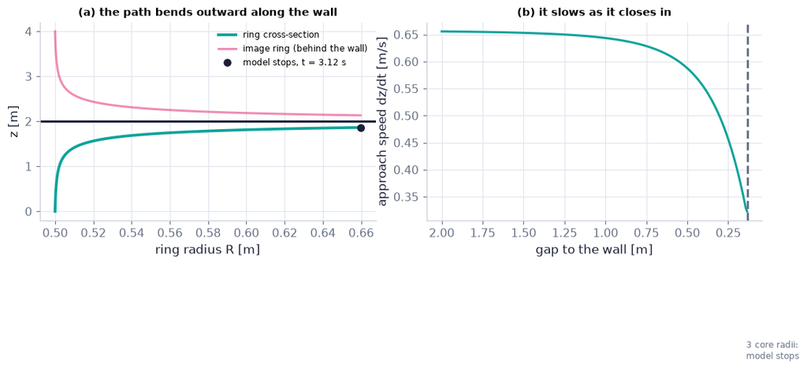

```python
fig, (a, b) = plt.subplots(1, 2, figsize=(10, 3.8))                  # path in the (R, z) plane | speed vs gap
a.plot(Rr, zr, color=COLORS["teal"], lw=2.5, label="ring cross-section")        # the real ring (valid samples only)
a.plot(Rr, 4.0 - zr, color=COLORS["rose"], lw=2, alpha=0.5, label="image ring (behind the wall)")   # mirror at z = 2 m
a.plot(Rr[-1], zr[-1], "o", color=COLORS["ink"], label=f"model stops, t = {res['stop_time']:.2f} s")   # gap = 3 core radii
a.axhline(2.0, color=COLORS["ink"], lw=2); a.set_xlabel("ring radius R [m]"); a.set_ylabel("z [m]"); a.legend(fontsize=8)
a.set_title("(a) the path bends outward along the wall", fontsize=10)
b.plot(2.0 - zr, vz, color=COLORS["teal"], lw=2); b.invert_xaxis()   # approach speed against the remaining gap
b.axvline(3*a_end, color=COLORS["muted"], ls="--"); b.text(3*a_end + 0.01, 0.05, "3 core radii:\nmodel stops", fontsize=8, color=COLORS["muted"])
b.set_xlabel("gap to the wall [m]"); b.set_ylabel("approach speed dz/dt [m/s]"); b.set_title("(b) it slows as it closes in", fontsize=10)
plt.show()
```

**What you see.** (Note `N59`, Fig. 5.15 analogue.) Left, the teal path rises almost straight, then bends outward toward the black wall while the faded rose image path mirrors it, ending at the black dot where the model stops; right, the approach speed stays near 0.66 m/s far away and falls steeply as the gap closes to the dashed three-core-radius line.

**How to read it.** The image ring (opposite circulation) pushes the real ring outward and back: it widens, and a wider ring is slower (U ∝ ln(8R/a)/R), so it approaches ever more slowly and never reaches the wall — in this ideal, qualitative model.

**What would change if…** …a fatter core (a = 0.1 m): a slower ring (ln(8R/a) smaller) that widens the same way.

📝 **Note.** **Leap-frogging rings** `N43` — Two coaxial rings of the same sense (the book leaves it to Exercise 5.15): the front ring is widened and slowed by the rear one, the rear ring narrowed and sped up; it passes through the front ring and the roles swap — for ever in this thin-core model (real rings deform and break down after a few passes). The total impulse ΣΓπR² is conserved. The same thin-core model as N42 (qualitative).

```python
tlf = np.linspace(0, 40, 401 if not FAST else 201)                   # 40 s [s]
res2 = ch05.ring_dynamics([dict(R=1.0, z=0.0, Gamma=1.0, a=0.1), dict(R=1.0, z=0.6, Gamma=1.0, a=0.1)], tlf)   # two coaxial rings
passes = int(np.sum(np.diff(np.sign(res2["z"][:, 1] - res2["z"][:, 0])) != 0))   # how often they swap order
print(f"impulse ΣΓπR² changes by {np.ptp(res2['impulse'])/res2['impulse'][0]:.1e} (relative); pass-throughs in 40 s: {passes}")
```

```
impulse ΣΓπR² changes by 1.4e-09 (relative); pass-throughs in 40 s: 14
```

```python
nf = 30 if not FAST else 16                                          # frames
idx = np.linspace(0, len(tlf) - 1, nf).astype(int)                   # which outputs to show
Rl, zl = res2["R"], res2["z"]                                        # (T, 2) radius and height of each ring [m]
with plt.rc_context(ANIM_RC):                                         # light settings for fast frames
    fig, (a, b) = plt.subplots(1, 2, figsize=(10, 3.8), dpi=80, gridspec_kw=dict(width_ratios=[1.4, 1]))
fig.subplots_adjust(left=0.06, right=0.98, bottom=0.14, top=0.88, wspace=0.25)   # fixed margins
a.set_xlim(zl.min() - 0.5, zl.max() + 0.5); a.set_ylim(-1.6, 1.6); a.set_xlabel("z [m]"); a.set_ylabel("R [m]")
a.axhline(0, color=COLORS["muted"], ls="--", lw=0.8)                 # the common axis
cols = [COLORS["teal"], COLORS["accent"]]                             # ring 1 teal, ring 2 purple
pts = [a.scatter([], [], color=c, s=50) for c in cols]               # the two cross-sections of each ring (±R)
trl = [a.plot([], [], color=c, lw=0.8, alpha=0.6)[0] for c in cols]  # trails of the upper cross-sections
b.set_xlim(0, tlf[-1]); b.set_ylim(Rl.min() - 0.05, Rl.max() + 0.05); b.set_xlabel("t [s]"); b.set_ylabel("ring radius R [m]")
rl = [b.plot([], [], color=c, lw=2)[0] for c in cols]                # R₁(t), R₂(t)


def update(i):                                                       # draw frame i
    k = idx[i]                                                       # output index
    for m in range(2):
        pts[m].set_offsets(np.array([[zl[k, m], Rl[k, m]], [zl[k, m], -Rl[k, m]]]))   # the ring cuts the plane at ±R
        trl[m].set_data(zl[:k + 1, m], Rl[:k + 1, m])
        rl[m].set_data(tlf[:k + 1], Rl[:k + 1, m])
    a.set_title(f"t = {tlf[k]:.1f} s; impulse ΣΓπR² = {res2['impulse'][k]:.6f} m⁴/s", fontsize=9)
    return pts


with plt.rc_context(ANIM_RC):                                         # render the frames with the light settings
    show_animation(animate(update, frames=nf, fig=fig, interval=150), player="video")   # smooth movie
```

[video not shown]

**What you see.** Left, the meridional plane: two rings (teal and purple dots at ±R) travelling to the right, taking turns to shrink and slip through the other; right, their radii swapping in a regular rhythm while the impulse in the title does not change.

**How to read it.** Each ring moves by its own curvature and is pushed by the other: the rear one is narrowed and sped up, the front one widened and slowed, so the rear one passes through — the thin-core model of N42, now with two rings.

**What would change if…** …unequal strengths: the passes become irregular and may stop.

#### 🎮 Interactive: A vortex cannot push itself — so how do vortices move?

**Why interactive rather than a static figure:** dropping vortices of either sign, dragging them and pressing play turns D21 and D22 into motion — the orbit about a fixed centre of vorticity, the marching pair, the image that moves in lock-step behind a wall — with the invariants as a live accuracy check.

**What to try:**

- Equal pair: time one orbit, 19.7 s, and watch G stay put.
- Set Γ₂/Γ₁ = 3: G moves to ¾ of the way; the orbit speeds up.
- Opposite pair near a wall: they march, then split along it.
- Click a vortex: the inspector adds up the others' pushes.

```python
show_viz("ch05", "point_vortex_lab")   # full-width explainer; ⤢ Full screen for more room
```

🎮 Interactive 8/9 A vortex cannot push itself — so how do vortices move? Open alone ↗

[interactive chart not shown]

**What would change if…** …instead of a few vortices we had infinitely many, packed side by side along a line? Their pushes would add up to a jump in velocity across the line — a vortex sheet (C14).

## 5.8 Vortex Sheet

**What is this section about?** Line up infinitely many line vortices side by side and the velocity jumps across the line: above it the fluid moves one way, below it the other. The strength of such a vortex sheet — its circulation per unit length — is exactly that jump. Sheets are the idealisation of every shear layer, wake and wing.

### 🧩 A vortex sheet: strength = jump in tangential velocity `C14`

*The question:* Where a fast stream runs beside a slow one — a river entering a lake, the jet stream over calmer air, the air leaving a wing's trailing edge — the velocity changes almost abruptly. What is a velocity jump made of?

*In one line:* $\gamma=d\Gamma/ds=u_2-u_1$ (u₁ just above, u₂ just below, counterclockwise positive).

#### The problem in plain words

A thin layer across which the velocity jumps looks like a boundary, not like vorticity. Yet all the spin of the flow is concentrated there: the jump *is* a sheet of vortices. Seeing it this way explains why such layers roll up into billows (Kelvin–Helmholtz, Ch. 11) and how a wing's lift is carried by vortices (Ch. 14).

#### The idea

```
u1 = -gamma/2    <- <- <- <- <- <- <- <-        just above
    o  o  o  o  o  o  o  o  o  o  o  o         a row of counterclockwise filaments, gamma ds each
u2 = +gamma/2    -> -> -> -> -> -> -> ->        just below
circulation of a thin box ds x dn round it:  dGamma = (u2 - u1) ds   ->   strength gamma = u2 - u1
```

**A velocity jump is a sheet of vortices, and the jump is its strength.**

📝 **Note.** **A sheet of line vortices (Fig. 5.16)** `N44` — infinitely many parallel filaments on a surface. The tangential velocity jumps across it; the normal velocity is continuous (zero if the sheet does not move across itself); a real sheet has a finite thickness that spreads the jump (N22). **Number:** filaments of total strength γ = 2 m/s per metre → just above u = −1 m/s, just below +1 m/s.

$$ [u_t]\neq0,\qquad[v_n]=0 $$

#### 🧮 Derivation — The strength of a vortex sheet is the jump in tangential velocity `D23` (Eq. 3.18)

**What we want to show.** Show that the circulation per unit length of a vortex sheet equals the jump in the velocity along it.

**Assumptions.** v continuous across the sheet (step 2); the sheet thinner than dn (step 4).

**The plan.**

1. Add the four sides with their directions.
2. Let the box become thin.

**Tools we use** (each explained before this point): Circulation round a rectangle (Ch. 2 §2.13) · right-hand rule and orientation (ch02 P74, reminder).

**We start from**

$$ \begin{array}{l}\Gamma=\oint\mathbf u\cdot d\mathbf x\ \text{(3.18) round a small rectangle ds × dn straddling the sheet (Fig.} \\ \text{5.16), counterclockwise; u₁ is the tangential velocity just above, u₂ just} \\ \text{below, v the normal velocity}\end{array} $$

*In words:* measure the circulation of a thin box around the sheet.

**Step 1 of 5 — Walk the bottom side forward.**

$$ +u_2\,ds $$

- *Why we can do this:* Counterclockwise, the lower side (below the sheet) is walked in +s, where the tangential velocity is u₂.
- *In words:* Below the sheet we move with u₂.

**Step 2 of 5 — Walk up the right, down the left.**

- *Why we can do this:* The normal velocity is continuous across the sheet, so each short side is just v·dn with no jump; together they are of size dn·ds and vanish as the box is flattened, dn → 0.
- *In words:* The ends shrink away as the box flattens.

**Step 3 of 5 — Walk the top side backwards.**

$$ -u_1\,ds $$

- *Why we can do this:* Counterclockwise, the upper side is walked in −s, where the velocity is u₁.
- *In words:* Above the sheet we move against u₁.

**Step 4 of 5 — Add the sides; let dn → 0.**

$$ d\Gamma=u_2\,ds+v\,dn-u_1\,ds-v\,dn=(u_2-u_1)\,ds $$

- *Why we can do this:* Sum of steps 1–3; letting the box become thin keeps only what jumps across the sheet. This is the book's line.
- *In words:* The box's circulation is the jump times its length.

**Step 5 of 5 — Divide by ds: the strength.**

$$ \gamma\equiv\frac{d\Gamma}{ds}=u_2-u_1 $$

- *Why we can do this:* Circulation per unit length; the book calls it Γ, we write γ [m/s] (Γ in m²/s is always a circulation, γ in m/s a sheet strength — notation cell). **Fig. 5.16's caption prints u₁ − u₂**: the clockwise sense (the magnitude for its clockwise filaments).
- *In words:* A sheet's strength is its velocity jump.

**Result**

$$ \gamma=\frac{d\Gamma}{ds}=u_2-u_1\ \text{(counterclockwise circulation per unit length; u₁ above, u₂ below)} $$

*In words:* a jump in tangential velocity *is* a sheet of vorticity, and its strength is the jump.

**What it means.** Every shear layer, mixing layer and wing wake is a (thickened) vortex sheet; it is unstable and rolls up (Kelvin–Helmholtz, Ch. 11); a wall's boundary layer is a sheet stuck to the wall (Ch. 9).

**Check it.** Units m/s ✓. A row of N filaments of strength γ ds gives u → ∓γ/2 just above and below (N44); the L1 error of u(y) (the code cell after the tiny example below) against the continuous sheet falls as 1/N (0.0440, 0.0044, 0.00044 for N = 10, 100, 1000) ✓. Clockwise filaments (the book's figure): u₁ > 0 above, u₂ < 0 below, γ < 0 ✓.

> ⚠️ **Common confusion (traps in `D23`):** Mixing the text's and the caption's sign conventions. Calling it Γ and confusing it with a circulation (units m/s, not m²/s).

> ⚠️ **Common confusion — two signs and two Γ's.** The text writes $\Gamma\equiv\frac{d\Gamma}{ds}=u_2-u_1$ (counterclockwise circulation per length, u₁ above, u₂ below); Fig. 5.16's caption prints $d\Gamma/ds=u_1-u_2$ — the clockwise sense, which is positive for its clockwise filaments. And the book reuses Γ for a quantity in m/s; we write γ. Our code: `vortex_sheet_strength(u_above, u_below, convention="ccw")` = u₂ − u₁ (switch `"caption"` for u₁ − u₂).

*Gloss — from a sum to a sheet.* N filaments of strength γL/N spaced L/N apart become a continuous sheet as N → ∞ — a Riemann sum turning into an integral (Ch. 2); far from the sheet (more than a spacing away) the row already looks continuous. We measure the gap between the two with the **L1 error** $\int\lvert u_N-u_\infty\rvert\,dy$ over a strip |y| < 0.1 m.

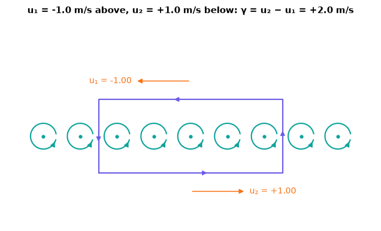

```python
fig, ax = plt.subplots(figsize=(6, 3.4))                              # the Fig. 5.16 analogue
u1, u2, gm = sheet_circuit(ax, ds=1.0, dn=0.4, n_filaments=9, gamma=2.0)   # counterclockwise filaments, γ = 2 m/s
ax.set_title(f"u₁ = {u1:+.1f} m/s above, u₂ = {u2:+.1f} m/s below: γ = u₂ − u₁ = {gm:+.1f} m/s", fontsize=10)
plt.show()
```

**What you see.** (Note `N60`, Fig. 5.16 analogue.) A row of teal (counterclockwise) filaments on a line, a purple rectangle ds × dn round a piece of it with arrows walking it counterclockwise, and orange velocity arrows: leftward above, rightward below.

**How to read it.** Walking the box counterclockwise: +u₂ ds along the bottom, −u₁ ds along the top, and the short sides (each just v·dn, since v is continuous) shrink away as the box is flattened, dn → 0 — D23. The title's numbers are the sheet's own velocities ∓γ/2.

**What would change if…** …clockwise filaments (γ < 0): the orange arrows swap, u₂ − u₁ becomes negative — the caption's convention would call it positive.

#### ✏️ Tiny example: a row of 10 filaments, then 100

γ = 2 m/s on a sheet 1 m long, probe at x = 0.

1. N = 10: each filament has Γ = γ × 0.1 = 0.2 m²/s; at y = 5 cm the sum gives −0.854 m/s (the continuous finite sheet: −0.937 m/s).
2. N = 100 (Γ = 0.02 m²/s each): −0.936551 m/s, equal to the continuous value to 2×10⁻⁶.
3. Just above the middle of the continuous sheet: $-\gamma/2$ = −1 m/s; just below +1 m/s; jump u₂ − u₁ = 2 m/s = γ ✓.
4. Far above a finite sheet the velocity fades (the sheet looks like a single vortex of circulation γL = 2 m²/s).

```python
print(ch05.vortex_sheet_strength(-1.0, 1.0), ch05.vortex_sheet_strength(-1.0, 1.0, convention="caption"))   # 2.0 (text), −2.0 (caption)
for N in (10, 100):                                                  # discrete rows of N filaments on [−0.5, 0.5] m
    print(N, ch05.discrete_sheet_u(0.0, 0.05, 2.0, N))                # u at (0, 5 cm) [m/s]
print(ch05.continuous_sheet_velocity(0.0, 0.05, 2.0), ch05.continuous_sheet_velocity(0.0, 1e-6, 2.0), ch05.continuous_sheet_velocity(0.0, -1e-6, 2.0))   # the continuous sheet
c = ch05.discrete_sheet_convergence(2.0)                             # L1 error of u(y) for N = 10, 100, 1000
print([f"{e:.5g}" for e in c["l1_error"]], f"observed order in 1/N: {observed_order(1/np.array(c['N']), c['l1_error']):.2f}")
```

```
2.0 -2.0
10 -0.8539065809775443
100 -0.9365510451091171
(-0.936548965138893, 0.0) (-0.9999987267604554, 0.0) (0.9999987267604554, 0.0)
```

```
['0.043968', '0.0044131', '0.00044128'] observed order in 1/N: 1.00
```

**What does the code above do?**

1. Both sign conventions: the text's u₂ − u₁ = +2 m/s, the caption's u₁ − u₂ = −2 m/s.
2. The discrete row at one height: −0.853907 (N = 10), −0.936551 m/s (N = 100).
3. The continuous finite sheet: −0.936549 m/s at 5 cm; ∓1.000 m/s (= ∓γ/2) just above and below the middle.
4. The L1 error of the discrete profile falls as 1/N: 0.04397, 0.004413, 0.0004413 — order 1.00.

**From scratch — a hundred line vortices, one line of numpy:**

```python
N, L, g = 100, 1.0, 2.0                                              # filaments, sheet length [m], γ [m/s]
xs = (np.arange(N) + 0.5)*L/N - L/2                                  # filament positions (cell midpoints) [m]
y = 0.05                                                             # probe height [m]
u = np.sum(g*L/N/(2*np.pi)*(-y)/(xs**2 + y**2))                      # Σ (Γ_j/2π)(−(y − 0))/|r|²: the x-velocity at (0, y)
print(u)                                                             # −0.936551 m/s
assert np.allclose(u, ch05.vortex_sheet_velocity(np.array([0.0, 0.05]), np.array([xs, 0*xs]), 2.0, L/N)[0], rtol=1e-12)   # = the library
```

```
-0.9365510451091174
```

```python
yq = np.linspace(-0.2, 0.2, 401)                                     # heights across the sheet [m]
ucont = ch05.continuous_sheet_velocity(0.0, yq, 2.0)[0]              # the continuous finite sheet [m/s]


def row(N):                                                          # number of filaments → curves
    return {"row of N filaments": (yq, ch05.discrete_sheet_u(0.0, yq, 2.0, int(N))), "continuous sheet": (yq, ucont)}  # the discrete row and the continuous sheet


Ns = np.unique(np.geomspace(4, 1000, 12 if not FAST else 6).astype(int))   # log-spaced N
fig = slider_figure(row, "N", Ns, unit="filaments", xlabel="y [m]", ylabel="u(0, y) [m/s]",         # precompute every slider position
                    title="From a row of vortices to a velocity jump (γ = 2 m/s)")                  # the message of the figure
recolor(fig, {"row of N filaments": COLORS["teal"], "continuous sheet": COLORS["ink"]}, dashes={"continuous sheet": "dash"})  # house colours by trace name
fig.show()                                                                                          # draw it (works on the web page too)
```

[interactive chart not shown]

**What you see.** For small N a wiggly teal profile (each filament's own swirl shows); as N grows it sharpens into a clean step from +1 m/s below to −1 m/s above, on top of the black dashed continuous sheet.

**How to read it.** The jump across the sheet is its strength γ = 2 m/s; within about one filament spacing of the row the discreteness shows, beyond it the row is a sheet. Far from this 1 m sheet the speed falls off, as for a single vortex of circulation γL.

**What would change if…** …γ doubled: the step doubles; the convergence with N is unchanged.

**A sheet rolls up.** A periodic sheet (period 1 m, γ = 1 m/s) of 150 point vortices with a small ripple (1 cm), each vortex moved by all the others. The kernel is smoothed over a length δ = 0.05 m (Krasny's method: $\lvert\mathbf r\rvert^2\to\lvert\mathbf r\rvert^2+\delta^2$ in the periodic kernel), which stands in for a finite sheet thickness. ⚠️ A **qualitative model**: the smoothing sets the size of the spiral's inner turns; the ripple's growth into a spiral is the robust result.

```python
nf = 30 if not FAST else 16                                          # frames
ro = ch05.sheet_rollup(N=150 if not FAST else 100, gamma=1.0, amplitude=0.01, delta=0.05, t_eval=np.linspace(0, 2.0, nf))   # (T, N) positions
with plt.rc_context(ANIM_RC):                                         # light settings for fast frames
    fig, ax = plt.subplots(figsize=(7, 3.6), dpi=80)
fig.subplots_adjust(left=0.1, right=0.97, bottom=0.14, top=0.88)     # fixed margins
(ln,) = ax.plot([], [], color=COLORS["teal"], lw=1.5)                 # the sheet (a line through the vortices)
(pt,) = ax.plot([], [], "o", color=COLORS["teal"], ms=2)              # the vortices
ax.set_xlim(-0.05, 1.05); ax.set_ylim(-0.25, 0.25); ax.set_aspect("equal"); ax.set_xlabel("x [m]"); ax.set_ylabel("y [m]")
Gtot = ro["Gamma_each"]*ro["N"]                                      # total circulation per period [m²/s]


def update(i):                                                       # draw frame i
    ln.set_data(ro["x"][i], ro["y"][i]); pt.set_data(ro["x"][i], ro["y"][i])
    ax.set_title(f"t = {ro['t'][i]:.2f} s, total circulation per period {Gtot:.3f} m²/s", fontsize=10)
    return ln, pt


with plt.rc_context(ANIM_RC):                                         # render the frames with the light settings
    show_animation(animate(update, frames=nf, fig=fig, interval=150), player="video")   # smooth movie
```

[video not shown]

**What you see.** The small ripple steepens, the vortices bunch at one point of each period and the sheet winds into a spiral (a cat's eye — a closed eddy, shaped like an eye, around each rolled-up lump); the total circulation in the title does not change.

**How to read it.** The sheet's own induced velocity carries its vortices toward the places where they are already crowded — the Kelvin–Helmholtz instability (Ch. 11). The smoothing δ only stands in for a finite thickness.

**What would change if…** …a smaller δ: the spiral winds tighter and the computation needs more points.

#### 🎮 Interactive: What is a velocity jump made of?

**Why interactive rather than a static figure:** setting the number of filaments and watching u(y) sharpen into a jump whose size is the sheet's strength, then rippling the sheet and pressing play to watch it roll up, links the jump, the vortex row and the instability — which needs motion.

**What to try:**

- N = 10 → 1000: the profile becomes a step of height γ.
- Drag the circuit's height: its circulation is γ ds once it spans the sheet.
- Roll-up mode, ▶: the ripple winds into cat's eyes.
- Switch to the caption's convention: only the sign changes.

```python
show_viz("ch05", "vortex_sheet_rollup")   # full-width explainer; ⤢ Full screen for more room
```

🎮 Interactive 9/9 What is a velocity jump made of? Open alone ↗

[interactive chart not shown]

**What would change if…** …the sheet were a wall? A no-slip wall with a stream above it is a vortex sheet stuck to the wall — its strength the wall slip it cancels. Viscosity then spreads it into a boundary layer (Ch. 9).

*↪ S01 · 📝 Exercises 5.1–5.20 in the book: practise on them. We have written out, in our own words, the results the text leaves to Exercises 5.4 (the line vortex's zero net viscous force, D03), 5.5 (the lock exchange, D07), 5.9 (the Green's function, D10), 5.10 (Kelvin in a rotating frame, D19), 5.12 (Burgers' vortex, D18) and 5.18 (the centre of vorticity, D21), and stated 5.6 (N22) and 5.11 (N23); 5.7–5.8 (Vazsonyi and Crocco) return with compressible flow in Ch. 15.*

*↪ S02 · 📚 Literature: Lighthill (1986) for the knife-blade pair, Sommerfeld (1964) for Helmholtz's first theorem and leap-frogging rings; for more, Saffman's *Vortex Dynamics*, and Pedlosky for the geophysical side (Ch. 13).*

## ✅ What should have clicked

- **C01** A vortex tube has one strength along its whole length, $\int_V\nabla\cdot\boldsymbol\omega\,dV=-\Gamma_{\text{lower end}}+\Gamma_{\text{upper end}}=0$ *(5.4)*: it can thin and spin faster but never end in the fluid.
- **C02** Pressure falls toward every vortex's centre to turn its fluid: $p-p_o=\tfrac18\rho\omega^2r^2-\rho gz$ *(5.6)* makes a bowl, $p-p_\infty=-\rho\Gamma^2/8\pi^2r^2-\rho gz$ *(5.7)* a funnel; the irrotational vortex is sheared but feels no net viscous force.
- **C03** Round a material loop in an ideal, barotropic, conservatively forced fluid seen from an inertial frame, $D\Gamma/Dt=0$ *(5.8)*; each broken hypothesis is a source of vorticity.
- **C04** Where isopycnals cross isobars, pressure pushes through the centre while weight hangs off it: the spin-up is $\frac1{\rho^2}\nabla\rho\times\nabla p$ *(5.28)*.
- **C05** Vortex lines move with the fluid, and tubes keep their strength (Helmholtz) — under Kelvin's four restrictions.
- **C06** $\frac{D\boldsymbol\omega}{Dt}=(\boldsymbol\omega\cdot\nabla)\mathbf u+\nu\nabla^2\boldsymbol\omega$ *(5.13)*: vorticity is carried, stretched and tilted, and diffused — never made by pressure in a uniform fluid.
- **C07** Vorticity decides velocity: $\mathbf u=\frac1{4\pi}\int\frac{\boldsymbol\omega\times(\mathbf x-\mathbf x')}{\lvert\mathbf x-\mathbf x'\rvert^3}d^3x'$ *(5.16)* — with +1/(4π) in the Green's-function form (5.14), $\mathbf u(\mathbf x,t)=+\frac1{4\pi}\int_{V'}\frac{\nabla'\times\boldsymbol\omega(\mathbf x',t)}{\lvert\mathbf x-\mathbf x'\rvert}d^3x'\ \ (\text{sign corrected; the book prints }-\tfrac1{4\pi})$.
- **C08** A thin filament's pieces push as $d\mathbf u=\frac{\Gamma\,dl}{4\pi}\mathbf e_\omega\times\frac{\mathbf x-\mathbf x'}{\lvert\mathbf x-\mathbf x'\rvert^3}$ *(5.17)*; an infinite line gives Γ/2πd back.
- **C09** On a rotating planet with density contrasts, $\frac{D\boldsymbol\omega}{Dt}=(\boldsymbol\omega+2\boldsymbol\Omega)\cdot\nabla\mathbf u+\frac1{\rho^2}\nabla\rho\times\nabla p+\nu\nabla^2\boldsymbol\omega$ *(5.30)*.
- **C10** Stretching a vortex line spins it up, tilting turns it, $\frac{D\omega_s}{Dt}=\omega\frac{\partial u_s}{\partial s}$ … (5.32), $\frac{D\omega_s}{Dt}=\omega\frac{\partial u_s}{\partial s},\ \frac{D\omega_n}{Dt}=\omega\frac{\partial u_n}{\partial s},\ \frac{D\omega_m}{Dt}=\omega\frac{\partial u_m}{\partial s}$ — neither happens in 2-D; Burgers' vortex balances stretching against diffusion.
- **C11** The absolute circulation is conserved, $D\Gamma_a/Dt=0$ *(5.33)*, so a column keeps (ζ + f)/h: squashed columns turn anticyclonic, stretched ones cyclonic.
- **C12** Vortices are moved only by each other: like ones orbit their centre of vorticity at $(\Gamma_1+\Gamma_2)/2\pi h^2$, opposite ones march at $\Gamma/2\pi h$.
- **C13** A wall is a mirror vortex of opposite sign: a vortex slides along it at $\Gamma/4\pi h$; a ring widens and slows near it.
- **C14** A velocity jump is a vortex sheet whose strength is the jump, $\gamma=u_2-u_1$; left alone, it rolls up.

**What later chapters build on**

- Ch. 6: irrotational flow stays irrotational (Kelvin); images for cylinders.
- Ch. 8: vortex decay and the flow round a rotating cylinder.
- Ch. 10: vorticity–stream-function methods and vortex methods (Biot–Savart).
- Ch. 11: Kelvin–Helmholtz roll-up of a vortex sheet.
- Ch. 12: vortex stretching and the cascade; Burgers' vortex.
- Ch. 13: the rotating vorticity equation $\frac{D\boldsymbol\omega}{Dt}=(\boldsymbol\omega+2\boldsymbol\Omega)\cdot\nabla\mathbf u+\frac{\nabla\rho\times\nabla p}{\rho^2}+\nu\nabla^2\boldsymbol\omega$ *(5.30)*, absolute circulation $D\Gamma_a/Dt=0$ *(5.33)*, $(\zeta+f)/h$ → potential vorticity, Rossby waves, fronts, baroclinic instability.
- Ch. 14: lifting line, trailing vortices, induced drag, ground effect.

**Not taught here (and where to find it)**

- Vazsonyi and Crocco equations (Exercises 5.7–5.8) → Ch. 15.
- Vortex reconnection (named only) → Ch. 12.
- The viscous rotating-cylinder solution → Ch. 8.

← All chapters

← PreviousNext →

Code and explanations: shammun/fluidpy (MIT). The book is not reproduced here; equations are cited by number.